# Ch. 7 Gravity Waves — fluidpy

← All chapters🎮 All explainers

← PreviousNext →

[▶ Open in Colab](https://colab.research.google.com/github/shammun/fluidpy/blob/main/notebooks/ch07_gravity_waves_colab.ipynb) ↓ Download .ipynb [View on GitHub](https://github.com/shammun/fluidpy/blob/main/notebooks/ch07_gravity_waves.ipynb)

## Interactive explainers in this chapter

🎮 1**Why do long waves outrun short ones?**Drag the wavelength and the depth: the crest marker in the tank, the dot on the c(λ) curve and the pressure profile move together between the shallow line √(gH) and the deep curve √(g/k).🎮 2**What does the water under a wave actually do?**Tracer particles loop under a moving surface: circles in deep water, flat ellipses in shallow water; switch to exact path lines and the loops open — the Stokes drift — while a fixed current meter still reads zero.🎮 3**Why is there a slowest ripple?**Sweep the wavelength over four decades and change the liquid: gravity's term g/k and surface tension's σk/ρ trade places, and between them the speed has a minimum — 23 cm/s at 1.7 cm on clean water.🎮 4**Which waves can live in a lake?**Two equal waves travelling in opposite directions add into a pattern with fixed nodes; walls keep only the patterns that fit, so a basin rings at periods set by its length, depth and mode number.🎮 5**Where does a wave's energy go?**Follow one crest while the envelope, and the energy, moves at the group speed dω/dk: half the crest speed in deep water, the same in shallow water, faster for capillary ripples; the chord and the tangent of ω(k) move with the dot.🎮 6**Why do waves arrive parallel to the beach?**Along a ray the frequency never changes while the wavelength shrinks with the depth, so the shoreward end of a crest slows and the crest swings round, over a beach, a ridge or an island.🎮 7**How high does the water jump — and why only upward?**A fast shallow stream becomes a slow deep one with the same momentum flux: the Froude-number slider sets the downstream depth from the momentum balance, and the energy bar shows the loss, which would turn into a forbidden gain for a subcritical stream.🎮 8**What is a baroclinic mode?**A light layer over deep heavy water rings in two ways: the barotropic mode (surface and interface in phase, fast) and the baroclinic mode (in antiphase, slow, the speed of the square root of g-prime H for long waves, almost invisible at the surface); with no free surface only the slow interfacial wave remains.🎮 9**Why does energy leave at right angles to the crests?**In a stratified fluid the frequency sets only the angle, omega = N cos theta: drag omega/N and the St Andrew's cross tilts, the crests slide across each beam while the energy runs along it, and in the wavenumber plane c_g stays perpendicular to c.

# Chapter 7 — Gravity Waves

*Fluid Mechanics, 5th edition — Pijush K. Kundu, Ira M. Cohen, David R. Dowling (2012).* This notebook teaches every new idea of the chapter with plain words, step-by-step mathematics, small worked examples, tested Python from the `fluidpy` package, figures, animations and interactive explainers. It does not reproduce the book's text or figures; every equation is shown in full together with its number, so you can follow along in your copy.

**The big idea in one paragraph**

Drop a stone in a pond, watch swell roll onto a beach, or feel a lake slosh after a storm: the water surface wants to be flat, gravity pulls every bump back, and the water's inertia overshoots — so the surface oscillates and the oscillation travels. This chapter turns that picture into one formula, the dispersion relation $\omega=\sqrt{gk\tanh kH}$ *(Eq. 7.28)*, and then reads everything off it: how fast crests move and why long waves outrun short ones, how the water under a wave goes round in orbits, how much energy a wave holds and at which speed that energy travels (the group velocity $c_g=d\omega/dk$ *(Eq. 7.67)*, not the crest speed), why waves turn toward a beach, what happens when they steepen into a hydraulic jump, and how a small density step or a continuous stratification carries slow, huge internal waves whose energy leaves at right angles to their crests, $\mathbf c_g\cdot\mathbf c=0$ *(Eq. 7.146)*. Ocean swell, tides, tsunamis, thermocline waves and the internal waves of the atmosphere are all here.

**Road map** — the new ideas of this chapter, in the order they build on each other:

1. §7.1 the sinusoidal wave and its vocabulary, $c=\omega/k=\lambda\nu$ *(7.4)* (C01)
2. §7.2 the linear free-surface problem, conditions moved to z = 0 (C02); the dispersion relation $\omega=\sqrt{gk\tanh kH}$ *(7.28)* (C03); phase speed, deep and shallow water (C04); particle orbits (C05); wave energy $E=\tfrac12\rho ga^2$ *(7.42)* and its flux (C06)
3. §7.3 capillary–gravity waves and the slowest ripple, $c_{min}=(4g\sigma/\rho)^{1/4}$ *(7.58)* (C07)
4. §7.4 standing waves and seiches (C08)
5. §7.5 group velocity $c_g=d\omega/dk$ *(7.67)* and $F=Ec_g$ *(7.71)* (C09); rays and refraction (C10)
6. §7.6 the hydraulic jump (and solitons) (C11); Stokes waves and Stokes drift $\bar u_L=a^2\omega ke^{2kz_0}$ *(7.85)* (C12)
7. §7.7 waves on a density interface, $\omega=\varepsilon\sqrt{gk}$ *(7.95)* (C13); barotropic and baroclinic modes, reduced gravity $c=\sqrt{g'H}$ *(7.116)* (C14)
8. §7.8 internal waves, $\omega=N\cos\theta$ *(7.139)* (C15); $\mathbf c\perp\mathbf c_g$, beams and $\mathbf F=\mathbf c_gE$ *(7.159)* (C16)

**What you should already know** (each is recapped where it is used):

- velocity potential and Laplace's equation (Ch. 6 §6.2)
- unsteady Bernoulli (Ch. 4 §4.9)
- kinematic and dynamic conditions at a moving surface, surface tension (Ch. 4 §4.10, Ch. 1 §1.6)
- control-volume momentum (Ch. 4 §4.4)
- path lines (Ch. 3 §3.2)
- Boussinesq equations and the buoyancy frequency N (Ch. 4 §4.9, Ch. 1 §1.10)
- complex exponentials (Ch. 1, Ch. 6)

## 🎮 Interactive explainers in this chapter

| # | Explainer | What it makes clear |
| --- | --- | --- |
| 1 | **Why do long waves outrun short ones?** | C03 C04: ω(k), c(λ), the deep and shallow limits and the pressure under a wave on one clock |
| 2 | **What does the water under a wave actually do?** | C05 C12: orbits shrink with depth, circles become flat ellipses, and at finite amplitude they fail to close — Stokes drift |
| 3 | **Why is there a slowest ripple?** | C07: gravity for long waves, surface tension for short ones, a minimum speed of about 23 cm/s in between |
| 4 | **Which waves can live in a lake?** | C08: two opposite waves make fixed nodes; the walls pick the periods |
| 5 | **Where does a wave's energy go?** | C09: crests move at c, the envelope and the energy at c_g = dω/dk |
| 6 | **Why do waves arrive parallel to the beach?** | C10: frequency is fixed along a ray, the wavelength shrinks with depth, the crest swings round |
| 7 | **How high does the water jump?** | C11: momentum sets the height, energy sets the direction |
| 8 | **What is a baroclinic mode?** | C13 C14: a layer over deep water rings in two ways — surface and interface in phase, or in antiphase and slow |
| 9 | **Why does energy leave at right angles to the crests?** | C15 C16: ω = N cos θ, c ⟂ c_g, the St Andrew's cross |

Each one opens right where its idea is taught and fills the window (no scrolling). Start with the **Walkthrough**, then **Explore** with the sliders and presets, read **Explain** (every number worked out with your settings, and what it means), step through the **Derivation** where there is one, read the **Equations** and the **Code**, and finish with **Check yourself**. On the web page they are full-window; in Colab and Jupyter they appear in the cell output (use ⤢ *Full screen* or *Open in new tab* for more room).

## ⚙️ Setup — run this cell first

It works in three places without changes:

- **Google Colab** — clones the public repository into `/content/fluidpy` (the `fluidpy` package, its tests and the interactive explainers) and installs the one package Colab lacks (`pint`). No GPU is needed.
- **Jupyter / VS Code on your computer** — finds the repository root (the folder with `book.yaml`) and imports from it.
- **The published web page** — already executed; nothing to run.

```python
# ── Setup: find (or fetch) the fluidpy repository, then load the house style ─────────────────────────────
import os, sys, subprocess, pathlib                     # standard library only, so this cell never fails on imports

IN_COLAB = "google.colab" in sys.modules                 # True when this notebook runs inside Google Colab
REPO_URL = "https://github.com/shammun/fluidpy.git"               # the public repository with the fluidpy package

if IN_COLAB:
    ROOT = pathlib.Path("/content/fluidpy")              # where the repository is cloned on Colab
    if not ROOT.exists():                                 # first run in this Colab session: clone it
        subprocess.run(["git", "clone", "--depth", "1", REPO_URL, str(ROOT)], check=True)
    else:                                                 # later runs: fetch the newest version
        subprocess.run(["git", "-C", str(ROOT), "pull", "--ff-only", "-q"], check=False)
    subprocess.run([sys.executable, "-m", "pip", "install", "-q", "-r", str(ROOT / "requirements-colab.txt")], check=True)
else:
    ROOT = pathlib.Path.cwd().resolve()                   # start where Jupyter was launched …
    while not (ROOT / "book.yaml").exists() and ROOT != ROOT.parent:
        ROOT = ROOT.parent                                # … and walk up until we find the repository root

os.chdir(ROOT)                                            # relative paths (outputs/, viz/) now resolve from the root
if str(ROOT) not in sys.path:
    sys.path.insert(0, str(ROOT))                         # make `import fluidpy` work

from fluidpy.core.style import setup_notebook            # matplotlib + plotly style shared with the explainers
from fluidpy.core.embed import show_viz                  # shows an interactive explainer in the notebook
from fluidpy.core.anim import show_animation             # plays a matplotlib animation inline
FAST = setup_notebook()                                   # FAST=True (env FLUIDPY_FAST=1) shrinks grids for quick runs
print(f"IN_COLAB = {IN_COLAB} | repository root: {ROOT} | FAST = {FAST}")
```

```
IN_COLAB = False | repository root: C:\Users\sislam27\Work\Climate Dynamics PHD\Fluid Dynamics | FAST = False
```

```python
import numpy as np                                       # arrays and maths (Ch. 1 primer P03)
import sympy as sp                                       # symbolic algebra (Ch. 1 primer P40)
import matplotlib.pyplot as plt                          # static figures (Ch. 1 primer P01)
import plotly.graph_objects as go                        # extra plotly traces for page-surviving figures (Ch. 1 P41)
import warnings                                          # to catch (and show) one deliberate physics warning
from fluidpy import ch07_gravity_waves as ch07           # the tested chapter-7 module; it re-exports core.waves
from fluidpy.core import waves as W                      # the new wave toolkit: dispersion relations, packets, rays
from fluidpy import ch01_introduction as ch01            # Ch. 1: surface tension of water (IAPWS)
from fluidpy import ch03_kinematics as ch03              # Ch. 3: path lines (Example 3.1)
from fluidpy import ch04_conservation_laws as ch04       # Ch. 4: the wave test field and the bore speed
from fluidpy import ch05_vorticity_dynamics as ch05      # Ch. 5: vortex sheets
from fluidpy.core import interfaces, bernoulli, potential, streamfunction, similarity, stratification   # earlier tools
from fluidpy.core.interact import slider_figure, animate_figure, live   # plotly sliders (P17), time players, widgets (P47)
from fluidpy.core.anim import animate, ffmpeg_path       # matplotlib animations (P16); show_animation came with setup
from fluidpy.core.style import COLORS, savefig           # the house palette and a helper that saves PNGs to outputs/ch07
from tools.convergence import observed_order             # slope of log(error) vs log(step) (P13)
from scripts.ch07_drawings import tank, wave_surface, orbit_ghosts, cv_box, beam_labels, two_layer_sketch, NAVY  # drawing only
ffmpeg_path()                                            # find ffmpeg once, for the MP4 animations
G = ch07.G_BOOK                                          # g = 9.81 m/s², the book's value used by every ch07 function
plt.rcParams["contour.negative_linestyle"] = "solid"     # negative ψ levels are streamlines too: draw them solid
import logging                                           # Python's message system (matplotlib reports font fallbacks through it)
logging.getLogger("matplotlib.font_manager").setLevel(logging.ERROR)   # hide harmless "font weight not found" notes


def recolor(fig, colors, dashes=None):                   # give plotly traces the notebook's colours by trace name
    for tr in fig.data:                                  # every trace of every slider step
        if tr.name in colors:                            # a name we assigned a colour to
            tr.line.color = colors[tr.name]              # same colour meaning as in the matplotlib figures
            tr.marker.color = colors[tr.name]            # markers too (for "markers" traces)
        if dashes and tr.name in dashes:                 # optional dash pattern ("dash", "dot")
            tr.line.dash = dashes[tr.name]
    return fig                                           # the same figure, restyled


def logaxes(fig, x=None, y=None):                        # switch plotly axes to log scale with fixed ranges [lo, hi]
    if x is not None:                                    # x range in data units
        fig.update_xaxes(type="log", range=[np.log10(x[0]), np.log10(x[1])])   # plotly wants log10 of the limits
    if y is not None:                                    # y range in data units
        fig.update_yaxes(type="log", range=[np.log10(y[0]), np.log10(y[1])])
    return fig                                           # the same figure


print(len([n for n in dir(ch07) if not n.startswith("_")]), "public names in fluidpy.ch07_gravity_waves; g =", G, "m/s²")
```

```
132 public names in fluidpy.ch07_gravity_waves; g = 9.81 m/s²
```

**What does the code above do?**

1. Numerical, symbolic and plotting libraries (all primed in Ch. 1).
2. `ch07` is the chapter module. It **re-exports the new wave toolkit `core.waves`**, so `ch07.omega_gravity` and `W.omega_gravity` are the same function; every function cites its § and equation and is tested in `tests/test_ch07.py`.
3. Earlier chapters' modules are used in the recaps and for parity checks (the Ch. 4 wave test field, the Ch. 5 vortex sheet, the Ch. 1 surface tension, the Ch. 3 path line).
4. `scripts/ch07_drawings.py` only draws (tank outlines, surfaces, orbit ghosts, the jump's control volume, beam labels, the two-layer sketch); it computes no physics.
5. `G = 9.81` m/s²: every ch07 function uses the book's g (Ch. 1's `G0 = 9.80665` appears only where we call Ch. 1–4 functions, and we pass g explicitly there).
6. `recolor` and `logaxes` only restyle plotly figures.

### ⚠️ Conventions in this chapter (read once; each is repeated where it bites)

| Symbol | Meaning here | Before (and where it bites) |
| --- | --- | --- |
| ω | angular **frequency** of a wave [rad/s] | the vorticity in Ch. 2–6 |
| η(x, t) | **elevation** of the free surface above z = 0 [m] | Ch. 4's $\frac{D\eta}{Dt}=0$ *(4.91)* used η for the surface *function*; here that function is f = z − η |
| z, H | z **up**, still surface z = 0, flat bottom z = −H; H = ∞ means deep water (`H=np.inf` in the code) | §7.7's two-layer problem: origin at the free surface, interface at z = −H |
| p, p′ | p is **gauge** pressure; the wave part $p'\equiv p+\rho gz$ *(7.30)* in §7.2 | in §7.8, $p=\bar p(z)+p',\ \rho=\bar\rho(z)+\rho'$ *(7.124)*: p′ is measured from the stratified background |
| ζ | a particle's vertical excursion (§7.2, §7.6, §7.8) | the **interface** displacement in §7.7 |
| θ | the local phase θ(x, t) in $\eta=a(x,t)\cos[\theta(x,t)]$ *(7.72)* | the angle of **K** above the horizontal in $\omega=N\cos\theta$ *(7.139)* |
| g′ | the book's reduced gravity $g'=g\big(\frac{\rho_2-\rho_1}{\rho_2}\big)$ *(7.117)* (lower density below the line) | Ch. 4's version divides by ρ₁: 0.2 % apart in the ocean, 25 % for oil over water |
| E, F | surface and interface waves: E per unit **area** [J/m²], F per metre of **crest** [W/m] | internal waves (§7.8): E per unit **volume** [J/m³], F per unit area [W/m²] |
| g | 9.81 m/s² in every ch07 function (`ch07.G_BOOK`) | Ch. 1's `G0` = 9.80665 m/s² elsewhere in `fluidpy.core` |

We compute with the book's conventions and name the other one wherever it differs.

**Colours** (one meaning each, also in the explainers): free surface **blue** · particles and orbits **teal** · phase (crests, c) **orange** · group and energy (envelope, $c_g$, F) **purple** · pressure **amber** · surface tension **rose** · lower (denser) layer **navy** · deep-water limit grey dashed · shallow-water limit grey dotted · residuals black · a printed slip shown as a ghost **rose dashed**.

**Book slips we correct in this notebook** (each is explained where it is used):

[output not shown]

> 🔁 **Tools from earlier chapters used in this one** (one line each where first used; the full primers are in `knowledge/primers.md`): partial derivative (P25), first-order Taylor (P26) and its multivariable form (P98), definite integral (P27), `solve_ivp` (P31, P94), RK4 by hand (P95), sympy (P40) and `expand`/`series` (P117), the linear second-order ODE and the $e^{\lambda z}$ trial (P44), Euler's formula (P45), the chain rule (P49, P91), orders of smallness (P68), level sets and the normal (P75), `np.meshgrid` (P76), broadcasting (P77), contour and quiver plots (P78), eigenvalues — the idea only (P80), the complex conjugate (P81), `quad`/`dblquad` (P87), parametric curves (P92), `np.expm1` and cancellation (P107), `brentq` (P108), momentum flux (P114), Schwarz's theorem (P121), power of a force (P127), reduced gravity (P131), moving level sets (P132), Fourier modes and the FFT (P142), the Dirac delta (P149), integrals of sines and cosines over a period (P151), the complex plane in numpy (P153), sympy for complex algebra (P158), Vieta (P71), `animate` (P16), `slider_figure` (P17), `show_viz` (P18), live widgets (P47), `assert np.allclose` (P15), log–log slopes (P13). New primers of this chapter: P165–P178.

## 7.1 Introduction

**What is this section about?** Before any fluid mechanics, the words: a wave's amplitude, wavelength, period, frequency, wavenumber and phase, the speed at which a crest moves, the wavenumber vector of a wave travelling in any direction, and what an observer on a current measures. Everything later in the chapter is written in these words.

### 🧩 The sinusoidal travelling wave and its vocabulary `C01`

*The question:* What exactly moves at "the wave speed" — and how do λ, T, k, ω and c fit together?

*In one line:* $\eta(x,t)=a\cos\Big[\frac{2\pi}{\lambda}(x-ct)\Big]$ *(7.1)* · $c=\omega/k=\lambda\nu$ *(7.4)*

#### The problem in plain words

Stand on a pier and watch swell arrive: a buoy tied below you rises and falls every eight seconds, but it does not travel toward the beach. What travels is the *shape* — the crest. We want exact words for that shape and one clean definition of how fast it moves, because every later result (how fast a tsunami crosses an ocean, how fast its energy arrives) is a statement about those speeds.

📝 **Note.** **Three families of waves** `N01` — Waves on an interface are restored by gravity and surface tension (this chapter's first half); internal waves inside a stratified fluid by buoyancy (its end); compression waves by compressibility (Ch. 15). Water waves are neither purely longitudinal nor transverse: the water goes round in loops (C05). The whole chapter assumes small amplitude (so everything is linear) and waves fast compared with the Earth's rotation (rotation joins in Ch. 13: Poincaré, Kelvin and Rossby waves).

#### The idea

```
snapshot at t:       η(x) = a cos(kx − ωt)      crest where the phase kx − ωt = 0, 2π, 4π, …
a moment Δt later:   the same cosine, slid right by c·Δt
phase fixed:  kx − ωt = const  ⇒  x = (ω/k)t + const  ⇒  c = ω/k
```

| symbol | name | unit | from the others |
| --- | --- | --- | --- |
| a | amplitude (crest height above the still level) | m | — |
| λ | wavelength (crest to crest) | m | λ = 2π/k |
| k | wavenumber (radians of phase per metre) | rad/m | k = 2π/λ |
| T | period (crest to crest at a fixed point) | s | T = λ/c |
| ν | cyclic frequency | Hz | ν = 1/T |
| ω | angular frequency (radians of phase per second) | rad/s | ω = 2πν |
| c | phase speed (speed of a crest) | m/s | c = ω/k = λν |

In these letters the wave is $\eta(x,t)=a\cos\big[\frac{2\pi}{\lambda}(x-ct)\big]$ *(7.1)*. **A wave is a moving phase, not moving water.**

> ⚠️ **Common confusion:** in Ch. 3–6 ω was the vorticity (a spin rate, 1/s). From here on ω is the wave's angular frequency (rad/s): how many radians of phase pass a fixed point per second, $\omega=2\pi/T$.

> 📎 **Primer — phase of a wave.** `P165` · The phase is the argument of the cosine, kx − ωt, measured in radians: 0 at a crest, π at a trough, 2π at the next crest. Radians per metre (k) and radians per second (ω) are the natural units; cycles (1/λ, ν) differ by 2π. A point that keeps its phase fixed moves to the right when ω/k > 0.

```python
import numpy as np                                # numbers
k, w = 2*np.pi/100, 2*np.pi/8                     # λ = 100 m, T = 8 s → k [rad/m], ω [rad/s]
x = np.array([0.0, 25.0, 50.0])                   # three positions [m]
print(k*x - w*0.0, np.cos(k*x))                   # phases [0, 1.571, 3.142] rad → cos [1, 0, −1]
```

```
[0.     1.5708 3.1416] [ 1. -0. -1.]
```

📝 **Note.** **The same wave in k and ω** `N03` — With $k=2\pi/\lambda$ and $\omega=2\pi/T$ this is $\eta(x,t)=a\cos\big[\frac{2\pi}{\lambda}(x-ct)\big]$ *(7.1)* with $c=\omega/k$. Number: λ = 100 m, T = 8 s → k = 0.0628 rad/m, ω = 0.785 rad/s, c = 12.5 m/s.

$$ \eta(x,t)=a\cos[kx-\omega t] \qquad \text{(7.2)} $$

#### 🧮 Derivation — Crest speed $c=\omega/k=\lambda\nu$ from the crest condition `D01` (Eq. 7.4: $c=\omega/k=\lambda\nu$)

**What we want to show.** Show that every crest of $\eta=a\cos(kx-\omega t)$ (7.2) moves at the same speed ω/k, and write that speed as wavelength × frequency.

**Assumptions.** A single sinusoid of constant k and ω (step 2).

**The plan.**

1. Say where a crest is.
2. Turn that into an equation for its position.
3. Follow it for a time Δt.

**Tools we use** (each explained before this point): phase of a wave (P165) · cos θ = 1 only at θ = 2nπ · solving a linear equation.

**We start from**

$$ \eta(x,t)=a\cos(kx-\omega t)\ \text{(7.2)} $$

*In words:* a cosine surface whose phase changes in space and time.

**Step 1 of 5 — Say where η is largest.**

$$ \eta=a\iff\cos(kx-\omega t)=1 $$

- *Why we can do this:* A crest is the highest point of the surface; since a cosine never exceeds 1, η reaches its maximum a exactly where the cosine equals 1.
- *In words:* crests sit where the cosine peaks.

**Step 2 of 5 — Write the crest's phase.**

$$ kx_{crest}-\omega t=2n\pi\ \text{(7.3)} $$

- *Why we can do this:* cos θ = 1 exactly when θ is a whole multiple of 2π; the integer n labels which crest we follow.
- *In words:* each crest keeps its own fixed phase 2nπ.

**Step 3 of 5 — Solve for the crest position.**

$$ x_{crest}=\frac{\omega}{k}t+\frac{2n\pi}{k} $$

- *Why we can do this:* A linear equation in x_crest: add ωt to both sides and divide by k, which is not zero for a wave.
- *In words:* crest n starts at 2nπ/k and moves steadily in time.

**Step 4 of 5 — Compare two times Δt apart.**

$$ \Delta x_{crest}=\frac{\omega}{k}\Delta t $$

- *Why we can do this:* Subtract the positions at t and t + Δt: the label term 2nπ/k cancels, so every crest moves the same distance.
- *In words:* in Δt every crest moves (ω/k)Δt.

**Step 5 of 5 — Divide by Δt and rewrite.**

$$ c=\frac{\omega}{k}=\frac{2\pi\nu}{2\pi/\lambda}=\lambda\nu\ \text{(7.4)} $$

- *Why we can do this:* Speed is distance over time; ω = 2πν and k = 2π/λ by definition, so the 2π cancel.
- *In words:* a crest moves one wavelength every period.

**Result**

$$ c=\omega/k=\lambda\nu $$

*In words:* the phase speed is the speed of any point of fixed phase.

**What it means.** c is a speed of pattern, not of water: the buoy under a crest does not travel. In a dispersive medium c depends on k, and the energy travels at a different speed (C09).

**Check it.** Units: (rad/s)/(rad/m) = m/s ✓. Numbers: λ = 100 m, T = 8 s → ω/k = 0.785/0.0628 = 12.5 m/s = λ/T ✓ (the from-scratch crest tracking of C01 gives 12.500 m/s).

> ⚠️ **Common confusion (traps in `D01`):** Mixing ν [Hz] and ω [rad/s] loses a 2π (c = λν, but also c = λω/2π). The label n does not change the speed.

📝 **Note.** **Where the crest condition and the speed sit** `N04, N05` — The crest condition $\frac{2\pi}{\lambda}(x_{crest}-ct)=2n\pi=kx_{crest}-\omega t$ *(7.3)* is D01's step 2; the integer n only labels which crest. The speed $c=\omega/k=\lambda\nu$ *(7.4)* is D01's result: a crest's Δx/Δt.

#### ✏️ Tiny example: a swell with λ = 100 m and T = 8 s

1. $k=2\pi/\lambda=6.2832/100=0.0628$ rad/m.
2. $\omega=2\pi/T=6.2832/8=0.785$ rad/s.
3. $\nu=1/T=0.125$ Hz.
4. $c=\omega/k=0.785/0.0628=12.5$ m/s — the same as $\lambda\nu=100\times0.125$.
5. In 2 s a crest moves $c\,\Delta t=25$ m: a quarter wavelength.

> 🔁 **Tools from earlier chapters used here** (see `knowledge/primers.md`)
- **Python dictionaries (fluidpy results)** — fluidpy returns several named results at once as a dictionary: `p["c"]` (Ch. 1 P23).
- **f-strings** — `f"{x:.3g} m/s"` puts a number with 3 significant figures into a sentence (Ch. 1 P04).
- **np.linspace and np.logspace** — evenly spaced numbers on a linear axis, or with a constant factor on a log axis (Ch. 1 P06).
- **matplotlib figures** — `fig, ax = plt.subplots()`, `ax.plot`, labels with units; every figure is followed by What you see / How to read it / What would change if (Ch. 1 P01).
- **assert np.allclose** — stops the notebook if two results differ beyond a tolerance — our proof that a from-scratch version matches the library (Ch. 1 P15).

```python
p = ch07.wave_parameters(lam=100.0, T=8.0)               # any consistent pair → all six descriptors, (7.1)–(7.4)
print({name: round(v, 5) for name, v in p.items()})      # k [rad/m], lam [m], omega [rad/s], T [s], nu [Hz], c [m/s]
t = np.array([0.0, 1.0, 2.0])                            # three times [s]
print("crest n = 0 at x =", ch07.crest_positions(t, p["k"], p["omega"], n=0), "m")   # (7.3) solved for x_crest
```

```
{'k': 0.06283, 'lam': 100.0, 'omega': 0.7854, 'T': 8.0, 'nu': 0.125, 'c': 12.5}
crest n = 0 at x = [ 0.  12.5 25. ] m
```

**What does the code above do?**

1. `wave_parameters` accepts any consistent pair (here λ and T) and returns all six quantities; it refuses an inconsistent or under-determined input.
2. `crest_positions` solves the crest condition $kx_{crest}-\omega t=2n\pi$ *(7.3)* for $x_{crest}$ at each time: the crest advances 12.5 m every second — c = 12.5 m/s.

**From scratch — track the crest on a fine grid.** `np.argmax` returns the index of the largest value, so `x[np.argmax(eta)]` is where the surface is highest; `np.polyfit(ts, xs, 1)[0]` is the slope of the best straight line through the points (ts, xs) — the crest's speed.

```python
x = np.linspace(-10, 110, 120001)                        # a 1 mm grid [m]
ts = np.array([0.0, 0.5, 1.0, 1.5, 2.0])                 # five times [s]
xs = []                                                   # the crest positions we find [m]
for t_ in ts:                                             # at each time …
    eta = W.sinusoid(x, t_, 1.0, p["k"], p["omega"])     # (7.2): η = a cos(kx − ωt) with a = 1 m
    xs.append(x[np.argmax(eta * (x < 50))])              # … the highest point left of 50 m: the crest that began at 0
slope = np.polyfit(ts, xs, 1)[0]                          # speed of the tracked crest [m/s]
print(f"tracked crest speed = {slope:.3f} m/s, ω/k = {p['c']:.3f} m/s")
assert np.allclose(slope, p["c"], rtol=1e-3)             # same numbers → the crest really moves at c = ω/k
```

```
tracked crest speed = 12.500 m/s, ω/k = 12.500 m/s
```

Tracking the highest point of the cosine on a 1 mm grid gives 12.500 m/s — the crest really moves at ω/k.

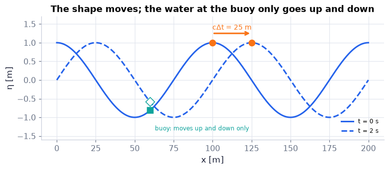

```python
lam, a, T = 100.0, 1.0, 8.0                               # the swell of the tiny example [m, m, s]
k, w = 2*np.pi/lam, 2*np.pi/T                             # k [rad/m], ω [rad/s]
x = np.linspace(0, 200, 801)                              # two wavelengths [m]
fig, ax = plt.subplots(figsize=(7, 3))                   # one panel
ax.plot(x, W.sinusoid(x, 0.0, a, k, w), color=COLORS["blue"], lw=2, label="t = 0 s")          # (7.2) at t = 0
ax.plot(x, W.sinusoid(x, 2.0, a, k, w), color=COLORS["blue"], lw=2, ls="--", label="t = 2 s")  # the same wave 2 s later
xc0, xc2 = ch07.crest_positions(0.0, k, w, 1), ch07.crest_positions(2.0, k, w, 1)   # crest n = 1 at both times [m]
ax.plot([xc0, xc2], [a, a], "o", color=COLORS["orange"], ms=8)                        # the tracked crest (orange)
ax.annotate("", xy=(xc2, 1.25), xytext=(xc0, 1.25), arrowprops=dict(arrowstyle="->", color=COLORS["orange"], lw=2))
ax.text(0.5*(xc0 + xc2), 1.35, "cΔt = 25 m", color=COLORS["orange"], ha="center", fontsize=9)
xb = 60.0                                                  # a buoy moored at x = 60 m
for tt, mk in ((0.0, "s"), (2.0, "D")):                    # its height at the two times
    ax.plot(xb, W.sinusoid(xb, tt, a, k, w), mk, color=COLORS["teal"], ms=8, mfc="white" if tt else COLORS["teal"])
ax.text(xb + 3, -1.35, "buoy: moves up and down only", color=COLORS["teal"], fontsize=8)
ax.set_xlabel("x [m]"); ax.set_ylabel("η [m]"); ax.set_ylim(-1.6, 1.7)   # axis labels with units
ax.set_title("The shape moves; the water at the buoy only goes up and down"); ax.legend(loc="lower right", fontsize=8)
savefig(fig, "ch07", "c01_travelling_wave"); plt.show()   # save the PNG to outputs/ch07, then draw
```

**What you see.** Two snapshots of the same cosine, the dashed one shifted right by 25 m; the orange crest moved along with it; the buoy (teal square at t = 0, open diamond at t = 2 s) changed height, not position.

**How to read it.** Measure the shift of any crest and divide by the time: $25\ \text{m}/2\ \text{s}=12.5$ m/s $=\omega/k$.

**What would change if…** …T were 16 s with the same λ: ω halves and the crest moves only 12.5 m in 2 s — half as fast ($c=\lambda/T$).

📝 **Note.** **Why sinusoids** `N02` — For linear waves any surface shape is a sum of sinusoids, $\eta=\sum_k\hat\eta_ke^{i(kx-\omega(k)t)}+\text{c.c.}$, and each one moves with its own ω(k) (our `W.linear_evolve` does the general case with the FFT). So one sinusoid is the building block.

> 🔁 **Tools from earlier chapters used here** (see `knowledge/primers.md`)
- **Fourier modes and the FFT** — on a periodic domain `np.fft.fft` splits a signal into modes $e^{ikx}$, ∂/∂x becomes multiplication by ik, and `np.fft.ifft` adds them back (Ch. 5 P142).

```python
L = 2*np.pi/0.02                                         # a periodic domain 314.16 m long [m]
x = np.linspace(0, L, 4096, endpoint=False)              # grid [m]
k1, k2 = 5*0.02, 20*0.02                                 # two deep-water modes that fit the domain [rad/m]
eta0 = np.cos(k1*x) + np.cos(k2*x)                       # the initial surface: a sum of two sinusoids [m]
eta1 = W.linear_evolve(eta0, x, 1.0, direction=+1, H=np.inf)   # every Fourier mode moved with its own ω(k) for 1 s
E0, E1 = np.fft.fft(eta0), np.fft.fft(eta1)              # the two spectra
for j, kk in ((5, k1), (20, k2)):                        # mode index j has k = j·2π/L
    shift = (np.angle(E0[j]) - np.angle(E1[j]))/kk       # phase lost by the mode / k = distance moved [m]
    print(f"k = {kk:.2f} rad/m: moved {shift:.2f} m in 1 s; deep-water c = √(g/k) = {np.sqrt(G/kk):.2f} m/s")
```

```
k = 0.10 rad/m: moved 9.90 m in 1 s; deep-water c = √(g/k) = 9.90 m/s
k = 0.40 rad/m: moved 4.95 m in 1 s; deep-water c = √(g/k) = 4.95 m/s
```

**What does the code above do?**

1. `linear_evolve` takes the FFT of η₀, multiplies each mode by $e^{-i\omega(k)t}$ (one-way, to +x) with the deep-water ω(k) $=\sqrt{gk}$ (derived in C03–C04; take it on trust for now), and adds the modes back with the inverse FFT.
2. The phase each mode lost, divided by its k, is how far it moved: the long mode (k = 0.1 rad/m) moves 9.90 m in 1 s, the short one (k = 0.4 rad/m) 4.95 m — the long one twice as fast. That is dispersion, explained in C04.

📝 **Note.** **Waves in any direction** `N06–N09` — $\eta=a\cos(kx+ly+mz-\omega t)=a\cos(\mathbf K\cdot\mathbf x-\omega t)$ *(7.5)* with the wavenumber vector $\mathbf K=(k,l,m)$ and $K^2=k^2+l^2+m^2$ *(7.6)*. Crests are the planes $\mathbf K\cdot\mathbf x-\omega t=2n\pi$, perpendicular to K and $\lambda=2\pi/K$ *(7.7)* apart along K; they advance along K at $\mathbf c=(\omega/K)\,\mathbf e_K,\ \mathbf e_K=\mathbf K/K$ *(7.8)* (met again in C16, where c and the energy velocity are perpendicular).

> 🔁 **Tools from earlier chapters used here** (see `knowledge/primers.md`)
- **dot product K·x** — $\mathbf K\cdot\mathbf x=kx+ly+mz$, the sum of the products of components (Ch. 2 §2.2).
- **level sets and the normal to a surface** — a surface where a function is constant has the function's gradient as its normal (Ch. 2 P75): here the gradient of K·x is K itself, so crests are perpendicular to K.

```python
K = np.array([1.0, 1.0])                                  # a wavenumber vector (k, l) [rad/m]
print("|K| =", np.hypot(*K), "rad/m;  λ = 2π/K =", 2*np.pi/np.hypot(*K), "m")   # (7.6), (7.7)
print("c =", ch07.phase_velocity_vector(K, 1.0), "m/s")  # (7.8) with ω = 1 rad/s: along K, size ω/K
print("trace speeds (ω/k, ω/l) =", ch07.trace_velocities(K, 1.0), "m/s")   # how fast crests cut each axis
```

```
|K| = 1.4142135623730951 rad/m;  λ = 2π/K = 4.442882938158366 m
c = [0.5 0.5] m/s
trace speeds (ω/k, ω/l) = (1.0, 1.0) m/s
```

> 🔁 **Tools from earlier chapters used here** (see `knowledge/primers.md`)
- **np.meshgrid and the grid layout** — `X, Y = np.meshgrid(x, y)` gives every (x, y) pair; rows run along y, columns along x (Ch. 2 P76).
- **contour and quiver plots** — `ax.contour(X, Y, F, levels=[…])` draws the lines where F takes the given values; `quiver` draws arrows (Ch. 2 P78).
- **numpy broadcasting** — an operation between arrays of compatible shapes acts at every point at once (Ch. 2 P77).

> 📎 **Primer — np.stack and np.c_.** `P179` · Two ways to glue arrays together. `np.stack([X, Y], axis=-1)` puts equal-shaped arrays side by side on a **new last axis**, so every grid point carries its (x, y) pair — the layout `plane_wave` expects for positions. `np.c_[a, b]` stacks 1-D arrays as **columns**: two points (x₀, y₀) and (x₁, y₁) given as the columns a and b become one row of x's and one row of y's, which is what `ax.plot(*…)` needs to draw the segment between them.

```python
import numpy as np                                        # arrays
X, Y = np.meshgrid([0, 1], [0, 1])                        # a 2 × 2 grid of x and y values
print(np.stack([X, Y], axis=-1).shape)                    # (2, 2, 2): the last axis holds (x, y) at each point
print(np.c_[[0, 0], [3, 4]])                              # columns (0,0) and (3,4) → rows [0 3] (the x's) and [0 4] (the y's)
```

```
(2, 2, 2)
[[0 3]
 [0 4]]
```

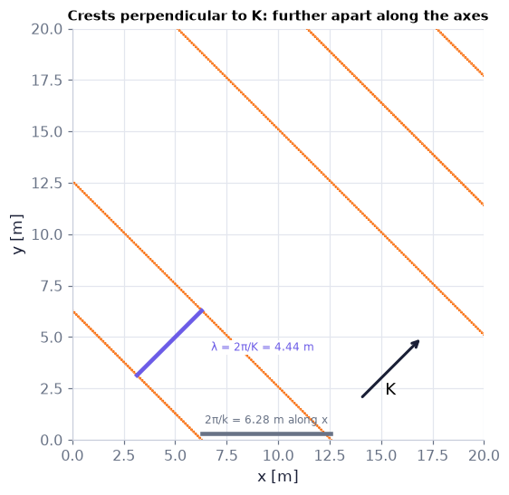

```python
xg = np.linspace(0, 20, 201)                              # a 20 m × 20 m patch [m]
XX, YY = np.meshgrid(xg, xg)                              # every (x, y) pair
K = np.array([1.0, 1.0])                                  # the wavenumber vector [rad/m]
eta = ch07.plane_wave(np.stack([XX, YY], axis=-1), K, 1.0, a=1.0, t=0.0)   # (7.5) at t = 0 (components on the last axis)
fig, ax = plt.subplots(figsize=(5, 5))                    # square panel so angles look right
ax.contour(XX, YY, eta, levels=[0.999], colors=[COLORS["orange"]], linewidths=1.5)   # crest lines η = a
ax.annotate("", xy=(17, 5), xytext=(14, 2), arrowprops=dict(arrowstyle="->", color=COLORS["ink"], lw=2))   # K direction
ax.text(15.2, 2.2, "K", fontsize=12)
lamK = 2*np.pi/np.hypot(*K)                               # spacing of crests along K [m]
ax.plot([2*np.pi, 4*np.pi], [0.3, 0.3], color=COLORS["muted"], lw=3)   # spacing along x: 2π/k = 6.28 m
ax.text(3*np.pi, 0.8, "2π/k = 6.28 m along x", ha="center", fontsize=8, color=COLORS["muted"])
c0 = np.array([np.pi, np.pi])                             # a point on a crest line (K·x = 2π)
ax.plot(*np.c_[c0, c0 + lamK*K/np.hypot(*K)], color=COLORS["accent"], lw=3)   # spacing along K: λ = 4.44 m
ax.text(c0[0] + 3.6, c0[1] + 1.2, f"λ = 2π/K = {lamK:.2f} m", color=COLORS["accent"], fontsize=8,
        bbox=dict(facecolor="white", edgecolor="none", pad=1))
ax.set_aspect("equal"); ax.set_xlabel("x [m]"); ax.set_ylabel("y [m]")
ax.set_title("Crests perpendicular to K: further apart along the axes", fontsize=10)
savefig(fig, "ch07", "c01_plane_wave"); plt.show()
```

**What you see.** Straight crest lines (orange) at 45°, $\lambda=2\pi/K=4.44$ m apart along K (purple bar) but 6.28 m apart along x (grey bar) — our remake of Fig. 7.1 `N167`.

**How to read it.** Along an axis the crests are further apart and pass a fixed point at the same rate ω, so they *seem* to move faster: $c_x=\omega/k=1.0$ m/s against $c=\omega/K=0.707$ m/s along K.

**What would change if…** …K turned to (1, 0): the crests stand perpendicular to x, $c_x=c$, and $c_y=\infty$ (the crest lines never cross the y-axis).

> ⚠️ **Common confusion:** `N10` the trace speeds $c_x=\omega/k$, $c_y=\omega/l$, $c_z=\omega/m$ are each ≥ $c=\omega/K$, so they are **not** the components of c (components would be smaller). Reciprocals do not add like components: $c_x\mathbf e_x+c_y\mathbf e_y\ne \mathbf c$ — its length is 1.41 m/s here against 0.71 m/s for c.

📝 **Note.** **A current shifts the frequency you see** `N11` — In water moving at uniform U the crests are carried along, so a fixed probe sees the observed frequency ω₀ below; ω is the intrinsic one, measured drifting with the water — one substitution $x'=x-Ut$ in the phase (the frames of Ch. 3 P96). A frozen pattern (ω = 0) swept past at U gives $\omega_0=Uk$. From here on every ω is intrinsic.

$$ \omega_0=\omega+\mathbf U\cdot\mathbf K \qquad \text{(7.9)} $$

> 🔁 **Tools from earlier chapters used here** (see `knowledge/primers.md`)
- **change of frame x′ = x − Ut** — two frames moving apart at constant U see velocities that differ by U (Galilean frames, Ch. 3 P96); writing the phase with x′ = x − Ut gives (7.9), $\omega_0=\omega+\mathbf U\cdot\mathbf K$.

```python
w = 2*np.pi/8; k = w**2/G                               # an 8 s deep-water swell: ω [rad/s], k = ω²/g [rad/m] (C04)
for U in (-1.0, 0.0, 1.0):                               # a current against, none, and with the swell [m/s]
    w0 = ch07.doppler_frequency(w, np.array([U, 0.0]), np.array([k, 0.0]))   # (7.9): ω₀ = ω + U·K
    print(f"U = {U:+.0f} m/s: ω₀ = {w0:.4f} rad/s, observed period {2*np.pi/w0:.2f} s")
```

```
U = -1 m/s: ω₀ = 0.7225 rad/s, observed period 8.70 s
U = +0 m/s: ω₀ = 0.7854 rad/s, observed period 8.00 s
U = +1 m/s: ω₀ = 0.8483 rad/s, observed period 7.41 s
```

**What does the code above do?**

The first line uses the deep-water rule $k=\omega^2/g$ (derived in C03–C04; take it on trust for now). Against a 1 m/s current the probe sees the 8 s swell as an 8.70 s wave, with the current as a 7.41 s wave. Ch. 13 uses exactly this for mountain waves and Rossby waves in a wind.

**What would change if…** …the medium itself set a rule between ω and k? For water it does — $\omega=\sqrt{gk\tanh kH}$ *(7.28)* — and that single rule makes long waves faster than short ones (C03–C04). The vocabulary stays; only the relation changes from wave to wave (capillary C07, interfacial C13, internal C15).

## 7.2 Linear Liquid-Surface Gravity Waves

**What is this section about?** The heart of the chapter. We set up the flow under small waves on a layer of depth H — Laplace's equation with conditions at the bottom and at the moving surface — make it linear, solve it, and read off the dispersion relation, the speed of crests in deep and shallow water, the pressure under a wave, the orbits of the water and the energy a wave carries.

> 🔁 **Recap — The velocity potential** (Ch. 6 §6.2). Where the flow has no vorticity the velocity is the gradient of one scalar, $u=\partial\phi/\partial x,\ w=\partial\phi/ \partial z$ *(7.10)*. Waves started from rest by gravity stay irrotational (Kelvin's theorem, Ch. 5), so this is exact here.

> 🔁 **Recap — Laplace's equation** (Ch. 6 §6.2). Incompressibility $\partial u/\partial x+\partial w/\partial z=0$ with (7.10), $u=\partial\phi/\partial x,\ w=\partial\phi/\partial z$ gives $\partial^2\phi/\partial x^2+\partial^2\phi/\partial z^2=0$ *(7.11)* — the same Laplacian as Ch. 6 with y renamed z. A function with zero Laplacian is *harmonic*; below, Ch. 6's five-point stencil (`potential.laplacian_residual`, y ↦ z) tests a deep-water-shaped potential.

> 🔁 **Tools from earlier chapters used here** (see `knowledge/primers.md`)
- **functions as arguments and lambda** — `lambda x, z: …` is a one-line function; fluidpy tools take fields as functions (Ch. 1 P29).

```python
phi = lambda x, z: np.exp(z) * np.sin(x)                # a deep-water-shaped potential with k = 1 rad/m [m²/s]
print(potential.laplacian_residual(phi, 0.3, -0.5))      # ∇²φ at (x, z) = (0.3, −0.5) m: stencil round-off, ≈ 0
```

```
2.5442592477276094e-11
```

**What does the code above do?**

$\phi=e^z\sin x$ is harmonic ($\partial_x^2\phi=-\phi$ and $\partial_z^2\phi=+\phi$ cancel), so Ch. 6's five-point stencil returns only round-off: this is the shape of potential C03 will find under deep-water waves.

> 🔁 **Recap — No flow through the bottom** (Ch. 6 §6.2). A solid flat bottom at z = −H lets no water through: $w=\partial\phi/\partial z=0\ \text{on}\ z=-H$ *(7.12)* — the wall-is-a-streamline condition of Ch. 6, $\mathbf n\cdot\mathbf U_s=(\mathbf n\cdot\mathbf u)_{\text{surface}}$ *(6.16)*, for a wall at rest.

> 🔁 **Recap — The kinematic condition at a moving surface** (Ch. 4 §4.10). Water on the surface stays on it: the fluid velocity normal to the surface equals the surface's own normal speed, $(\mathbf n\cdot\mathbf u)_{z=\eta}=\mathbf n\cdot\mathbf U_s$ *(7.13)*. Ch. 4 wrote it as $\frac{D\eta}{Dt}=\frac{\partial\eta}{\partial t}+(\mathbf u\cdot\nabla)\eta=0$ *(4.91)*, on the surface. ⚠️ In Ch. 4 η was that surface *function*; here η(x, t) is the *elevation* and the function is f = z − η. Below, Ch. 4's test wave (this chapter derives it in C03) is put into the exact condition on its own surface.

```python
f_imp, u_fn = ch04.linear_wave_fields(a=0.05, k=1.0, H=2.0)   # Ch. 4 test field: level-set function z − η and velocity
X = np.array([[0.3], [0.05*np.cos(0.3)]])                     # one point on the surface at t = 0: (x, η(x)) [m]
print(interfaces.kinematic_bc_residual(f_imp, u_fn, X, 0.0))   # D(z − η)/Dt there [m/s]: about 5e-3, not 0
print(ch04.wave_kinematic_residual(0.3, 0.0, a=0.05, k=1.0, H=2.0))   # the same number through Ch. 4's wrapper
w_test = np.sqrt(G*1.0*np.tanh(1.0*2.0))                      # ω of the test wave, √(gk tanh kH) with k = 1, H = 2 [rad/s] (C03)
print(f"aω = {0.05*w_test:.3f} m/s;  ka·aω = {1.0*0.05*0.05*w_test:.1e} m/s")   # the velocity scale and the size of the dropped terms
```

```
[0.0047]
0.00466200688532873
aω = 0.154 m/s;  ka·aω = 7.7e-03 m/s
```

**What does the code above do?**

The *exact* condition is not met by the linear solution: it misses by about $5\times10^{-3}$ m/s. The last line prints the scales: with k = 1 rad/m, a = 5 cm and H = 2 m, $\omega=\sqrt{gk\tanh kH}=3.08$ rad/s (the formula C03 derives — take it on trust for now), so the velocity scale is $a\omega\approx0.15$ m/s and $ka\cdot a\omega\approx8\times10^{-3}$ m/s. The residual $4.7\times10^{-3}$ m/s is of that order — the gap C02 is about.

> 🔁 **Recap — The free surface feels only the air** (Ch. 4 §4.10). With no surface tension and no shear, stress continuity (Ch. 4 §4.10) says the water pressure just below the surface equals the air's: $(p)_{z=\eta}=0$ *(7.19)* in **gauge** pressure (atmospheric = 0).

> 🔁 **Recap — Unsteady Bernoulli** (Ch. 4 §4.9). For irrotational flow $\frac{\partial\phi}{\partial t}+\tfrac12\lvert\nabla\phi\rvert^2+gz+\frac p\rho=\text{const}$ *(4.83)*; dropping the small square gives $\frac{\partial\phi}{\partial t}+\frac p\rho+gz\cong0$ *(7.20)* (the constant is zero on the still surface far away). Below, Ch. 4's function and ours agree for $\partial\phi/\partial t=-0.5$ m²/s² at z = −1 m.

```python
print(bernoulli.unsteady_bernoulli_pressure(dphi_dt=-0.5, speed=0.0, z=-1.0, rho=1000.0, g=9.81))   # Ch. 4: p [Pa]
print(ch07.linear_bernoulli_pressure(-0.5, -1.0))        # (7.20) and p′ = p + ρgz (7.30) [Pa]
```

```
10310.0
{'p': 10310.0, 'p_prime': 500.0}
```

**What does the code above do?**

Both give the gauge pressure $p=-\rho(\phi_t+gz)=-1000(-0.5-9.81)=10\,310$ Pa; `ch07` also returns the wave part $p'=p+\rho gz=500$ Pa.

### 🧩 The linear free-surface problem: move the conditions to z = 0 `C02`

*The question:* The surface is itself an unknown that moves. How can we impose conditions on it — and what do we give up?

*In one line:* $\Big(\frac{\partial\phi}{\partial z}\Big)_{z=0}\cong\frac{\partial\eta}{\partial t}$ *(7.18)*

#### The problem in plain words

A leaf floating on swell rides up and down with the surface and never leaves it; the air above pushes on the water with the same pressure everywhere. Those are our two surface conditions. The trouble: they hold on the surface z = η(x, t), which is part of the answer. For small, gentle waves we can apply them on the flat level z = 0 instead — and we want to know exactly what that costs.

📝 **Note.** **The set-up** `N12` — A liquid of constant density and uniform depth H, small slope a/λ ≪ 1 and small amplitude a/H ≪ 1, no surface tension (C07 adds it), the air ignored, irrotational motion caused only by the waves; x along the propagation, z up. (The book says "y = 0" once for the still surface; it means z = 0.)

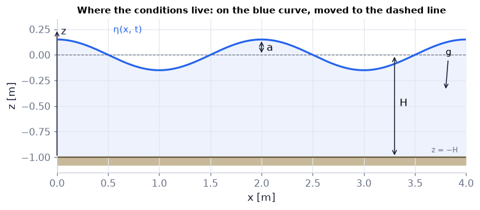

```python
H, L, a, k = 1.0, 4.0, 0.15, 2*np.pi/2.0                  # a drawing: depth 1 m, 4 m of tank, 15 cm wave, λ = 2 m
fig, ax = plt.subplots(figsize=(7, 3))                    # one panel
tank(ax, H, L)                                            # bottom z = −H (hatched), dashed still level z = 0, z-axis
x = np.linspace(0, L, 400)                                # positions [m]
wave_surface(ax, x, a*np.cos(k*x), fill_to=-H)            # the free surface η = a cos kx (blue) with the water shaded
ax.annotate("", xy=(2.0, a), xytext=(2.0, 0), arrowprops=dict(arrowstyle="<->", color=COLORS["ink"]))   # amplitude a
ax.text(2.05, 0.04, "a", fontsize=11)
ax.annotate("", xy=(3.3, -H), xytext=(3.3, 0), arrowprops=dict(arrowstyle="<->", color=COLORS["ink"]))  # depth H
ax.text(3.35, -0.5, "H", fontsize=11)
ax.text(0.55, 0.22, "η(x, t)", color=COLORS["blue"], fontsize=10)
ax.annotate("g", xy=(3.8, -0.35), xytext=(3.8, 0.0), arrowprops=dict(arrowstyle="->", color=COLORS["ink"]), fontsize=10)
ax.set_ylim(-1.15, 0.35); ax.set_xlabel("x [m]"); ax.set_ylabel("z [m]")
ax.set_title("Where the conditions live: on the blue curve, moved to the dashed line", fontsize=10)
savefig(fig, "ch07", "c02_geometry"); plt.show()
```

**What you see.** The geometry of every problem in §7.2–§7.6 (our remake of Fig. 7.2 `N168`): the still level z = 0 (dashed), the surface η = a cos kx (blue), the bottom z = −H, and gravity pointing down.

**How to read it.** z = 0 is where the surface would be at rest; the conditions of this block are first written on the blue curve, then moved to the dashed line.

**What would change if…** …H → ∞: the bottom disappears and $w=\partial\phi/\partial z=0\ \text{on}\ z=-H$ *(7.12)* becomes "φ → 0 as z → −∞" (deep water, D08).

#### The idea

Any smooth quantity evaluated on the surface can be Taylor-expanded about the flat level:

```
condition lives on z = η(x, t)            (unknown, moving)
F(η) = F(0) + η F′(0) + …                 (Taylor about z = 0)
keep F(0):  error ≈ η F′ ≈ ka × (kept term)  ⇒  negligible when ka ≪ 1
```

**Linear = drop products of small quantities, then apply the conditions on z = 0.**

> 📎 **Primer — Taylor transfer of a boundary condition.** `P166` · A condition on a moving boundary z = η can be written on the fixed level z = 0 by expanding each quantity F about z = 0: F(η) ≈ F(0) + ηF′(0) (Ch. 1 P26). If F varies on the scale 1/k and η ~ a, the correction is about ka times F — so for gentle waves we keep only F(0), and both of the book's approximations, $\big(\frac{\partial\phi}{\partial z}\big)_{z=\eta}\cong\frac{\partial\eta}{\partial t}$ *(7.17)* and $\big(\frac{\partial\phi}{\partial z}\big)_{z=0}\cong \frac{\partial\eta}{\partial t}$ *(7.18)*, make errors of the same order ka.

```python
import numpy as np                                # numbers
k, eta = 1.0, 0.05                                # decay rate [1/m] and a small surface height [m]
F = lambda z: np.exp(k*z)                         # a quantity that varies on the scale 1/k
print(F(eta), F(0) + eta*k*F(0), F(0))            # 1.05127, 1.05, 1.0: dropping ηF′ costs 5 % = ka
```

```
1.0512710963760241 1.05 1.0
```

> 🔁 **Tools from earlier chapters used here** (see `knowledge/primers.md`) — the tools of D02
- **moving level set and its normal speed** — a surface f = 0 has normal ∇f/|∇f| and a point riding on it keeps f = 0, so Df/Dt = 0 there (Ch. 4 P132).
- **chain rule along a path** — $df/dt=f_x\dot x+f_z\dot z+f_t$ along a moving point (Ch. 3 P91).
- **level sets and the normal to a surface** — the gradient of a function is perpendicular to its level sets (Ch. 2 P75).

#### 🧮 Derivation — The exact kinematic condition from $(\mathbf n\cdot\mathbf u)_{z=\eta}=\mathbf n\cdot\mathbf U_s$ `D02` (Eq. 7.16: $\Big(\frac{\partial\phi}{\partial z}\Big)_{z=\eta}=\frac{\partial\eta}{\partial t}+\frac{\partial\eta}{\partial x}\Big(\frac{\partial\phi}{\partial x}\Big)_{z=\eta}$)

**What we want to show.** Turn "the water on the surface stays on the surface" into an equation for φ and η.

**Assumptions.** The surface is a single-valued graph z = η(x, t) — no overturning (step 1); 2-D motion in x–z.

**The plan.**

1. Describe the surface by a level-set function.
2. Build its normal.
3. Choose a simple surface velocity.
4. Clear the square root and insert φ.

**Tools we use** (each explained before this point): level sets and the normal (P75) · moving level set (P132) · chain rule (P91) · R04 (Ch. 4 §4.10).

**We start from**

$$ (\mathbf n\cdot\mathbf u)_{z=\eta}=\mathbf n\cdot\mathbf U_s\ \text{(7.13)} $$

*In words:* the water's velocity across the surface equals the surface's own normal speed.

**Step 1 of 8 — Write the surface as a level set.**

$$ f(x,z,t)=z-\eta(x,t)=0 $$

- *Why we can do this:* The surface is where the height z equals η; f vanishes exactly there. Needs a single-valued η (no breaking). ⚠️ Ch. 4 called the level-set function η; here η is the height.
- *In words:* surface points are those with f = 0.

**Step 2 of 8 — Take the gradient of f.**

$$ \nabla f=-\frac{\partial\eta}{\partial x}\mathbf e_x+\mathbf e_z $$

- *Why we can do this:* ∂f/∂x = −∂η/∂x and ∂f/∂z = 1 since η does not depend on z; a level set's gradient is normal to it (P75).
- *In words:* a vector perpendicular to the surface, pointing up out of the water.

**Step 3 of 8 — Normalise to a unit vector.**

$$ \mathbf n=\frac{-(\partial\eta/\partial x)\mathbf e_x+\mathbf e_z}{\sqrt{ (\partial\eta/\partial x)^2+1}}\ \text{(7.14)} $$

- *Why we can do this:* Dividing by $\lvert\nabla f\rvert$ gives length 1; the positive z part means it points out of the liquid.
- *In words:* the unit normal leans back against the slope.

**Step 4 of 8 — Choose the surface velocity.**

$$ \mathbf U_s=\frac{\partial\eta}{\partial t}\mathbf e_z\ \text{(7.15)} $$

- *Why we can do this:* Only n·U_s appears in (7.13), $(\mathbf n\cdot\mathbf u)_{z=\eta}=\mathbf n\cdot\mathbf U_s$; following the surface point straight above a fixed x is a valid choice with the right normal part.
- *In words:* we let the surface point at fixed x go straight up and down.

**Step 5 of 8 — Multiply (7.13) by the length of ∇f.**

$$ (\nabla f\cdot\mathbf u)_{z=\eta}=\nabla f\cdot\mathbf U_s $$

- *Why we can do this:* n = ∇f/|∇f| and |∇f| ≥ 1 is never zero, so multiplying both sides is allowed; it removes the square root.
- *In words:* the same condition without normalising.

**Step 6 of 8 — Work out both dot products.**

$$ \big(-u\frac{\partial\eta}{\partial x}+w\big)_{z=\eta}=\frac{\partial\eta} {\partial t} $$

- *Why we can do this:* ∇f·u with u = u e_x + w e_z gives −uη_x + w; ∇f·U_s = e_z·(η_t e_z) = η_t.
- *In words:* upward velocity minus what the slope turns into the vertical equals the rise rate.

**Step 7 of 8 — Insert the velocity potential.**

$$ \big(\frac{\partial\phi}{\partial z}\big)_{z=\eta}=\frac{\partial\eta} {\partial t}+\frac{\partial\eta}{\partial x}\big(\frac{\partial\phi}{\partial x}\big)_{z=\eta}\ \text{(7.16)} $$

- *Why we can do this:* (7.10) u = ∂φ/∂x, w = ∂φ/∂z; move the slope term to the right-hand side.
- *In words:* the exact kinematic condition in φ.

**Step 8 of 8 — Recognise the material derivative.**

$$ \frac{D(z-\eta)}{Dt}=w-\frac{\partial\eta}{\partial t}-u\frac{\partial \eta}{\partial x}=0\ \text{on}\ z=\eta $$

- *Why we can do this:* D/Dt = ∂/∂t + u∂/∂x + w∂/∂z applied to f = z − η gives step 6: Ch. 4's (4.91), $\frac{D\eta}{Dt}=\frac{\partial\eta}{\partial t}+(\mathbf u\cdot\nabla)\eta=0\ \text{on}\ \eta=0$ with the level-set function z − η.
- *In words:* a surface particle keeps f = 0 — it stays on the surface.

**Result**

$$ \big(\frac{\partial\phi}{\partial z}\big)_{z=\eta}=\frac{\partial\eta}{\partial t}+\frac{\partial\eta}{\partial x} \big(\frac{\partial\phi}{\partial x}\big)_{z=\eta} $$

*In words:* exact, nonlinear, and applied on the unknown surface.

**What it means.** The difficulty of water waves in one line: the condition is nonlinear and lives on a moving, unknown boundary. D03 removes both difficulties for small waves.

**Check it.** Units: every term m/s ✓. Still water (η = 0, φ = 0) satisfies it ✓. A surface rising uniformly (η_x = 0) gives w = η_t ✓. The linear wave of C03 misses it by O(a²kω) (the code cell after the tiny example of C02 prints it: about 5×10⁻³ m/s for a = 5 cm, k = 1 rad/m).

> ⚠️ **Common confusion (traps in `D02`):** Using ch04's η (a level-set function) as if it were the height; forgetting that only the normal part of U_s matters; applying it to overturning (breaking) waves.

📝 **Note.** **The pieces of D02** `N13–N15` — The upward unit normal of the surface f = z − η(x, t) = 0 is $\mathbf n=\big(-(\partial\eta/\partial x)\mathbf e_x+\mathbf e_z\big)\big/\sqrt{(\partial\eta/\partial x)^2+1}$ *(7.14)* (D02 step 3; for a slope of 0.1 it is (−0.0995, 0.9950), printed below). ⚠️ In Ch. 4 the level-set function was called η; here η is the height and the function is z − η. Only the normal part of the surface velocity matters, so we may follow the surface point straight above x: $\mathbf U_s=(\partial\eta/\partial t)\,\mathbf e_z$ *(7.15)*. The exact kinematic condition (7.16), $\Big(\frac{\partial\phi}{\partial z}\Big)_{z=\eta}=\frac{\partial\eta}{\partial t}+\frac{\partial\eta}{\partial x}\Big(\frac{\partial\phi}{\partial x}\Big)_{z=\eta}$ is D02's result — it is $D(z-\eta)/Dt=0$.

```python
print(ch07.surface_normal(0.1))                          # (7.14) for a surface slope ∂η/∂x = 0.1: (n_x, n_z) [–]
```

```
[-0.0995  0.995 ]
```

> 🔁 **Tools from earlier chapters used here** (see `knowledge/primers.md`) — the tools of D03 and D04
- **limits and orders of smallness** — a product of two small quantities is smaller than either by one more factor of smallness (Ch. 2 P68).
- **order-of-magnitude scaling** — replace each quantity by its typical size — ∂η/∂t ~ aω, ∂η/∂x ~ ka — and compare terms (Ch. 4 P130).
- **first-order Taylor expansion** — $f(z+dz)\approx f(z)+f'(z)\,dz$, error ∝ dz² (Ch. 1 P26).
- **central differences** — $f'(x)\approx[f(x+h)-f(x-h)]/2h$, error ∝ h² (Ch. 1 P21) — used in the from-scratch cell below.
- **power laws, log–log slopes, observed order** — $y=Cx^p$ is a straight line of slope p on log–log axes; `observed_order` fits p (Ch. 1 P13) — used in the residual figure below.

#### 🧮 Derivation — Linearising and moving the kinematic condition `D03` (Eq. 7.18: $\Big(\frac{\partial\phi}{\partial z}\Big)_{z=0}\cong\frac{\partial\eta}{\partial t}$)

**What we want to show.** Replace the exact condition (7.16), $\Big(\frac{\partial\phi}{\partial z}\Big)_{z=\eta}=\frac{\partial\eta}{\partial t}+\frac{\partial\eta}{\partial x}\Big(\frac{\partial\phi}{\partial x}\Big)_{z=\eta}$ by a linear one applied on the flat level z = 0, and measure what that costs.

**Assumptions.** ka ≪ 1 (steps 2, 5); a/H ≪ 1 (step 8); the wave field varies on the scale 1/k.

**The plan.**

1. Size every term.
2. Drop the product of small quantities.
3. Taylor-transfer the left side to z = 0.
4. Show both errors are of the same order ka.

**Tools we use** (each explained before this point): Taylor transfer of a boundary condition (P166) · orders of smallness (P68) · order-of-magnitude scaling (P130).

**We start from**

$$ \big(\frac{\partial\phi}{\partial z}\big)_{z=\eta}=\frac{\partial\eta}{\partial t}+\frac{\partial\eta}{\partial x} \big(\frac{\partial\phi}{\partial x}\big)_{z=\eta}\ \text{(7.16).} $$

**Step 1 of 8 — Size the terms.**

$$ \frac{\partial\eta}{\partial t}\sim a\omega,\quad\frac{\partial\eta}{\partial x}\sim ka, \quad\frac{\partial\phi}{\partial x}\sim a\omega $$

- *Why we can do this:* For η = a cos(kx − ωt) each derivative brings ω or k; the water at the surface has to keep up with a surface that rises at ∂η/∂t ∼ aω, so the velocities are of size aω too (no formula from C03 needed). Order-of-magnitude scaling (P130).
- *In words:* rise rate and velocity are about aω; the slope is about ka.

**Step 2 of 8 — Size the product term.**

$$ \frac{\partial\eta}{\partial x}\frac{\partial\phi}{\partial x}\sim ka\cdot a\omega $$

- *Why we can do this:* A product of two small quantities; compared with the kept terms it is smaller by the factor ka ≪ 1 (P68).
- *In words:* the slope-times-velocity term is ka times too small to matter.

**Step 3 of 8 — Drop it.**

$$ \big(\frac{\partial\phi}{\partial z}\big)_{z=\eta}\cong\frac{\partial\eta}{\partial t}\ \text{(7.17)} $$

- *Why we can do this:* Linearisation keeps only terms of first order in the amplitude; the relative error is O(ka).
- *In words:* the water's upward speed at the surface equals the surface's rise rate.

**Step 4 of 8 — Taylor-expand the left side about z = 0.**

$$ \big(\frac{\partial\phi}{\partial z}\big)_{z=\eta}=\big(\frac{ \partial\phi}{\partial z}\big)_{z=0}+\eta\big(\frac{\partial^2\phi}{\partial z^2}\big)_{z=0}+\ldots $$

- *Why we can do this:* φ_z is smooth in z, so its value at the small height η follows from its value and slope at z = 0 (P166, P26).
- *In words:* the velocity at the true surface is the velocity at the flat level plus a small correction.

**Step 5 of 8 — Size the correction.**

$$ \eta\frac{\partial^2\phi}{\partial z^2}\sim a\cdot k\cdot a\omega=ka\cdot a\omega $$

- *Why we can do this:* φ_z ∼ aω changes over a vertical distance about 1/k, so φ_zz ∼ k aω; η is about a.
- *In words:* the correction is also ka times the kept term.

**Step 6 of 8 — Compare the two dropped terms.**

$$ \eta\,\phi_{zz}\sim\eta_x\phi_x\sim ka\cdot a\omega $$

- *Why we can do this:* Consistency: step 3 already threw away a term of this size, so keeping this one would be false precision; both go together.
- *In words:* the two approximations stand or fall together.

**Step 7 of 8 — Keep the leading term.**

$$ \big(\frac{\partial\phi}{\partial z}\big)_{z=0}\cong\frac{\partial\eta}{\partial t}\ \text{(7.18)} $$

- *Why we can do this:* Drop the O(ka) correction of step 5; the condition now sits on the known level z = 0.
- *In words:* the vertical velocity at the still level equals the surface's rise rate.

**Step 8 of 8 — State the price.**

$$ \text{relative error}=O(ka)+O(a/H) $$

- *Why we can do this:* In shallow water φ varies over the depth H, not 1/k, so φ_zz ∼ aω/H and the correction is (a/H)·aω; ka = 2πa/λ ≪ 1 is the book's condition.
- *In words:* for swell (ka ≈ 0.06) the error is a few percent.

**Result**

$$ \big(\frac{\partial\phi}{\partial z}\big)_{z=0}\cong\frac{\partial\eta}{\partial t} $$

*In words:* linear and applied on a fixed level.

**What it means.** The method of every wave problem in this chapter, of Kelvin–Helmholtz (Ch. 11) and of the linear shallow-water equations (Ch. 13): linearise, then transfer the condition to the undisturbed boundary.

**Check it.** C02's residual scan: the exact condition evaluated with the linear solution misses by O((ka)²) in absolute terms (slope 2) and O(ka) relative to the kept terms (slope 1) ✓.

> ⚠️ **Common confusion (traps in `D03`):** Dropping one O(ka) term and keeping the other; forgetting a/H ≪ 1 in shallow water; thinking the condition is still applied on z = η.

📝 **Note.** **The kinematic approximation** `N16` — Dropping the slope × velocity product gives $\big(\frac{\partial\phi}{\partial z}\big)_{z=\eta}\cong\frac{\partial\eta} {\partial t}$ *(7.17)* (D03 step 3): the dropped term is about $ka\cdot a\omega$, the kept ones $a\omega$ — a relative error of order ka.

#### 🧮 Derivation — The linearised dynamic condition `D04` (Eq. 7.21: $\Big(\frac{\partial\phi}{\partial t}\Big)_{z=\eta}\cong\Big(\frac{\partial\phi}{\partial t}\Big)_{z=0}\cong-g\eta$)

**What we want to show.** Turn "the surface feels only atmospheric pressure" into a linear condition on φ at z = 0.

**Assumptions.** Irrotational, constant density, gravity only (step 1); no surface tension (step 6); ka ≪ 1 (steps 3, 7).

**The plan.**

1. Fix the Bernoulli constant.
2. Drop the square.
3. Evaluate on the surface.
4. Transfer to z = 0.

**Tools we use** (each explained before this point): unsteady Bernoulli (R06) · gauge pressure (R05) · Taylor transfer (P166) · orders of smallness (P68).

**We start from**

$$ (p)_{z=\eta}=0\ \text{(7.19) and}\ \frac{\partial\phi}{\partial t}+\tfrac12\lvert\nabla\phi\rvert^2+\frac p\rho+gz=C(t)\ \text{(4.83)} $$

*In words:* gauge pressure zero on the surface; unsteady Bernoulli everywhere in the water.

**Step 1 of 8 — Write unsteady Bernoulli.**

$$ \frac{\partial\phi}{\partial t}+\tfrac12\lvert\nabla\phi\rvert^2+\frac p\rho+gz=C(t) $$

- *Why we can do this:* The flow is irrotational with constant density and a conservative body force, so (4.83), $\frac{\partial\phi}{\partial t}+\tfrac12\lvert\nabla\phi\rvert^2+gz+\frac p\rho=\text{const}$ holds at every point of the water (R06).
- *In words:* four terms add up to a function of time only.

**Step 2 of 8 — Fix the constant far away.**

$$ C(t)=0 $$

- *Why we can do this:* Far from the waves the water is at rest (φ_t = 0, ∇φ = 0) on its still surface z = 0 where the gauge pressure is 0; any leftover C(t) could be absorbed into φ.
- *In words:* with gauge pressure and z = 0 at the still level, the constant vanishes.

**Step 3 of 8 — Size the square term.**

$$ \tfrac12\lvert\nabla\phi\rvert^2\sim(a\omega)^2,\quad\frac{\partial\phi}{\partial t} \sim\frac{a\omega^2}{k} $$

- *Why we can do this:* velocities are aω (the surface rises at that rate), and a potential whose gradient aω changes over a distance 1/k has size φ ∼ aω/k, so φ_t ∼ aω²/k; their ratio is ka.
- *In words:* the kinetic term is ka times smaller.

**Step 4 of 8 — Drop it.**

$$ \frac{\partial\phi}{\partial t}+\frac p\rho+gz\cong0\ \text{(7.20)} $$

- *Why we can do this:* A product of two first-order quantities is second order; linearisation drops it (P68).
- *In words:* linear Bernoulli.

**Step 5 of 8 — Evaluate on the surface.**

$$ \big(\frac{\partial\phi}{\partial t}\big)_{z=\eta}+\frac{(p)_{z=\eta}}{\rho}+g\eta \cong0 $$

- *Why we can do this:* (7.20), $\frac{\partial\phi}{\partial t}+\frac p\rho+gz\cong0$ holds everywhere in the water, including just below the surface, where z = η, so gz becomes gη (not zero).
- *In words:* at the surface, pressure, height and φ_t balance.

**Step 6 of 8 — Apply the free-surface condition.**

$$ \big(\frac{\partial\phi}{\partial t}\big)_{z=\eta}\cong-g\eta $$

- *Why we can do this:* (7.19), $(p)_{z=\eta}=0$: with no surface tension the gauge pressure just below the surface is zero, so the p term drops.
- *In words:* the surface height sets the rate of change of φ there.

**Step 7 of 8 — Taylor-transfer to z = 0.**

$$ \big(\frac{\partial\phi}{\partial t}\big)_{z=\eta}=\big(\frac{\partial\phi}{ \partial t}\big)_{z=0}+\eta\big(\frac{\partial^2\phi}{\partial z\partial t}\big)_{z=0}+\ldots $$

- *Why we can do this:* Same move as D03 step 4; the correction ηφ_tz ∼ a·aω² is ka times φ_t ∼ aω²/k.
- *In words:* moving to the flat level costs O(ka).

**Step 8 of 8 — Keep the leading term.**

$$ \big(\frac{\partial\phi}{\partial t}\big)_{z=0}\cong-g\eta\ \text{(7.21)} $$

- *Why we can do this:* Drop the O(ka) correction, consistent with (7.18), $\Big(\frac{\partial\phi}{\partial z}\Big)_{z=0}\cong\frac{\partial\eta}{\partial t}$: both surface conditions now live on z = 0.
- *In words:* the linear dynamic condition.

**Result**

$$ \big(\frac{\partial\phi}{\partial t}\big)_{z=\eta}\cong\big(\frac{\partial\phi}{\partial t}\big)_{z=0}\cong-g\eta $$

*In words:* where the surface is high, φ is decreasing.

**What it means.** Together with (7.18), $\Big(\frac{\partial\phi}{\partial z}\Big)_{z=0}\cong\frac{\partial\eta}{\partial t}$ this closes the linear problem: two conditions on z = 0 for one unknown surface — one will give φ, the other ω(k).

**Check it.** Units: m²/s² on both sides ✓. For the wave of C03, φ_t(0) = −(aω²/k)coth kH cos(…) and −gη agree exactly when (7.28), $\omega=\sqrt{gk\tanh kH}$ holds (D06) ✓.

> ⚠️ **Common confusion (traps in `D04`):** Setting gz = 0 at the surface (it is gη); the sign (φ_t = −gη); forgetting that surface tension would add a pressure (C07).

📝 **Note.** **The linearised dynamic condition** `N17` — $\big(\frac{\partial\phi}{\partial t}\big)_{z=\eta}\cong\big(\frac{\partial\phi}{\partial t}\big)_{z=0}\cong-g\eta$ *(7.21)* is D04's result.

#### The linear problem in one box (the whole of C03 starts from it)

$$\nabla^2\phi=0\ \text{(7.11)},\qquad \frac{\partial\phi}{\partial z}=0\ \text{on } z=-H\ \text{(7.12)},\qquad \Big(\frac{\partial\phi}{\partial z}\Big)_{z=0}=\frac{\partial\eta}{\partial t}\ \text{(7.18)},\qquad \Big(\frac{\partial\phi}{\partial t}\Big)_{z=0}=-g\eta\ \text{(7.21)}.$$

Four linear equations on fixed boundaries: sums of solutions are solutions (note `N02`).

#### ✏️ Tiny example: how much do we throw away?

A swell with a = 0.5 m, λ = 50 m.

1. $k=2\pi/50=0.126$ rad/m.
2. $ka=0.063$.
3. The kept terms of the kinematic condition are about $a\omega$; the dropped slope × velocity term is about $ka\cdot a\omega$ — 6 % of the kept one.
4. A steep wave with ka = 0.3 (close to breaking, C12) loses 30 %: linear theory is then only a first guess.

```python
for a in (0.05, 0.3):                                    # a gentle (ka = 0.05) and a steep (ka = 0.3) wave, k = 1 rad/m, H = 2 m
    r = ch07.free_surface_residuals(0.3, 0.0, a, 1.0, H=2.0)   # residual of every condition at x = 0.3 m, t = 0
    print(f"a = {a}:", {name: f"{v:.2e}" for name, v in r.items() if name != "scales"})   # m/s or m²/s²
```

```
a = 0.05: {'laplace': '-5.78e-15', 'bottom': '0.00e+00', 'kinematic_exact': '4.66e-03', 'kinematic_17': '2.30e-03', 'kinematic_linear': '0.00e+00', 'dynamic_exact': '-8.25e-03', 'dynamic_linear': '-5.55e-17'}
a = 0.3: {'laplace': '-6.82e-13', 'bottom': '0.00e+00', 'kinematic_exact': '2.01e-01', 'kinematic_17': '9.34e-02', 'kinematic_linear': '0.00e+00', 'dynamic_exact': '-1.07e-01', 'dynamic_linear': '-8.88e-16'}
```

**What does the code above do?**

1. For the linear wave of C03 (k = 1 rad/m, H = 2 m) the function evaluates the residual of each condition of the box: `laplace` (7.11), $\partial^2\phi/\partial x^2+\partial^2\phi/\partial z^2=0$, `bottom` (7.12), $w=\partial\phi/\partial z=0\ \text{on}\ z=-H$, `kinematic_linear` (7.18), $\Big(\frac{\partial\phi}{\partial z}\Big)_{z=0}\cong\frac{\partial\eta}{\partial t}$, `dynamic_linear` (7.21), $\Big(\frac{\partial\phi}{\partial t}\Big)_{z=\eta}\cong\Big(\frac{\partial\phi}{\partial t}\Big)_{z=0}\cong-g\eta$ — all at round-off: **the linear solution solves the linear problem exactly**.
2. `kinematic_exact` is the exact condition (7.16), $\Big(\frac{\partial\phi}{\partial z}\Big)_{z=\eta}=\frac{\partial\eta}{\partial t}+\frac{\partial\eta}{\partial x}\Big(\frac{\partial\phi}{\partial x}\Big)_{z=\eta}$ on the true surface z = η, `kinematic_17` the partial step (7.17), $\Big(\frac{\partial\phi}{\partial z}\Big)_{z=\eta}\cong\frac{\partial\eta}{\partial t}$, `dynamic_exact` the full Bernoulli equation (4.83), $\frac{\partial\phi}{\partial t}+\tfrac12\lvert\nabla\phi\rvert^2+gz+\frac p\rho=\text{const}$ with p = 0 on z = η. They are of order $10^{-3}$–$10^{-2}$ at a = 5 cm and much larger at a = 30 cm — the kinematic one 43 times: six times the amplitude, squared, plus the growing higher-order terms (at a single point the dynamic one also depends on where in the wave x sits).

**From scratch — the exact kinematic residual (7.16), $\Big(\frac{\partial\phi}{\partial z}\Big)_{z=\eta}=\frac{\partial\eta}{\partial t}+\frac{\partial\eta}{\partial x}\Big(\frac{\partial\phi}{\partial x}\Big)_{z=\eta}$ at one point**, by central differences in x and t (Ch. 1 P21: $f'(x)\approx[f(x+h)-f(x-h)]/2h$):

```python
h, x, t = 1e-6, 0.3, 0.0                                  # difference step, point [m] and time [s]
F = lambda X, Z, T: ch07.wave_fields(X, Z, T, 0.05, 1.0, H=2.0)   # the linear wave: η, u, w, … at (x, z, t)
eta = F(x, 0.0, t)["eta"]                                 # surface height at x [m]
eta_t = (F(x, 0.0, t + h)["eta"] - F(x, 0.0, t - h)["eta"])/(2*h)   # ∂η/∂t [m/s]
eta_x = (F(x + h, 0.0, t)["eta"] - F(x - h, 0.0, t)["eta"])/(2*h)   # ∂η/∂x [–]
res = F(x, eta, t)["w"] - eta_t - eta_x*F(x, eta, t)["u"]           # (7.16): w − η_t − η_x u, all on z = η [m/s]
print(f"our residual {res:.6e} m/s")
assert np.allclose(res, ch07.free_surface_residuals(x, t, 0.05, 1.0, H=2.0)["kinematic_exact"], rtol=1e-5)
```

```
our residual 4.662007e-03 m/s
```

Our three-line evaluation of (7.16), $\Big(\frac{\partial\phi}{\partial z}\Big)_{z=\eta}=\frac{\partial\eta}{\partial t}+\frac{\partial\eta}{\partial x}\Big(\frac{\partial\phi}{\partial x}\Big)_{z=\eta}$ on the true surface matches the library's residual.

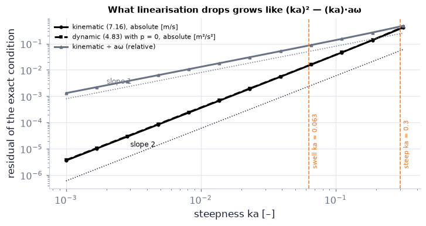

```
slopes: kinematic absolute 2.02, dynamic absolute 2.01, kinematic relative 1.02
```

```python
ka = np.logspace(-3, -0.5, 12 if not FAST else 6)         # steepness values from 0.001 to 0.32
s = ch07.free_surface_residual_scan(ka, kH=1.0)           # max residuals over a wavelength, k = 1 rad/m fixed
fig, ax = plt.subplots(figsize=(6.5, 3.4))                # one log–log panel
ax.loglog(ka, s["kinematic_abs"], "k-o", ms=3, label="kinematic (7.16), absolute [m/s]")   # misfit of (7.16) on z = η
ax.loglog(ka, s["dynamic_abs"], "k--s", ms=3, label="dynamic (4.83) with p = 0, absolute [m²/s²]")   # misfit of full Bernoulli with p = 0 on z = η
ax.loglog(ka, s["kinematic_rel"], "-^", color=COLORS["muted"], ms=3, label="kinematic ÷ aω (relative)")   # the same misfit ÷ the kept term aω
ax.loglog(ka, 0.6*ka**2, ":", color=COLORS["ink"], lw=1); ax.text(3e-3, 1.2e-5, "slope 2", fontsize=8)   # guides
ax.loglog(ka, 0.8*ka, ":", color=COLORS["muted"], lw=1); ax.text(2e-3, 3e-3, "slope 1", fontsize=8, color=COLORS["muted"])   # slope-1 guide
for kv, lab in ((0.063, "swell ka = 0.063"), (0.3, "steep ka = 0.3")):   # two markers
    ax.axvline(kv, color=COLORS["orange"], ls="--", lw=1); ax.text(kv*1.05, 2e-6, lab, rotation=90, fontsize=7, color=COLORS["orange"])   # marker line and its label
ax.set_xlabel("steepness ka [–]"); ax.set_ylabel("residual of the exact condition")   # axis labels
ax.set_title("What linearisation drops grows like (ka)² — (ka)·aω", fontsize=10); ax.legend(fontsize=7, loc="upper left")   # the message as title
savefig(fig, "ch07", "c02_residual_scan"); plt.show()   # save the PNG to outputs/ch07, then draw
print(f"slopes: kinematic absolute {s['slope_abs']:.2f}, dynamic absolute {s['slope_abs_dynamic']:.2f}, "
      f"kinematic relative {s['slope_rel']:.2f}")   # observed log–log slopes (P13)
```

**What you see.** Two black lines of slope 2 (the absolute misfit of the exact conditions, at fixed k) and one grey line of slope 1 (the misfit divided by the kept term aω); the fitted slopes are printed under the figure (2.02, 2.01 and 1.02).

**How to read it.** The dropped terms are of order $(ka)\cdot a\omega$: **relative** to the kept terms the error is O(ka) — about 6 % at the swell marker and about 30 % at the steep-wave marker. The approximation is as good as ka is small.

**What would change if…** …the waves were in shallow water (kH = 0.2): the same slopes, but a/H ≪ 1 becomes the stricter condition (the bottom term of D03 step 8).

> ⚠️ **Common confusion:** "linear" does not mean "the flow is slow". It means every product of two wave quantities (slope × velocity, velocity²) is dropped **and** the conditions are moved to z = 0; both errors are of the same order ka, so doing one without the other is inconsistent.

**What would change if…** …the surface had surface tension? The dynamic condition gains a curvature term, $\big(\frac{\partial\phi}{\partial t}\big)_{z=0}=\frac\sigma\rho\frac{\partial^2\eta}{\partial x^2}-g\eta$ *(7.55)* (C07). …there were a second fluid above? Both conditions become two-sided, (7.93)–(7.94), $\frac{\partial\phi_1}{\partial z}=\frac{\partial\phi_2}{\partial z}=\frac{\partial\zeta}{\partial t}\ \text{at}\ z=0,\ \rho_1\frac{\partial\phi_1}{\partial t}+\rho_1g\zeta=\rho_2\frac{\partial\phi_2}{\partial t}+\rho_2g\zeta\ \text{at}\ z=0$ (C13) — and with a shear flow they give the Kelvin–Helmholtz instability of Ch. 11.

### 🧩 The dispersion relation `C03`

*The question:* Given a wavelength and a depth, how fast must the surface oscillate — and why is there only one answer?

*In one line:* $\omega=\sqrt{gk\tanh kH}$ *(7.28)*

#### The problem in plain words

In a wave tank, push the paddle slowly and long waves come out; push it fast and short ones do. The water decides the wavelength that goes with each frequency. We want that rule — the dispersion relation — because it is the chapter's hub: speeds, orbits, energy flux, seiches, refraction and group velocity are all read off it. Ch. 4 already *used* $\omega^2=gk\tanh kH$ as a test field (`ch04.linear_wave_surface`); here we derive it for the first time.

#### The idea

```
try   φ = f(z) · sin(kx − ωt)        (the surface is a cosine, so φ must be a sine)
Laplace (7.11)          ⇒  f″ = k² f      ⇒  f = A e^{kz} + B e^{−kz}
bottom (7.12)           ⇒  B/A fixed      ⇒  f ∝ cosh k(z + H)
kinematic (7.18)        ⇒  size fixed by a and ω
dynamic (7.21)          ⇒  only one ω for each k   ←  the dispersion relation
```

*The numbered equations in the sketch:* $\partial^2\phi/\partial x^2+\partial^2\phi/\partial z^2=0$ *(7.11)* · $w=\partial\phi/\partial z=0\ \text{on}\ z=-H$ *(7.12)* · $\Big(\frac{\partial\phi}{\partial z}\Big)_{z=0}\cong\frac{\partial\eta}{\partial t}$ *(7.18)* · $\Big(\frac{\partial\phi}{\partial t}\Big)_{z=\eta}\cong\Big(\frac{\partial\phi}{\partial t}\Big)_{z=0}\cong-g\eta$ *(7.21)*

> 📎 **Primer — separation of variables for a PDE.** `P167` · When a linear PDE and its boundaries are straight in x and z, try a product: one function of z times a wave in x. Substituting turns ∂²/∂x² into −k², so the PDE becomes an ordinary differential equation for the z-part (Ch. 1 P44 solved those with an $e^{\lambda z}$ trial). The x-part is chosen by the boundary conditions — here the surface cosine. (Not the same move as Ch. 1's "separation of variables" for an ODE, P42, which put each variable on its own side.)

```python
import sympy as sp                                # symbolic algebra
x, z, k = sp.symbols('x z k', positive=True)     # coordinates and the wavenumber
f = sp.Function('f')                              # the unknown depth profile
phi = f(z)*sp.sin(k*x)                            # the product trial
print(sp.simplify((sp.diff(phi, x, 2) + sp.diff(phi, z, 2))/sp.sin(k*x)))   # -k**2*f(z) + f''(z): an ODE in z
```

```
-k**2*f(z) + Derivative(f(z), (z, 2))
```

> 📎 **Primer — hyperbolic functions cosh, sinh, tanh.** `P168` · $\cosh x=(e^x+e^{-x})/2$, $\sinh x=(e^x-e^{-x})/2$, $\tanh=\sinh/\cosh$, $\coth=1/\tanh$, $\mathrm{sech}=1/\cosh$. Rules used in this chapter: $\cosh^2-\sinh^2=1$, $\cosh^2+\sinh^2=\cosh2x$, $2\sinh x\cosh x=\sinh2x$, $(\cosh)'=\sinh$, $(\sinh)'=\cosh$, $(\tanh)'=\mathrm{sech}^2$. Small x: cosh ≈ 1, sinh ≈ tanh ≈ x. Large x: cosh ≈ sinh ≈ $e^x/2$, tanh → 1 (tanh 2 = 0.964). Here x = kH: tanh kH switches between shallow and deep water.

```python
import numpy as np                                # numbers
x = np.array([0.1, 1.0, 2.0, 5.0])               # four arguments
print(np.cosh(x), np.sinh(x), np.tanh(x))         # tanh: 0.0997 0.762 0.964 1.000
print(np.cosh(x)**2 - np.sinh(x)**2)              # [1. 1. 1. 1.] — the identity
```

```
[ 1.005   1.5431  3.7622 74.2099] [ 0.1002  1.1752  3.6269 74.2032] [0.0997 0.7616 0.964  0.9999]
[1. 1. 1. 1.]
```

📝 **Note.** **The initial shape** `N18` — The linear problem also needs an initial surface shape; the book picks η(x, 0) = a cos kx (the general case is note N02's Fourier sum).

📝 **Note.** **The trial** `N19` — D05's step 1:

$$ \phi(x,z,t)=f(z)\sin(kx-\omega(k)t) \qquad \text{(7.22)} $$

> 🔁 **Tools from earlier chapters used here** (see `knowledge/primers.md`) — two linear equations in two unknowns are solved in D05 steps 7–8; matching coefficients of cos(kx − ωt) is explained in D06 step 4
- **linear second-order ODE and the $e^{\lambda z}$ trial** — try $f=e^{\lambda z}$: $f''-k^2f=0$ gives $\lambda^2=k^2$, so λ = ±k — real roots, exponentials (Ch. 1 P44).
- **exponent rules** — $e^{a}e^{b}=e^{a+b}$; factoring $e^{-kH}$ out of $e^{kz}+e^{-2kH}e^{-kz}$ uses it (Ch. 1 P43).

#### 🧮 Derivation — The velocity potential from the separable trial `D05` (Eq. 7.26: $\phi=\frac{a\omega}{k}\frac{\cosh k(z+H)}{\sinh kH}\sin(kx-\omega t)$)

**What we want to show.** Find the flow under a small sinusoidal surface wave on water of depth H.

**Assumptions.** Linear problem of C02; flat bottom; a single sinusoid. The dynamic condition (7.21), $\Big(\frac{\partial\phi}{\partial t}\Big)_{z=\eta}\cong\Big(\frac{\partial\phi}{\partial t}\Big)_{z=0}\cong-g\eta$ is **not** used yet (it gives ω(k) in D06).

**The plan.**

1. Try a product of a depth profile and a travelling sine.
2. Laplace gives an ODE for the profile.
3. The bottom fixes its shape, the surface its size.
4. Rewrite with cosh.

**Tools we use** (each explained before this point): separation of variables for a PDE (P167) · $e^{\lambda z}$ trial (P44) · hyperbolic functions (P168) · two linear equations.

**We start from**

$$ \begin{array}{l}\nabla^2\phi=0\ \text{(7.11),}\ \frac{\partial\phi}{\partial z}=0\ \text{at}\ z=-H\ \text{(7.12),}\ \big(\frac{\partial\phi}{\partial z}\big)_{z=0}=\frac{\partial\eta}{\partial t}\ \text{(7.18),} \\ \text{with}\ \eta=a\cos(kx-\omega t)\ \text{(7.2)}\end{array} $$

*In words:* Laplace in a strip, no flow through the bottom, the surface moves with the water.

**Step 1 of 11 — Try a product form.**

$$ \phi=f(z)\sin(kx-\omega t)\ \text{(7.22)} $$

- *Why we can do this:* (7.18), $\Big(\frac{\partial\phi}{\partial z}\Big)_{z=0}\cong\frac{\partial\eta}{\partial t}$ needs φ_z ∝ η_t ∝ sin and (7.21), $\Big(\frac{\partial\phi}{\partial t}\Big)_{z=\eta}\cong\Big(\frac{\partial\phi}{\partial t}\Big)_{z=0}\cong-g\eta$ needs φ_t ∝ η ∝ cos: a sine of the phase does both. Separation of variables (P167).
- *In words:* every depth moves with the same travelling shape, with its own strength f(z).

**Step 2 of 11 — Put it into Laplace's equation.**

$$ f''(z)\sin(kx-\omega t)-k^2f(z)\sin(kx-\omega t)=0 $$

- *Why we can do this:* ∂²/∂x² of sin(kx − ωt) is −k² sin(kx − ωt); ∂²/∂z² acts on f only.
- *In words:* the curvature in x must cancel the curvature in z.

**Step 3 of 11 — Divide by the sine.**

$$ \frac{d^2f}{dz^2}-k^2f=0\ \text{(7.23)} $$

- *Why we can do this:* The equation holds for all x and t, in particular where the sine is not zero; dividing there leaves an ODE in z alone.
- *In words:* the depth profile obeys a simple ODE.

**Step 4 of 11 — Solve the ODE.**

$$ f(z)=Ae^{kz}+Be^{-kz}\ \text{(7.23)} $$

- *Why we can do this:* The trial $e^{\lambda z}$ (P44) gives λ² = k², λ = ±k — real because of the + sign: growth and decay in z, not oscillation.
- *In words:* the strength changes exponentially with depth.

**Step 5 of 11 — Apply the bottom condition.**

$$ k(Ae^{-kH}-Be^{kH})=0\ \Rightarrow\ B=Ae^{-2kH}\ \text{(7.24)} $$

- *Why we can do this:* (7.12), $w=\partial\phi/\partial z=0\ \text{on}\ z=-H$: f′(−H) = 0 for all x and t; multiply by $e^{kH}$/k.
- *In words:* the bottom fixes the mix of the two exponentials.

**Step 6 of 11 — Apply the kinematic condition.**

$$ k(A-B)\sin(kx-\omega t)=\omega a\sin(kx-\omega t)\ \text{(7.25)} $$

- *Why we can do this:* (7.18), $\Big(\frac{\partial\phi}{\partial z}\Big)_{z=0}\cong\frac{\partial\eta}{\partial t}$: φ_z at z = 0 is k(A − B) sin(…), and η_t = aω sin(kx − ωt) from (7.2), $\eta(x,t)=a\cos[kx-\omega t]$.
- *In words:* the surface rises as fast as the water under it.

**Step 7 of 11 — Cancel the sine and insert B.**

$$ A(1-e^{-2kH})=\frac{\omega a}{k} $$

- *Why we can do this:* Matching coefficients (true for all x, t); B = $Ae^{-2kH}$ from step 5.
- *In words:* one equation for A.

**Step 8 of 11 — Solve for A and B.**

$$ A=\frac{a\omega}{k(1-e^{-2kH})},\quad B=\frac{a\omega e^{-2kH}}{k(1-e^{-2kH})} $$

- *Why we can do this:* 1 − $e^{-2kH}$ > 0 for kH > 0, so we may divide; B = $Ae^{-2kH}$.
- *In words:* both constants from a, ω, k, H.

**Step 9 of 11 — Regroup f as a cosh.**

$$ f=Ae^{-kH}\big(e^{k(z+H)}+e^{-k(z+H)}\big)=2Ae^{-kH}\cosh k(z+H) $$

- *Why we can do this:* $Ae^{kz}$ + $Ae^{-2kH}e^{-kz}$: factor $Ae^{-kH}$; cosh u = (eᵘ + e⁻ᵘ)/2 (P168).
- *In words:* the depth profile is a cosh measured up from the bottom.

**Step 10 of 11 — Simplify the prefactor.**

$$ 2Ae^{-kH}=\frac{a\omega}{k}\,\frac{2e^{-kH}}{1-e^{-2kH}}=\frac{a\omega}{k\sinh kH} $$

- *Why we can do this:* Multiply top and bottom by $e^{kH}$: 2/($e^{kH}$ − $e^{-kH}$) = 1/sinh kH.
- *In words:* the strength at the bottom of the cosh.

**Step 11 of 11 — Assemble φ.**

$$ \phi=\frac{a\omega}{k}\frac{\cosh k(z+H)}{\sinh kH}\sin(kx-\omega t)\ \text{(7.26)} $$

- *Why we can do this:* Put steps 9–10 into (7.22), $\phi(x,z,t)=f(z)\sin(kx-\omega(k)t)$. ω is still free: the dynamic condition will fix it (D06).
- *In words:* the flow under a linear wave.

**Result**

$$ \begin{array}{l}\phi=\frac{a\omega}{k}\frac{\cosh k(z+H)}{\sinh kH}\sin(kx-\omega t)\ \text{(7.26), and by one derivative each}\ u=a\omega\frac{\cosh k(z+H)}{\sinh kH}\cos(kx-\omega t)\ \text{,} \\ w=a\omega\frac{\sinh k(z+H)}{\sinh kH}\sin(kx-\omega t)\end{array} $$

**What it means.** The motion decays from the surface on the scale 1/k and is squeezed by the bottom when kH is small; this cosh ratio reappears in the pressure (7.31), $p'=\rho ga\frac{\cosh k(z+H)}{\cosh kH}\cos(kx-\omega t)$, the orbits (7.35), $\xi\cong-a\frac{\cosh k(z_0+H)}{\sinh kH}\sin(kx_0-\omega t),\ \zeta\cong a\frac{\sinh k(z_0+H)}{\sinh kH}\cos(kx_0-\omega t)$ and the energy (7.38), $E_k=\frac{\rho}{2\lambda}\int_0^\lambda\!\!\int_{-H}^0(u^2+w^2)\,dz\,dx$.

**Check it.** Units: aω/k [m²/s] ✓. ∇²φ = (k² − k²)φ = 0 ✓; φ_z(−H) ∝ sinh 0 = 0 ✓; φ_z(0) = aω sin(…) = η_t ✓ (the `surface_wave_sympy` residuals are all 0; parity with Ch. 4's test field to 1e-12).

> ⚠️ **Common confusion (traps in `D05`):** Choosing cos instead of sin in (7.22), $\phi(x,z,t)=f(z)\sin(kx-\omega(k)t)$; expecting sin/cos in z (the + sign gives exponentials); using the dynamic condition too early; forgetting that sinh kH → 0 in very shallow water (the ratio stays finite).

📝 **Note.** **Where D05 passes** `N20–N23` — D05 passes through $\frac{d^2f}{dz^2}-k^2f=0,\ f=Ae^{kz}+Be^{-kz}$ *(7.23)* (steps 2–4), the bottom condition $k(Ae^{-kH}-Be^{+kH})\sin(kx-\omega t)=0$, i.e. $B=Ae^{-2kH}$ *(7.24)* (step 5), the kinematic condition $k(A-B)=\omega a$ *(7.25)* (step 6), and ends at $\phi=\frac{a\omega}{k}\frac{\cosh k(z+H)}{\sinh kH}\sin(kx-\omega t)$ *(7.26)*.

📝 **Note.** **The velocities** `N24` — One derivative each gives the velocities below (∂/∂x of the sine gives k cos; d/dz of cosh k(z + H) gives k sinh k(z + H)). They came from the kinematic conditions alone: the pressure follows afterwards from Bernoulli. The code cell checks that Ch. 4's test field is exactly this derived solution.

$$ u=a\omega\frac{\cosh k(z+H)}{\sinh kH}\cos(kx-\omega t),\ w=a\omega\frac{\sinh k(z+H)}{\sinh kH}\sin(kx-\omega t) \qquad \text{(7.27)} $$

```python
x, z, t = 0.7, -0.4, 1.3                                  # a point under the wave [m] and a time [s]
f7 = ch07.wave_fields(x, z, t, 0.05, 1.0, H=2.0)          # this chapter's (7.26)–(7.27): a = 5 cm, k = 1 rad/m, H = 2 m
f4 = ch04.linear_wave_surface(x, z, t, a=0.05, k=1.0, H=2.0)   # Ch. 4's test field at the same point
print(f7["u"], f7["w"], "|", f4["u"], f4["w"])            # u, w [m/s] from both
assert np.allclose([f7["u"], f7["w"]], [f4["u"], f4["w"]], rtol=1e-12)   # identical
```

```
-0.10794185682219147 0.015669614602760718 | -0.10794185682219148 0.015669614602760718
```

#### 🧮 Derivation — The dispersion relation $\omega=\sqrt{gk\tanh kH}$ `D06` (Eq. 7.28: $\omega=\sqrt{gk\tanh kH}$)

**What we want to show.** Use the last condition — the free surface feels no pressure — to find the one frequency that goes with each wavenumber.

**Assumptions.** As D05; ω > 0 for a right-going wave (step 6).

**The plan.**

1. Compute φ_t at z = 0.
2. Insert into (7.21), $\Big(\frac{\partial\phi}{\partial t}\Big)_{z=\eta}\cong\Big(\frac{\partial\phi}{\partial t}\Big)_{z=0}\cong-g\eta$.
3. Match coefficients and solve for ω.

**Tools we use** (each explained before this point): hyperbolic functions and coth (P168) · matching coefficients (gloss) · D05.

**We start from**

$$ \phi=\frac{a\omega}{k}\frac{\cosh k(z+H)}{\sinh kH}\sin(kx-\omega t)\ \text{(7.26) and}\ \big(\frac{\partial\phi}{\partial t}\big)_{z=0}\cong-g\eta\ \text{(7.21).} $$

**Step 1 of 7 — Differentiate φ in time.**

$$ \frac{\partial\phi}{\partial t}=-\frac{a\omega^2}{k}\frac{\cosh k(z+H)}{\sinh kH} \cos(kx-\omega t) $$

- *Why we can do this:* d/dt sin(kx − ωt) = −ω cos(kx − ωt); the depth factor does not depend on t.
- *In words:* φ_t is a cosine, in step with η.

**Step 2 of 7 — Evaluate at z = 0.**

$$ \big(\frac{\partial\phi}{\partial t}\big)_{z=0}=-\frac{a\omega^2}{k}\frac{\cosh kH}{\sinh kH} \cos(kx-\omega t) $$

- *Why we can do this:* (7.21), $\Big(\frac{\partial\phi}{\partial t}\Big)_{z=\eta}\cong\Big(\frac{\partial\phi}{\partial t}\Big)_{z=0}\cong-g\eta$ is applied on the still level; cosh k(0 + H) = cosh kH.
- *In words:* the value at the surface.

**Step 3 of 7 — Insert into the dynamic condition.**

$$ -\frac{a\omega^2}{k}\coth kH\cos(kx-\omega t)=-ag\cos(kx-\omega t) $$

- *Why we can do this:* (7.21), $\Big(\frac{\partial\phi}{\partial t}\Big)_{z=\eta}\cong\Big(\frac{\partial\phi}{\partial t}\Big)_{z=0}\cong-g\eta$ with η = a cos(kx − ωt) (7.2), $\eta(x,t)=a\cos[kx-\omega t]$; coth = cosh/sinh. This is the book's unnumbered line.
- *In words:* the surface's inertia must balance gravity everywhere.

**Step 4 of 7 — Match the coefficients.**

$$ \frac{\omega^2}{k}\coth kH=g $$

- *Why we can do this:* The identity holds for all x and t, so the coefficients of cos(kx − ωt) must be equal; then divide by −a ≠ 0.
- *In words:* one equation linking ω and k.

**Step 5 of 7 — Solve for ω².**

$$ \omega^2=gk\tanh kH $$

- *Why we can do this:* Multiply by k and by tanh kH = 1/coth kH.
- *In words:* the frequency squared.

**Step 6 of 7 — Take the positive root.**

$$ \omega=\sqrt{gk\tanh kH}\ \text{(7.28)} $$

- *Why we can do this:* −ω gives the same wave moving the other way (7.61), $\eta(x,t)=a\cos[kx+\omega t]$; for our right-going wave ω > 0.
- *In words:* the dispersion relation.

**Step 7 of 7 — Rewrite with T and λ.**

$$ T=\sqrt{\frac{2\pi\lambda}{g}\coth\frac{2\pi H}{\lambda}}\ \text{(7.28)} $$

- *Why we can do this:* ω = 2π/T, k = 2π/λ: T² = 4π²/[(2πg/λ) tanh(2πH/λ)] = (2πλ/g) coth(2πH/λ).
- *In words:* the period that goes with each wavelength.

**Result**

$$ \omega=\sqrt{gk\tanh kH}\ \text{, or}\ T=\sqrt{\frac{2\pi\lambda}{g}\coth\frac{2\pi H}{\lambda}} $$

**What it means.** The water will not oscillate at any frequency for a given wavelength: gravity (the restoring force) and the inertia of a layer of depth ~min(1/k, H) fix it. Everything in §7.2–§7.5 is read off this relation.

**Check it.** Units: g k [1/s²] ✓. Deep limit tanh → 1: ω² = gk ✓; shallow tanh kH ≈ kH: ω = k√(gH) ✓. Number: H = 1 m, k = 1 rad/m → ω = 2.73 rad/s (C03 tiny example).

> ⚠️ **Common confusion (traps in `D06`):** Cancelling cos(kx − ωt) as if it were a number that could be zero (it is legal because the identity holds for all x, t); flipping coth and tanh; dropping one of the two 2π in the T–λ form.

📝 **Note.** **The line that produced (7.28), $\omega=\sqrt{gk\tanh kH}$** `N25` — $\big(\frac{\partial\phi}{\partial t}\big)_{z=0}=-\frac{a\omega^2}{k}\frac{\cosh kH}{\sinh kH}\cos(kx-\omega t)\cong-g\eta =-ag\cos(kx-\omega t)$ (D06 steps 2–4).

#### ✏️ Tiny example: H = 1 m, k = 1 rad/m

1. $kH=1$, $\tanh 1=0.762$.
2. $\omega^2=gk\tanh kH=9.81\times1\times0.762=7.47$ s⁻².
3. $\omega=2.73$ rad/s.
4. $T=2\pi/\omega=2.30$ s.
5. $\lambda=2\pi/k=6.28$ m and $c=\omega/k=2.73$ m/s.

Check with deep water: $\sqrt{gk}=3.13$ rad/s would be 15 % faster — the 1 m bottom slows this 6 m wave.

> 🔁 **Tools from earlier chapters used here** (see `knowledge/primers.md`)
- **sympy** — `sp.symbols`, `sp.diff`, `sp.simplify`; an expression that simplifies to 0 is an identity (Ch. 1 P40).
- **scipy.optimize.brentq** — the root of f(x) = 0 inside a bracket [a, b] where f changes sign (Ch. 3 P108).
- **np.expm1 and cancellation near zero** — subtracting nearly equal numbers loses digits; rewriting the formula avoids it (Ch. 3 P107).
- **overflow of cosh/sinh and the stable ratio** — $\cosh x$ exceeds the largest float near x ≈ 710; a ratio such as $\cosh k(z+H)/\sinh kH$ is rewritten with decaying exponentials so that it never overflows (explained in the cell below).

```python
print("ω(k = 1, H = 1) =", ch07.omega_gravity(1.0, 1.0), "rad/s")      # (7.28): the tiny example
print("T(λ = 50 m, H = 10 m) =", ch07.period_from_wavelength(50.0, 10.0), "s;  T(λ = 156 m, deep) =",
      ch07.period_from_wavelength(156.0), "s")                          # (7.28) in its T–λ form
k = ch07.wavenumber_from_omega(2*np.pi/10, 30.0)                        # invert (7.28): T = 10 s on a 30 m shelf
print(f"k = {k:.6f} rad/m, λ = {2*np.pi/k:.1f} m")
s = ch07.surface_wave_sympy()                                           # D05–D06 redone in sympy (cached)
print(s["dispersion"], s["laplace_residual"], s["bottom_residual"], s["kinematic_residual"], s["regroup_identity"])
```

```
ω(k = 1, H = 1) = 2.7333566671632985 rad/s
T(λ = 50 m, H = 10 m) = 6.1375728091598 s;  T(λ = 156 m, deep) = 9.995803951055276 s
k = 0.045764 rad/m, λ = 137.3 m
```

```
Eq(omega**2, g*k*tanh(H*k)) 0 0 0 0
```

**What does the code above do?**

1. `omega_gravity(k, H)` is the forward relation (7.28), $\omega=\sqrt{gk\tanh kH}$: 2.733 rad/s for the tiny example.
2. `period_from_wavelength` is its T–λ form $T=\sqrt{\frac{2\pi\lambda}{g}\coth\frac{2\pi H}{\lambda}}$ (D06 step 7): 6.14 s for λ = 50 m on H = 10 m (kH = 1.26), and 9.996 s for a 156 m wave in deep water.
3. `wavenumber_from_omega` inverts (7.28) with `brentq` between a deep-water and a shallow-water root that bracket the answer: T = 10 s on a 30 m shelf has λ = 137.3 m.
4. `surface_wave_sympy` redoes D05–D06 symbolically: it prints the dispersion relation and four zeros (Laplace, bottom, kinematic condition, and the regrouping of D05 step 9).
5. Numerics: cosh and sinh overflow near kH ≈ 710, so the library writes the ratio $\frac{\cosh k(z+H)}{\sinh kH}=e^{kz}\frac{1+e^{-2k(z+H)}}{1-e^{-2kH}}$ (D08 step 4) and uses `np.tanh`, which saturates safely at 1.

> 🔁 **Tools from earlier chapters used here** (see `knowledge/primers.md`)
- **Newton's method** — improve a root guess by $k\leftarrow k-f(k)/f'(k)$; it converges very fast near the root (Ch. 6 P152).

```python
w0, H = 2*np.pi/10, 30.0                                  # T = 10 s swell on a 30 m shelf: ω [rad/s], depth [m]
k = w0**2/G                                               # start from the deep-water guess k = ω²/g [rad/m]
for i in range(5):                                        # Newton on f(k) = ω² − gk tanh kH
    f = w0**2 - G*k*np.tanh(k*H)                          # the residual of (7.28) [1/s²]
    fp = -(G*np.tanh(k*H) + G*k*H/np.cosh(k*H)**2)        # f′(k) by the product and chain rules
    k -= f/fp                                             # Newton step
    print(i, f"{k:.9f}")
assert np.allclose(k, ch07.wavenumber_from_omega(w0, H), rtol=1e-10)   # same root as the library's brentq
```

```
0 0.045749013
1 0.045764159
2 0.045764159
3 0.045764159
4 0.045764159
```

```python
w = 2*np.pi/10                                            # a 10 s swell [rad/s]
for H in (2.0, 30.0, 300.0):                              # shallow, intermediate, deep [m]
    exact = ch07.wavenumber_from_omega(w, H)*H           # kH from (7.28) by brentq
    fm, guo = ch07.fenton_mckee_kh(w, H), ch07.guo_kh(w, H)   # the two explicit formulas
    print(f"H = {H:5.0f} m: kH = {exact:.5f};  Fenton–McKee {fm/exact - 1:+.2%}, Guo {guo/exact - 1:+.2%}")
```

```
H =     2 m: kH = 0.28756;  Fenton–McKee -0.84%, Guo -0.50%
H =    30 m: kH = 1.37292;  Fenton–McKee +0.51%, Guo +0.40%
H =   300 m: kH = 12.07291;  Fenton–McKee +0.00%, Guo +0.00%
```

**What does the code above do?**

Both formulas stay within their published bounds (Fenton–McKee within 0.9 %, Guo within 0.5 % here) and become exact in deep water — independent evidence that our inverse of (7.28), $\omega=\sqrt{gk\tanh kH}$ is right.

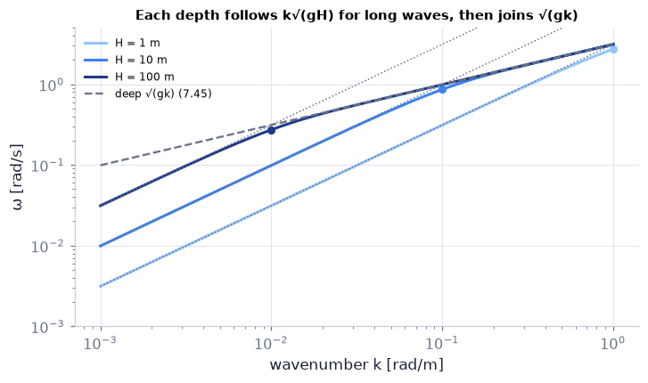

```python
k = np.logspace(-3, 0, 300)                               # wavenumbers [rad/m]
fig, ax = plt.subplots(figsize=(6.5, 3.8))                # one log–log panel
blues = ["#93c5fd", "#3b82f6", "#1e3a8a"]                 # three shades of blue for three depths
for H, cl in zip((1.0, 10.0, 100.0), blues):              # three depths [m]
    ax.loglog(k, ch07.omega_gravity(k, H), color=cl, lw=2, label=f"H = {H:g} m")    # (7.28)
    ax.loglog(k, k*np.sqrt(G*H), ":", color=COLORS["muted"], lw=1)                  # shallow line k√(gH)
    ax.plot(1/H, ch07.omega_gravity(1/H, H), "o", color=cl, ms=5)                   # kH = 1 on each curve
ax.loglog(k, np.sqrt(G*k), "--", color=COLORS["muted"], lw=1.5, label="deep √(gk) (7.45)")   # deep asymptote
ax.set_ylim(1e-3, 5); ax.set_xlabel("wavenumber k [rad/m]"); ax.set_ylabel("ω [rad/s]")
ax.set_title("Each depth follows k√(gH) for long waves, then joins √(gk)", fontsize=10); ax.legend(fontsize=8)
savefig(fig, "ch07", "c03_dispersion"); plt.show()
```

**What you see.** Three curves that start on straight lines of slope 1 (dotted, $k\sqrt{gH}$) and bend onto the common slope-½ line (dashed, $\sqrt{gk}$); a dot marks kH = 1 on each.

**How to read it.** Left of kH ≈ 0.3 the wave feels the bottom ($\omega\propto k$: all long waves move together); right of kH ≈ 3 it does not ($\omega\propto\sqrt k$).

**What would change if…** …the depth were halved: each curve's bend moves to twice the k; the deep line does not move at all.

**What would change if…** …the surface had tension σ? Every g in D06 becomes $g+\sigma k^2/\rho$, $\omega=\sqrt{k\big(g+\frac{\sigma k^2}{\rho}\big)\tanh kH}$ *(7.56)* (C07). …there were a lighter fluid above instead of air? gk is multiplied by $(\rho_2-\rho_1)/(\rho_2+\rho_1)$, $\omega=\varepsilon\sqrt{gk}$ *(7.95)* (C13).

> 🔁 **Recap — Perturbation pressure** (Ch. 4 §4.9). Split the pressure into its still-water part and the wave's part: $p'\equiv p+\rho gz$ *(7.30)* (in gauge pressure the still water has p = −ρgz). Ch. 4 made the same split, $p=p_s+p'$, for the Boussinesq equations.

### 🧩 Phase speed: dispersion, deep water and shallow water `C04`

*The question:* When does the depth matter — and why do long waves all travel together?

*In one line:* $c=\sqrt{\frac gk\tanh kH}$ *(7.29)*

#### The problem in plain words

A tsunami crosses the Pacific in less than a day; the swell from a storm in the Southern Ocean needs about a week to reach California. Both are gravity waves on the same water. The difference is the wavelength compared with the depth — we want the rule, its two limits and the numbers.

#### The idea

| regime | condition (book) | tanh kH ≈ | phase speed | pressure below | dispersive? |
| --- | --- | --- | --- | --- | --- |
| deep | kH > 2 (H > 0.32λ) | 1 | $\sqrt{g/k}$ *(7.45)* | decays like $e^{kz}$ *(7.48)* | yes: c ∝ √λ |
| intermediate | 0.44 < kH < 2 | tanh kH | $\sqrt{\frac gk\tanh kH}$ *(7.29)* | $\frac{\cosh k(z+H)}{\cosh kH}$ *(7.31)* | yes |
| shallow | H < 0.07λ (kH < 0.44) | kH | $\sqrt{gH}$ *(7.49)* | hydrostatic $\rho g\eta$ *(7.52)* | no |

**Depth is invisible to a wave shorter than about three times the depth (H > 0.32λ); for longer waves it sets the speed.**

📝 **Note.** **The two limits of the hyperbolic functions** `N37` — (primer P168) tanh x → 1 for large x ($\tanh2=0.964$ — the deep-water threshold); tanh x ≈ sinh x ≈ x and cosh x ≈ 1 for small x. The figure is our remake of Fig. 7.7 `N173`.

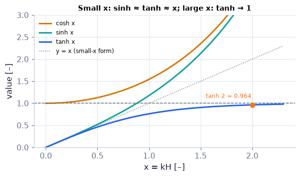

```python
xh = np.linspace(0, 2.3, 200)                             # the argument x = kH [–]
fig, ax = plt.subplots(figsize=(5.5, 3.2))                # one panel
ax.plot(xh, np.cosh(xh), color=COLORS["amber"], lw=2, label="cosh x")   # cosh starts at 1
ax.plot(xh, np.sinh(xh), color=COLORS["teal"], lw=2, label="sinh x")   # sinh starts at 0 with slope 1
ax.plot(xh, np.tanh(xh), color=COLORS["blue"], lw=2, label="tanh x")   # tanh flattens under 1
ax.plot(xh, xh, ":", color=COLORS["muted"], lw=1, label="y = x (small-x form)")   # the small-argument form
ax.axhline(1, color=COLORS["muted"], ls="--", lw=1)       # tanh's ceiling
ax.plot(2, np.tanh(2), "o", color=COLORS["orange"]); ax.text(1.55, 1.12, "tanh 2 = 0.964", color=COLORS["orange"], fontsize=8)   # the deep-water threshold kH = 2
ax.set_ylim(0, 3); ax.set_xlabel("x = kH [–]"); ax.set_ylabel("value [–]")   # axes
ax.set_title("Small x: sinh ≈ tanh ≈ x; large x: tanh → 1", fontsize=10); ax.legend(fontsize=8)   # title and legend
savefig(fig, "ch07", "c04_hyperbolic"); plt.show()   # save, then draw
```

**What you see.** cosh starts at 1, sinh and tanh at 0 with slope 1; tanh flattens under the dashed line 1.

**How to read it.** Left: sinh ≈ tanh ≈ x (shallow water); right: tanh ≈ 1 (deep water) — already 0.964 at x = 2.

**What would change if…** …we plotted to x = 5: cosh and sinh become indistinguishable (both ≈ $e^x/2$).

> 🔁 **Tools from earlier chapters used here** (see `knowledge/primers.md`)
- **product rule** — $d(uv)=u\,dv+v\,du$ (Ch. 1 P38); with the chain rule (P49) it differentiates $\lambda\tanh(2\pi H/\lambda)$ in D07.

#### 🧮 Derivation — Phase speed and why longer waves are faster `D07` (Eq. 7.29: $c=\sqrt{\frac gk\tanh kH}$)

**What we want to show.** Get the speed of crests from (7.28), $\omega=\sqrt{gk\tanh kH}$ and show it always grows with wavelength.

**Assumptions.** k > 0, H > 0.

**The plan.**

1. Divide.
2. Rewrite in λ.
3. Differentiate c² with respect to λ.

**Tools we use** (each explained before this point): product and chain rules (P38, P49) · hyperbolic functions (P168).

**We start from**

$$ \omega=\sqrt{gk\tanh kH}\ \text{(7.28) and}\ c=\omega/k\ \text{(7.4).} $$

**Step 1 of 5 — Divide ω by k.**

$$ c=\frac{\omega}{k}=\frac{\sqrt{gk\tanh kH}}{k} $$

- *Why we can do this:* This is the definition of the phase speed, (7.4) c = ω/k; we apply it to the dispersion relation.
- *In words:* crest speed from the dispersion relation.

**Step 2 of 5 — Bring k under the root.**

$$ c=\sqrt{\frac gk\tanh kH}\ \text{(7.29)} $$

- *Why we can do this:* k = √(k²) for k > 0, and gk/k² = g/k.
- *In words:* the speed depends on g/k and on kH.

**Step 3 of 5 — Rewrite in wavelength.**

$$ c=\sqrt{\frac{g\lambda}{2\pi}\tanh\frac{2\pi H}{\lambda}}\ \text{(7.29)} $$

- *Why we can do this:* k = 2π/λ, both in g/k and inside the tanh.
- *In words:* the same speed in terms of λ.

**Step 4 of 5 — Differentiate c² with respect to λ.**

$$ \frac{d}{d\lambda}\Big[\lambda\tanh\frac{2\pi H}{\lambda}\Big]= \frac{\tfrac12\sinh2x-x}{\cosh^2x},\ x=\frac{2\pi H}{\lambda} $$

- *Why we can do this:* By $c=\sqrt{\frac gk\tanh kH}$ (7.29) with k = 2π/λ, c² = (g/2π)·λ tanh(2πH/λ): the bracket is c² up to the positive constant g/2π, which cannot change the sign of the slope. Product and chain rules: tanh x + λ sech²x·(−x/λ) = (sinh x cosh x − x)/cosh²x; sinh 2x = 2 sinh x cosh x.
- *In words:* the slope of c² against λ.

**Step 5 of 5 — Read its sign.**

$$ \tfrac12\sinh 2x>x\ \Rightarrow\ \frac{dc}{d\lambda}>0 $$

- *Why we can do this:* sinh y > y for every y > 0 (its series has only positive terms), with y = 2x. So c grows with λ at any depth: dispersive.
- *In words:* longer waves outrun shorter ones.

**Result**

$$ c=\sqrt{\frac gk\tanh kH}=\sqrt{\frac{g\lambda}{2\pi}\tanh\frac{2\pi H}{\lambda}}\ \text{(7.29), increasing with λ.} $$

**What it means.** An impulse spreads into a train with the longest waves in front (the stone in a pond, C09). For long waves the growth stops at √(gH): no dispersion (D09).

**Check it.** Units m/s ✓. H = 10 m: λ = 50 m → 8.15 m/s, λ = 500 m → 9.88 m/s — faster ✓, and never above √(gH) = 9.90 m/s.

> ⚠️ **Common confusion (traps in `D07`):** √(g tanh kH/k²)·k is not the same as √((g/k) tanh kH)·… — keep one k under the root; change k in the tanh too when writing in λ.

```python
for lam in (50.0, 500.0):                                 # two wavelengths on 10 m of water [m]
    print(f"λ = {lam:.0f} m: c = {ch07.phase_speed(2*np.pi/lam, 10.0):.2f} m/s")   # (7.29): longer is faster
print(f"√(gH) = {np.sqrt(G*10.0):.2f} m/s (never exceeded)")                        # the shallow-water ceiling
```

```
λ = 50 m: c = 8.15 m/s
λ = 500 m: c = 9.88 m/s
√(gH) = 9.90 m/s (never exceeded)
```

#### 🧮 Derivation — Deep-water limits `D08` (Eq. 7.45: $c=\sqrt{g/k}=\sqrt{g\lambda/2\pi}$)

**What we want to show.** Simplify speed, orbits, velocity and pressure when the water is much deeper than the wave is long, and say how deep is deep.

**Assumptions.** kH > 2 (steps 1–3); points not too close to the bottom, z + H ≫ 1/k (step 5).

**The plan.**

1. Let kH be large in the speed.
2. Size the error at kH = 2.
3. Rewrite the depth ratios with exponentials and take the limit.

**Tools we use** (each explained before this point): hyperbolic functions and their large-x limits (P168, N37).

**We start from**

$$ \begin{array}{l}\text{(7.29)}\ c=\sqrt{\frac gk\tanh kH}\ \text{, the depth ratios}\ \frac{\cosh k(z+H)}{\sinh kH}\ \text{,}\ \frac{\sinh k(z+H)}{\sinh kH}\ \text{of (7.27), (7.35) and} \\ \frac{\cosh k(z+H)}{\cosh kH}\ \text{of (7.31).}\end{array} $$

**Step 1 of 7 — Let kH grow.**

$$ \tanh kH=\frac{1-e^{-2kH}}{1+e^{-2kH}}\to1 $$

- *Why we can do this:* Divide sinh and cosh by $e^{kH}$/2; the small exponentials vanish as kH → ∞ (P168).
- *In words:* the bottom stops mattering.

**Step 2 of 7 — Simplify the speed.**

$$ c=\sqrt{g/k}=\sqrt{g\lambda/2\pi}\ \text{(7.45)} $$

- *Why we can do this:* Substitute tanh kH = 1 in (7.29), $c=\sqrt{\frac gk\tanh kH}$.
- *In words:* deep-water speed depends on wavelength only.

**Step 3 of 7 — Size the error at kH = 2.**

$$ 1-\sqrt{\tanh2}=1-\sqrt{0.964}=0.018 $$

- *Why we can do this:* c/c_deep = √(tanh kH); kH = 2 ⇔ H = 2λ/2π = 0.32λ.
- *In words:* deeper than a third of a wavelength is 'deep' to 2 %.

**Step 4 of 7 — Rewrite the depth ratio exactly.**

$$ \frac{\cosh k(z+H)}{\sinh kH}=e^{kz}\,\frac{1+e^{-2k(z+H)}}{1-e^{-2kH}} $$

- *Why we can do this:* Multiply top and bottom by $2e^{-kH}$: $2e^{-kH}$cosh k(z + H) = $e^{kz}$ + $e^{-kz-2kH}$, $2e^{-kH}$sinh kH = 1 − $e^{-2kH}$.
- *In words:* an exact form that shows $e^{kz}$.

**Step 5 of 7 — Take the deep limit.**

$$ \frac{\cosh k(z+H)}{\sinh kH}\approx\frac{\sinh k(z+H)}{\sinh kH}\approx e^{kz} $$

- *Why we can do this:* For kH ≫ 1 and z + H ≫ 1/k both small exponentials vanish; the sinh ratio has the same limit.
- *In words:* motion decays like $e^{kz}$ below the surface.

**Step 6 of 7 — Apply to the orbits, velocity and pressure.**

$$ \xi\cong-ae^{kz_0}\sin(kx_0-\omega t),\ \zeta\cong ae^{kz_0}\cos(kx_0- \omega t)\ \text{(7.46);}\ p'=\rho gae^{kz}\cos(kx-\omega t)\ \text{(7.48)} $$

- *Why we can do this:* The same ratios sit in (7.35), $\xi\cong-a\frac{\cosh k(z_0+H)}{\sinh kH}\sin(kx_0-\omega t),\ \zeta\cong a\frac{\sinh k(z_0+H)}{\sinh kH}\cos(kx_0-\omega t)$, (7.27), $u=a\omega\frac{\cosh k(z+H)}{\sinh kH}\cos(kx-\omega t),\ w=a\omega\frac{\sinh k(z+H)}{\sinh kH}\sin(kx-\omega t)$ and (7.31), $p'=\rho ga\frac{\cosh k(z+H)}{\cosh kH}\cos(kx-\omega t)$ (cosh k(z + H)/cosh kH → $e^{kz}$ too); equal semi-axes make the orbits circles, and (7.47) u, w = aω$e^{kz}$(cos, sin).
- *In words:* circles, and velocity and pressure fading like $e^{kz}$.

**Step 7 of 7 — Evaluate half a wavelength down.**

$$ e^{-k\lambda/2}=e^{-\pi}=0.043 $$

- *Why we can do this:* z = −λ/2 means kz = −π.
- *In words:* at depth λ/2 only 4 % of the surface pressure and orbit size remain.

**Result**

$$ \begin{array}{l}c=\sqrt{g/k}\ \text{(7.45)},\qquad \xi\cong-ae^{kz_0}\sin(kx_0-\omega t),\ \zeta\cong ae^{kz_0}\cos(kx_0-\omega t)\ \text{(7.46): circles of radius}\ ae^{kz_0} \\ u=a\omega e^{kz}\cos(kx-\omega t),\ w=a\omega e^{kz}\sin(kx-\omega t)\ \text{(7.47)},\qquad p'=\rho gae^{kz}\cos(kx-\omega t)\ \text{(7.48)}\end{array} $$

**What it means.** Wind waves in the ocean (λ ~ 100 m, H ~ 4 km) never feel the sea floor until they reach the shelf; bottom pressure gauges filter them out.

**Check it.** kH = 3: error 0.25 % ✓ (`ch07.depth_regime` returns this error). $e^{kz}$ at z = −λ/2 = 4.3 % ✓. Units unchanged.

> ⚠️ **Common confusion (traps in `D08`):** kH > 2 is 1.8 % error, not zero; the $e^{kz}$ form fails near the bottom when H is finite.

📝 **Note.** **Deep water** `N38, N42` — $c=\sqrt{g/k}=\sqrt{g\lambda/2\pi}$ *(7.45)*, within 2 % once kH > 2 (H > 0.32λ, "deeper than a third of a wavelength"); still dispersive — c grows like √λ. The pressure $p'=\rho gae^{kz}\cos(kx-\omega t)$ *(7.48)* has only $e^{-\pi}=4.3\,\%$ left at depth λ/2, so a bottom pressure gauge in deep water is a low-pass filter — it sees swell only when the water is shallow compared with λ.

> 🔁 **Tools from earlier chapters used here** (see `knowledge/primers.md`)
- **Taylor series of tanh and of a square root** — $\tanh x\approx x-x^3/3$ and $\sqrt{1-\varepsilon}\approx1-\varepsilon/2$; sympy's `series` produces them (Ch. 4 P117, Ch. 1 P26).

#### 🧮 Derivation — Shallow-water limits `D09` (Eq. 7.49: $c=\sqrt{gH}$)

**What we want to show.** Simplify speed, orbits, velocity and pressure when the wave is much longer than the depth, and size the error.

**Assumptions.** kH ≪ 1 (all steps); H < 0.07λ for 3 % (step 4).

**The plan.**

1. Expand tanh for small kH.
2. Keep the leading term for the speed and the next for the error.
3. Apply the small-argument forms to orbits, velocities and pressure.

**Tools we use** (each explained before this point): small-argument forms of cosh, sinh, tanh (P168, N37) · Taylor series (P117) · √(1 − ε) ≈ 1 − ε/2 (P26).

**We start from**

$$ \begin{array}{l}c=\sqrt{\frac gk\tanh kH}\ \text{(7.29)} \\ \xi\cong-a\frac{\cosh k(z_0+H)}{\sinh kH}\sin(kx_0-\omega t)\ \text{(7.35a)} \\ \zeta\cong a\frac{\sinh k(z_0+H)}{\sinh kH}\cos(kx_0-\omega t)\ \text{(7.35b)} \\ u=a\omega\frac{\cosh k(z+H)}{\sinh kH}\cos(kx-\omega t),\ w=a\omega\frac{\sinh k(z+H)}{\sinh kH}\sin(kx-\omega t)\ \text{(7.27)} \\ p'=\rho ga\frac{\cosh k(z+H)}{\cosh kH}\cos(kx-\omega t)\ \text{(7.31)}\end{array} $$

*In words:* the speed, orbits, velocities and pressure of the general-depth wave

**Step 1 of 7 — Expand tanh for small kH.**

$$ \tanh kH\approx kH-\tfrac13(kH)^3 $$

- *Why we can do this:* Taylor series of tanh about 0 (P117).
- *In words:* for long waves tanh kH is almost kH.

**Step 2 of 7 — Keep the leading term.**

$$ c=\sqrt{\frac gk\,kH}=\sqrt{gH}\ \text{(7.49)} $$

- *Why we can do this:* Keeping only the first term of step 1 is allowed for kH ≪ 1; then (g/k)·kH = gH and k cancels.
- *In words:* the speed depends only on the depth — every long wave travels together.

**Step 3 of 7 — Keep the next term for the error.**

$$ \frac{c}{\sqrt{gH}}=\sqrt{1-\tfrac13(kH)^2}\approx1-\tfrac16(kH)^2 $$

- *Why we can do this:* (g/k)(kH − (kH)³/3) = gH(1 − (kH)²/3), and √(1 − ε) ≈ 1 − ε/2.
- *In words:* the relative error is (kH)²/6.

**Step 4 of 7 — Evaluate at H = 0.07λ.**

$$ kH=2\pi\times0.07=0.44,\quad\sqrt{\tanh kH/kH}=0.969 $$

- *Why we can do this:* The exact ratio √(0.4134/0.4398) gives 3 % error (the two-term estimate 0.968).
- *In words:* waves 14 times longer than the depth are 'shallow' to 3 %.

**Step 5 of 7 — Simplify the orbits.**

$$ \xi\cong-\frac{a}{kH}\sin(kx_0-\omega t),\ \zeta\cong a\big(1+\frac{z_0}H\big)\cos(kx_0-\omega t)\ \text{(7.50)} $$

- *Why we can do this:* In (7.35), $\xi\cong-a\frac{\cosh k(z_0+H)}{\sinh kH}\sin(kx_0-\omega t),\ \zeta\cong a\frac{\sinh k(z_0+H)}{\sinh kH}\cos(kx_0-\omega t)$ put cosh k(z₀ + H) ≈ 1, sinh k(z₀ + H) ≈ k(z₀ + H), sinh kH ≈ kH.
- *In words:* flat ellipses: the same width a/kH at every depth, height falling to 0 at the bottom.

**Step 6 of 7 — Simplify the velocities.**

$$ u=\frac{a\omega}{kH}\cos(kx-\omega t),\ w=a\omega\big(1+\frac zH\big)\sin(kx-\omega t)\ \text{(7.51)} $$

- *Why we can do this:* The same substitutions in (7.27), $u=a\omega\frac{\cosh k(z+H)}{\sinh kH}\cos(kx-\omega t),\ w=a\omega\frac{\sinh k(z+H)}{\sinh kH}\sin(kx-\omega t)$; w/u ≤ kH ≪ 1.
- *In words:* the motion is almost horizontal and uniform with depth.

**Step 7 of 7 — Simplify the pressure.**

$$ p'=\rho ga\cos(kx-\omega t)=\rho g\eta\ \text{(7.52)} $$

- *Why we can do this:* cosh k(z + H)/cosh kH ≈ 1/1 in (7.31), $p'=\rho ga\frac{\cosh k(z+H)}{\cosh kH}\cos(kx-\omega t)$; a cos(kx − ωt) = η by (7.2), $\eta(x,t)=a\cos[kx-\omega t]$.
- *In words:* the pressure is just the weight of the extra water above: hydrostatic.

**Result**

$$ \begin{array}{l}c=\sqrt{gH}\ \text{(7.49), flat-ellipse orbits (7.50), depth-uniform u (7.51), hydrostatic} \\ p'=\rho g\eta\end{array} $$

**What it means.** Shallow water is hydrostatic and nondispersive: the model of tides, tsunamis and storm surges (Ch. 13).

**Check it.** H = 4 km: √(gH) = 198 m/s ✓ (a 200 km tsunami has 197.6 m/s from (7.29), $c=\sqrt{\frac gk\tanh kH}$). Matches Ch. 4's bore speed for a small step ✓.

> ⚠️ **Common confusion (traps in `D09`):** The semi-major axis a/kH is large, not small; c/√(gH) − 1 is quadratic in kH, so 'shallow' can be quite generous; p′ = ρgη is independent of z.

📝 **Note.** **Shallow water** `N43` — $c=\sqrt{gH}$ *(7.49)* — the same speed for every long wave (nondispersive), within 3 % when H < 0.07λ; it matches the control-volume bore speed of Ch. 4 Example 4.3 in the small-step limit (Ch. 4 §4.4). Below: a 200 km tsunami on 4 km of ocean.

```python
print(ch07.phase_speed(2*np.pi/2e5, 4000.0), "m/s from (7.29)")          # λ = 200 km, H = 4 km
print(np.sqrt(G*4000.0), "m/s = √(gH), (7.49)")                         # the shallow-water limit
print(ch04.bore_speed(4000.0, 4000.001, g=G), "m/s: Ch. 4 bore speed for a 1 mm step")   # Example 4.3, vanishing step
```

```
197.57212688648548 m/s from (7.29)
198.09088823063013 m/s = √(gH), (7.49)
198.0909253726713 m/s: Ch. 4 bore speed for a 1 mm step
```

**What does the code above do?**

(7.29), $c=\sqrt{\frac gk\tanh kH}$ gives 197.57 m/s, the shallow limit 198.09 m/s (0.3 % faster) and Ch. 4's bore speed for a vanishing step 198.09 m/s: the momentum balance of Ch. 4 and the dispersion relation agree for long, small waves.

📝 **Note.** **Shallow waves are hydrostatic** `N46` — In shallow water the pressure at every depth is just the weight of the extra water above — the hydrostatic shallow-water model of Ch. 13 (tides, tsunamis, Kelvin waves).

$$ p'=\rho ga\cos(kx-\omega t)=\rho g\eta \qquad \text{(7.52)} $$

📝 **Note.** **The pressure under a wave** `N26` — From $\frac{\partial\phi}{\partial t}+\frac p\rho+gz\cong0$ *(7.20)* with $p'\equiv p+\rho gz$ *(7.30)* and the potential $\phi=\frac{a\omega}{k}\frac{\cosh k(z+H)}{\sinh kH}\sin(kx-\omega t)$ *(7.26)*, then $\omega=\sqrt{gk\tanh kH}$ *(7.28)* to remove ω² (two substitutions; the book writes them in one line): $p'=-\rho\frac{\partial\phi}{\partial t}=\rho\frac{a\omega^2}{k}\frac{\cosh k(z+H)}{\sinh kH}\cos(kx-\omega t)$, which is (7.31) below. It decays with depth at a rate set by k: short waves are felt only near the surface.

$$ p'=\rho ga\frac{\cosh k(z+H)}{\cosh kH}\cos(kx-\omega t) \qquad \text{(7.31)} $$

#### ✏️ Tiny example: swell, a tsunami and a bottom gauge

1. T = 10 s in the open ocean (deep): $\lambda=gT^2/2\pi=9.81\times100/6.283=156$ m and $c=\lambda/T=15.6$ m/s.
2. The same swell on a 30 m shelf: solve (7.28), $\omega=\sqrt{gk\tanh kH}$ → λ = 137 m, c = 13.7 m/s (kH = 1.37: it has started to feel the bottom).
3. A tsunami, H = 4 km: $c=\sqrt{gH}=\sqrt{39\,240}=198$ m/s ≈ 713 km/h — the Pacific (≈ 15 000 km) in ≈ 21 h.
4. λ = 50 m, a = 1 m on H = 10 m: $\rho ga=9.81$ kPa at z = 0; at the bottom divide by $\cosh kH=\cosh1.257=1.90$ → 5.17 kPa.

📝 **Note.** **Ocean scales** `N39` — Wind waves of T ≈ 10 s are ≈ 156 m long, so over a 100 m shelf and a 4 km ocean they are deep-water waves until close to shore; tides and tsunamis (hundreds of km) are always shallow-water waves. The code solves $\omega=\sqrt{gk\tanh kH}$ *(7.28)* for λ at fixed T = 10 s and classifies each case with the book's thresholds, printing both limit errors.

```python
for H in (np.inf, 4000.0, 100.0, 30.0, 10.0):             # the same 10 s swell over five depths [m]
    lam = ch07.wavelength_from_period(10.0, H)            # λ from (7.28) with T fixed [m]
    r = ch07.depth_regime(2*np.pi/lam, H)                 # regime and the errors of √(g/k) and √(gH)
    print(f"H = {H:>6} m: λ = {lam:6.1f} m, kH = {r['kH']:7.2f}, {r['regime']:12s} "
          f"error of √(g/k) {r['deep_error']:.2%}, of √(gH) {r['shallow_error']:.2%}")
for lam in (5.0, 50.0, 500.0):                            # three wavelengths on H = 10 m
    k = 2*np.pi/lam                                       # wavenumber [rad/m]
    print(f"λ = {lam:5.0f} m: p′/ρga at z = 0, −5, −10 m:", ch07.pressure_response(k, np.array([0.0, -5.0, -10.0]), 10.0))
```

```
H =    inf m: λ =  156.1 m, kH =     inf, deep         error of √(g/k) 0.00%, of √(gH) 100.00%
H = 4000.0 m: λ =  156.1 m, kH =  160.97, deep         error of √(g/k) 0.00%, of √(gH) 92.12%
H =  100.0 m: λ =  156.0 m, kH =    4.03, deep         error of √(g/k) 0.03%, of √(gH) 50.18%
H =   30.0 m: λ =  137.3 m, kH =    1.37, intermediate error of √(g/k) 6.23%, of √(gH) 19.97%
H =   10.0 m: λ =   92.4 m, kH =    0.68, intermediate error of √(g/k) 23.08%, of √(gH) 6.74%
λ =     5 m: p′/ρga at z = 0, −5, −10 m: [1.     0.0019 0.    ]
λ =    50 m: p′/ρga at z = 0, −5, −10 m: [1.     0.634  0.5266]
λ =   500 m: p′/ρga at z = 0, −5, −10 m: [1.     0.9941 0.9922]
```

**What does the code above do?**

1. λ = 156.1, 156.1, 156.0, 137.3 and 92.4 m: deep, deep, deep (kH = 4.03, error 0.03 %), intermediate (kH = 1.37) and intermediate (kH = 0.68). A 10 s swell only starts to feel the bottom within a few tens of metres of depth.
2. The cosh ratio of (7.31), $p'=\rho ga\frac{\cosh k(z+H)}{\cosh kH}\cos(kx-\omega t)$ at three depths: a 5 m wave leaves 0.2 % at 5 m depth and nothing at the bottom; a 50 m wave still presses 53 % at the bottom; a 500 m wave presses 99 % at every depth — hydrostatic.

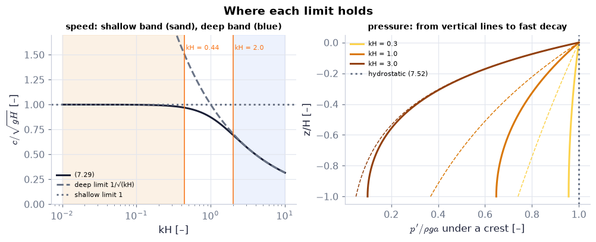

```
error of √(g/k) at kH = 2: 1.82%; error of √(gH) at kH = 0.44: 3.04%
```

```python
kH = np.logspace(-2, 1, 400)                              # depth ratio [–]
ratio = np.sqrt(np.tanh(kH)/kH)                           # c/√(gH) from (7.29)
fig, (a1, a2) = plt.subplots(1, 2, figsize=(9, 3.6))      # speed | pressure
a1.semilogx(kH, ratio, color=COLORS["ink"], lw=2, label="(7.29)")
a1.semilogx(kH, 1/np.sqrt(kH), "--", color=COLORS["muted"], label="deep limit 1/√(kH)")   # (7.45)/√(gH)
a1.axhline(1, ls=":", color=COLORS["muted"], label="shallow limit 1")                     # (7.49)
a1.axvspan(2, 10, color=COLORS["blue"], alpha=0.08); a1.axvspan(0.01, 0.44, color=COLORS["amber"], alpha=0.1)
for xv in (0.44, 2.0):                                    # the book's thresholds
    a1.axvline(xv, color=COLORS["orange"], lw=1); a1.text(xv*1.05, 1.55, f"kH = {xv}", fontsize=7, color=COLORS["orange"])
a1.set_ylim(0, 1.7); a1.set_xlabel("kH [–]"); a1.set_ylabel(r"$c/\sqrt{gH}$ [–]"); a1.legend(fontsize=7, loc="lower left")
a1.set_title("speed: shallow band (sand), deep band (blue)", fontsize=9)
zH = np.linspace(-1, 0, 200)                              # z/H [–]
for kh, cl in zip((0.3, 1.0, 3.0), ("#fcd34d", COLORS["amber"], "#92400e")):   # three depth ratios (amber shades)
    a2.plot(ch07.pressure_response(kh, zH, 1.0), zH, color=cl, lw=2, label=f"kH = {kh}")   # (7.31) with k = kH, H = 1
    a2.plot(np.exp(kh*zH), zH, "--", color=cl, lw=1)      # e^{kz} (7.48) for the same k
a2.axvline(1, ls=":", color=COLORS["muted"], label="hydrostatic (7.52)")
a2.set_xlabel(r"$p'/\rho g a$ under a crest [–]"); a2.set_ylabel("z/H [–]"); a2.legend(fontsize=7)
a2.set_title("pressure: from vertical lines to fast decay", fontsize=9)
fig.suptitle("Where each limit holds", fontweight="bold")
savefig(fig, "ch07", "c04_limits"); plt.show()
print("error of √(g/k) at kH = 2:", f"{1 - np.sqrt(np.tanh(2.0)):.2%};", "error of √(gH) at kH = 0.44:",
      f"{1 - np.sqrt(np.tanh(0.44)/0.44):.2%}")           # the book's '2 %' and '3 %'
```

**What you see.** Left: the speed curve leaves the shallow value near kH ≈ 0.4 and joins the deep curve near kH ≈ 2; right: the pressure profiles go from nearly vertical lines (kH = 0.3) to a fast decay (kH = 3), each close to its dashed $e^{kz}$ ghost in deep water.

**How to read it.** Read the error of a limit as the gap between the solid curve and the ghost: 3 % at kH = 0.44, 1.8 % at kH = 2 (printed under the figure).

**What would change if…** …the depth doubled at fixed λ: every point slides right by log 2 — the wave becomes "deeper".

> 🔁 **Tools from earlier chapters used here** (see `knowledge/primers.md`)
- **slider_figure** — computes every slider position in Python up front, so the plotly figure keeps working on the published page (Ch. 1 P17).
- **live widgets** — ipywidgets sliders that re-run a function while a kernel runs; frozen on the page (Ch. 1 P47).
- **show_viz** — embeds a chapter explainer in the notebook (Ch. 1 P18).
- **explainer tabs (Walkthrough, Explore, Explain, Derivation, Equations, Code, Check)** — start with the Walkthrough, play in Explore, read every number worked out in Explain, step through the Derivation, finish with Check yourself (Ch. 1 P18).

```python
lam = np.logspace(-1, 6, 150)                             # wavelengths 0.1 m … 1000 km [m]
fig = slider_figure(lambda H: {"finite depth (7.29)": (lam, ch07.phase_speed(2*np.pi/lam, H)),   # for each H: c(λ) from (7.29) …
                               "deep limit (7.45)": (lam, np.sqrt(G*lam/(2*np.pi))),   # … the deep line √(gλ/2π) …
                               "shallow limit (7.49)": (lam, np.sqrt(G*H) + 0*lam)},   # … and the shallow plateau √(gH)
                    "H", np.logspace(np.log10(0.5), np.log10(5000), 20 if not FAST else 10), unit="m",   # slider: depth 0.5 m … 5 km
                    xlabel="wavelength λ [m]", ylabel="c [m/s]", title="Depth only matters for waves longer than about 3H")   # labels and message
logaxes(fig, x=(0.1, 1e6), y=(0.3, 400))                  # both axes logarithmic, fixed
recolor(fig, {"finite depth (7.29)": COLORS["ink"], "deep limit (7.45)": COLORS["muted"],   # colours by meaning …
              "shallow limit (7.49)": COLORS["muted"]}, dashes={"deep limit (7.45)": "dash", "shallow limit (7.49)": "dot"})   # … deep dashed, shallow dotted
fig.show()   # draw (works on the page: no kernel needed)
```

[interactive chart not shown]

**What you see.** Drag H: the black curve follows the dashed deep line for short waves and the dotted shallow plateau $\sqrt{gH}$ for long ones; the corner between them sits where kH is between about 0.44 and 2, i.e. λ between about 3H (H > 0.32λ: deep) and 14H (H < 0.07λ: shallow). Every slider position was computed up front, so the figure works on the page.

**What would change if…** g were smaller (a lighter planet): every curve would drop by the same factor $\sqrt g$, but the corner would stay at λ ≈ 3H–14H, because it depends only on kH.

```python
z = np.linspace(-20, 0, 80)                              # depth below the still surface, H = 20 m [m]
fig = slider_figure(lambda lam: {"cosh ratio (7.31)": (ch07.pressure_response(2*np.pi/lam, z, 20.0), z),   # for each λ: p′/ρga from (7.31) …
                                 "hydrostatic (7.52)": (1 + 0*z, z),   # … the hydrostatic line …
                                 "deep e^{kz} (7.48)": (np.exp(2*np.pi/lam*z), z)},   # … and the deep-water e^{kz}
                    "λ", np.logspace(0, 3, 20 if not FAST else 10), unit="m", xlabel="p′/ρga [–]", ylabel="z [m]",   # slider: λ from 1 m to 1 km
                    title="When a bottom gauge sees the wave (H = 20 m)", xrange=(0, 1.05), yrange=(-20, 0))   # fixed axes
recolor(fig, {"cosh ratio (7.31)": COLORS["amber"], "hydrostatic (7.52)": COLORS["muted"], "deep e^{kz} (7.48)": COLORS["muted"]},   # pressure amber, limits grey
        dashes={"hydrostatic (7.52)": "dot", "deep e^{kz} (7.48)": "dash"})   # limit styles
fig.show()   # draw (works on the page: no kernel needed)
```

[interactive chart not shown]

**What you see.** Short waves (left end of the slider) leave the bottom untouched; from λ ≈ 100 m on, the amber profile straightens toward the hydrostatic line: the whole column feels the wave.

**What would change if…** the gauge sat on a 100 m deep bottom: the amber profile would need waves about five times longer before it straightened, so the gauge would miss most wind waves and see only swell and tides.

> ▶️ **Live cell.** The widget below needs a running Python kernel. On the web page it is frozen — open this notebook in Colab (button at the top) or run it locally to drag the sliders.

```python
_ = live(lambda lam=100.0, H=20.0: print({k_: (round(v, 4) if isinstance(v, float) else v)            # every number of E1
                                     for k_, v in ch07.dispersion_state(lam, H).items()}),
     lam=(1.0, 2000.0, 1.0), H=(0.5, 4000.0, 0.5))       # sliders: wavelength [m], depth [m]
```

▶️ **Live cell.** These sliders need a running Python kernel, so they are frozen on this page. Press **Open in Colab** at the top (or run the notebook locally) to use them.

**What does the code above do?**

`dispersion_state(λ, H)` returns k, kH, ω, T, c, c_g, both limits and their errors, the regime, the fraction of the surface pressure felt at the bottom, and how long crests and energy need to cross 1000 km. The plotly slider above carries the same idea on the page.

#### 🎮 Interactive: Why long waves outrun short ones

**Why interactive rather than a static figure:** Three linked pictures of one number: the tank with a crest marker moving at c and the pressure fading with depth, the c(λ) curve with its two limits, and the pressure profile. Dragging λ across kH ≈ 0.3…3 moves all three at once — a static figure can show only one.

**What to try:**

- Start at the *wind swell* preset, then drag H down to 10 m: watch λ and c shrink while T stays 10 s.
- Choose *tsunami*: the status says shallow — $c=\sqrt{gH}$ *(7.49)* whatever λ you pick.
- Click the tank at the bottom for the pressure arithmetic; compare λ = 50 m and λ = 500 m.
- Open the Derivation tab (D06) and step to 'cancel the cosine'.

```python
show_viz("ch07", "dispersion_relation")   # full-width explainer; ⤢ Full screen for more room
```

🎮 Interactive 1/9 Why do long waves outrun short ones? Open alone ↗

[interactive chart not shown]

> ⚠️ **Common confusion:** "deep water" is not a depth in metres. A 10 m pond is deep for 1 m ripples and shallow for a 1 km seiche; the ocean is deep for swell and shallow for tides. Always compare H with λ.

**What would change if…** …the Earth rotated fast enough to matter (periods of hours)? Long waves in Ch. 13 add the Coriolis frequency f: $\omega^2=f^2+gHk^2$ (Poincaré waves) — this section's $c=\sqrt{gH}$ *(7.49)* is the limit f → 0.

> 🔁 **Recap — Path lines** (Ch. 3 §3.2). A fluid particle's path $x_p(t)$ obeys $\frac{dx_p}{dt}=u(x_p,z_p,t),\ \frac{dz_p}{dt}=w(x_p,z_p,t)$ *(7.32)* — the path-line equation $d\mathbf r/dt=\mathbf u(\mathbf r,t)$ *(3.8)*. Ch. 3 Example 3.1 followed a particle in an oscillating flow and found a closed circle, as we are about to under a wave.

```python
r = ch03.example_3_1(0.5)                                 # Ch. 3 Example 3.1 at t′ = 0.5 s (ξ₀ = 1 m, ω = 1 rad/s)
print("path line of Example 3.1: a circle of radius", r["radius"], "m")   # oscillating flow → closed loop
```

```
path line of Example 3.1: a circle of radius 1.0 m
```

**What does the code above do?**

Ch. 3's example of a flow that oscillates in time: its path lines are closed loops, although the streamlines at any instant are straight — the same distinction C05 needs for the water under a wave.

### 🧩 Particle orbits: closed ellipses `C05`

*The question:* If the wave moves but the water does not travel, what path does a water parcel follow?

*In one line:* $\frac{\xi^2}{A^2}+\frac{\zeta^2}{B^2}=1,\ A=a\frac{\cosh k(z_0+H)}{\sinh kH},\ B=a\frac{\sinh k(z_0+H)}{\sinh kH}$ *(7.36)*

#### The problem in plain words

Throw a cork on swell and release a neutrally buoyant float a few metres down: both go round and come back. Divers feel the surge forward under a crest and backward under a trough. We want the shape of those loops at every depth — the picture behind Stokes drift (C12), ocean floats (Ch. 13) and sediment moved to and fro on the sea bed.

#### The idea

```
deep water:     circles of radius a e^{kz₀}, shrinking fast with depth
intermediate:   ellipses, flatter as you go down
shallow water:  flat ellipses of the same width a/kH at every depth, height → 0 at the bottom
all parcels of one vertical column are at the same point of their loops (in phase); clockwise for a wave to the right
```

📝 **Note.** **The path lines under the wave** `N27` — With the velocities $u=a\omega\frac{\cosh k(z+H)}{\sinh kH}\cos(kx-\omega t),\ w=a\omega\frac{\sinh k(z+H)}{\sinh kH} \sin(kx-\omega t)$ *(7.27)* inserted, the path lines are nonlinear in the unknown position:

$$ \frac{dx_p}{dt}=a\omega\frac{\cosh k(z_p+H)}{\sinh kH}\cos(kx_p-\omega t),\ \frac{dz_p}{dt}=a\omega\frac{\sinh k(z_p+H)}{\sinh kH}\sin(kx_p-\omega t) \qquad \text{(7.33)} $$

> 🔁 **Tools from earlier chapters used here** (see `knowledge/primers.md`) — antiderivatives of sin and cos are worked in D10 steps 6–7
- **multivariable Taylor expansion** — $u(x_0+\xi,z_0+\zeta)\approx u(x_0,z_0)+\xi u_x+\zeta u_z$, error ∝ |(ξ, ζ)|² (Ch. 3 P98).

#### 🧮 Derivation — Linearised particle orbits `D10` (Eq. 7.35a: $\xi\cong-a\frac{\cosh k(z_0+H)}{\sinh kH}\sin(kx_0-\omega t)$)

**What we want to show.** Find the path of one water parcel under the wave, to first order in the amplitude.

**Assumptions.** a ≪ λ (steps 3–4); the mean position is the time average of the path (step 8).

**The plan.**

1. Insert the velocities.
2. Split the position into mean + small excursion.
3. Freeze the right sides at the mean position.
4. Integrate in time.

**Tools we use** (each explained before this point): path lines (R08) · multivariable Taylor (P98) · antiderivatives of sin and cos.

**We start from**

$$ \frac{dx_p}{dt}=u(x_p,z_p,t),\ \frac{dz_p}{dt}=w(x_p,z_p,t)\ \text{(7.32)},\qquad u=a\omega\frac{\cosh k(z+H)}{\sinh kH}\cos(kx-\omega t),\ w=a\omega\frac{\sinh k(z+H)}{\sinh kH}\sin(kx-\omega t)\ \text{(7.27)} $$

*In words:* each parcel moves with the local velocity of the linear wave

**Step 1 of 9 — Insert the velocities.**

$$ \begin{array}{l}\frac{dx_p}{dt}=a\omega\frac{\cosh k(z_p+H)}{\sinh kH}\cos(kx_p-\omega t) \\ \frac{dz_p}{dt}=a\omega\frac{\sinh k(z_p+H)}{\sinh kH}\sin(kx_p-\omega t)\ \text{(7.33)}\end{array} $$

- *Why we can do this:* (7.32), $\frac{dx_p}{dt}=u(x_p,z_p,t),\ \frac{dz_p}{dt}=w(x_p,z_p,t)$ says a parcel moves with the local velocity; (7.27), $u=a\omega\frac{\cosh k(z+H)}{\sinh kH}\cos(kx-\omega t),\ w=a\omega\frac{\sinh k(z+H)}{\sinh kH}\sin(kx-\omega t)$ gives it.
- *In words:* exact but nonlinear equations for the path.

**Step 2 of 9 — Split the position.**

$$ x_p=x_0+\xi(t),\quad z_p=z_0+\zeta(t) $$

- *Why we can do this:* We expect the parcel to stay near a fixed mean position (x₀, z₀), with excursions ξ, ζ of order a, small compared with λ.
- *In words:* the parcel wanders slightly round a fixed point.

**Step 3 of 9 — Size the velocity change over an excursion.**

$$ u(x_0+\xi,\ldots)-u(x_0,\ldots)\approx\xi\frac{\partial u}{\partial x}\sim a\cdot k\cdot a\omega $$

- *Why we can do this:* First-order Taylor (P98): the field changes on the scale 1/k, so the difference is ka times u itself.
- *In words:* moving by ξ changes the velocity felt by only ka of it.

**Step 4 of 9 — Freeze the argument.**

$$ \frac{d\xi}{dt}\cong a\omega\frac{\cosh k(z_0+H)}{\sinh kH}\cos(kx_0-\omega t)\ \text{(7.34a)} $$

- *Why we can do this:* Drop the O(ka) correction of step 3 (linearisation); dx_p/dt = dξ/dt because x₀ is fixed.
- *In words:* the parcel feels the velocity at its mean position.

**Step 5 of 9 — The same for the vertical.**

$$ \frac{d\zeta}{dt}\cong a\omega\frac{\sinh k(z_0+H)}{\sinh kH}\sin(kx_0-\omega t)\ \text{(7.34b)} $$

- *Why we can do this:* Same move on the z-equation of (7.33), $\frac{dx_p}{dt}=a\omega\frac{\cosh k(z_p+H)}{\sinh kH}\cos(kx_p-\omega t),\ \frac{dz_p}{dt}=a\omega\frac{\sinh k(z_p+H)}{\sinh kH}\sin(kx_p-\omega t)$.
- *In words:* the vertical velocity at the mean position.

**Step 6 of 9 — Integrate the horizontal equation.**

$$ \xi=-a\frac{\cosh k(z_0+H)}{\sinh kH}\sin(kx_0-\omega t)+\xi_c $$

- *Why we can do this:* ∫cos(kx₀ − ωt)dt = −sin(kx₀ − ωt)/ω, since d/dt sin(kx₀ − ωt) = −ω cos(…); aω/ω = a.
- *In words:* the horizontal excursion oscillates.

**Step 7 of 9 — Integrate the vertical equation.**

$$ \zeta=a\frac{\sinh k(z_0+H)}{\sinh kH}\cos(kx_0-\omega t)+\zeta_c $$

- *Why we can do this:* ∫sin(kx₀ − ωt)dt = cos(kx₀ − ωt)/ω.
- *In words:* the vertical excursion oscillates a quarter period out of step.

**Step 8 of 9 — Set the constants to zero.**

$$ \xi_c=\zeta_c=0\ \text{⇒ (7.35a, 7.35b)} $$

- *Why we can do this:* (x₀, z₀) is by definition the mean position; the oscillating parts already average to zero, so any constant would shift the mean.
- *In words:* the parcel circles its own mean position.

**Step 9 of 9 — Check nothing grows.**

$$ \lvert\xi\rvert\le a\coth kH,\ \lvert\zeta\rvert\le a $$

- *Why we can do this:* No term grows with t (no secular term), so ξ, ζ stay small and the freezing of step 4 stays valid forever. The dropped ξu_x returns at second order as Stokes drift (C12).
- *In words:* the approximation does not wear out.

**Result**

$$ \xi\cong-a\frac{\cosh k(z_0+H)}{\sinh kH}\sin(kx_0-\omega t)\ \text{,}\ \zeta\cong a\frac{\sinh k(z_0+H)}{\sinh kH}\cos(kx_0- \omega t)\ \text{(7.35a, 7.35b).} $$

**What it means.** Every parcel oscillates about a fixed point; parcels of one vertical column are in phase.

**Check it.** Units: m ✓. dξ/dt of the result returns (7.34a), $\frac{d\xi}{dt}\cong a\omega\frac{\cosh k(z_0+H)}{\sinh kH}\cos(kx_0-\omega t)$ ✓. RK4 on (7.34), $\frac{d\xi}{dt}\cong a\omega\frac{\cosh k(z_0+H)}{\sinh kH}\cos(kx_0-\omega t),\ \frac{d\zeta}{dt}\cong a\omega\frac{\sinh k(z_0+H)}{\sinh kH}\sin(kx_0-\omega t)$ (C05 from scratch) matches to 1e-6 ✓.

> ⚠️ **Common confusion (traps in `D10`):** The minus sign in ξ from ∫cos; putting the constants of integration anywhere but zero; thinking the dropped term is always negligible (its average is the drift, C12).

📝 **Note.** **Frozen arguments and the excursions** `N28, N29` — Freezing the right sides at the mean position gives $\frac{d\xi}{dt}\cong a\omega\frac{\cosh k(z_0+H)}{\sinh kH} \cos(kx_0-\omega t)$ *(7.34a)* and $\frac{d\zeta}{dt}\cong a\omega\frac{\sinh k(z_0+H)}{\sinh kH}\sin(kx_0-\omega t)$ *(7.34b)* (D10 steps 4–5), and one integration gives the excursions $\xi\cong-a\frac{\cosh k(z_0+H)}{\sinh kH}\sin(kx_0- \omega t)$ *(7.35a)*, $\zeta\cong a\frac{\sinh k(z_0+H)}{\sinh kH}\cos(kx_0-\omega t)$ *(7.35b)* — purely oscillatory, so the assumption "the parcel stays near $(x_0,z_0)$" is self-consistent.

> 🔁 **Tools from earlier chapters used here** (see `knowledge/primers.md`) — sin² + cos² = 1 is D11 step 3
- **ellipse, semi-axes, foci** — an ellipse $x^2/A^2+y^2/B^2=1$ with A ≥ B has its foci $\sqrt{A^2-B^2}$ from the centre; a linear map of a circle is an ellipse (Ch. 3 P104).

#### 🧮 Derivation — The orbits are ellipses: axes, foci, sense `D11` (Eq. 7.36: $\frac{\xi^2}{A^2}+\frac{\zeta^2}{B^2}=1,\ A=a\frac{\cosh k(z_0+H)}{\sinh kH},\ B=a\frac{\sinh k(z_0+H)}{\sinh kH}$)

**What we want to show.** Show that each parcel traces an ellipse, find its axes and foci, and its direction of travel.

**Assumptions.** Linear orbits (D10); z₀ above the bottom.

**The plan.**

1. Name the amplitudes.
2. Normalise, square, add.
3. Read off the shape and the sense.

**Tools we use** (each explained before this point): sin² + cos² = 1 · ellipse geometry (P104) · cosh² − sinh² = 1 (P168).

**We start from**

$$ \xi\cong-a\frac{\cosh k(z_0+H)}{\sinh kH}\sin(kx_0-\omega t)\ \text{(7.35a)},\qquad \zeta\cong a\frac{\sinh k(z_0+H)}{\sinh kH}\cos(kx_0-\omega t)\ \text{(7.35b)} $$

*In words:* the linear excursions of D10

**Step 1 of 6 — Name the semi-axes.**

$$ A=a\frac{\cosh k(z_0+H)}{\sinh kH},\quad B=a\frac{\sinh k(z_0+H)}{\sinh kH} $$

- *Why we can do this:* The amplitudes of ξ and ζ in (7.35), $\xi\cong-a\frac{\cosh k(z_0+H)}{\sinh kH}\sin(kx_0-\omega t),\ \zeta\cong a\frac{\sinh k(z_0+H)}{\sinh kH}\cos(kx_0-\omega t)$; they depend on the depth only.
- *In words:* half-width and half-height of the loop.

**Step 2 of 6 — Divide by the semi-axes.**

$$ \frac\xi A=-\sin(kx_0-\omega t),\quad\frac\zeta B=\cos(kx_0-\omega t) $$

- *Why we can do this:* A, B > 0 above the bottom, so dividing is allowed.
- *In words:* two normalised oscillations.

**Step 3 of 6 — Square and add.**

$$ \frac{\xi^2}{A^2}+\frac{\zeta^2}{B^2}=\sin^2+\cos^2=1\ \text{(7.36)} $$

- *Why we can do this:* sin² + cos² = 1 removes the phase — the time.
- *In words:* every parcel traces an ellipse.

**Step 4 of 6 — Compare the axes.**

$$ \frac BA=\tanh k(z_0+H)\le1 $$

- *Why we can do this:* The ratio of step 1's expressions; tanh < 1, → 1 in deep water (circles), → 0 at the bottom (a flat line).
- *In words:* the loops flatten with depth.

**Step 5 of 6 — Find the focal distance.**

$$ \sqrt{A^2-B^2}=\frac{a}{\sinh kH}\sqrt{\cosh^2-\sinh^2}=\frac{a}{\sinh kH} $$

- *Why we can do this:* An ellipse with A ≥ B has foci √(A² − B²) from its centre; cosh² − sinh² = 1 (P168).
- *In words:* the foci are the same distance apart at every depth.

**Step 6 of 6 — Find the sense of rotation.**

$$ \zeta=+B\Rightarrow\frac{d\xi}{dt}=+a\omega\frac{\cosh k(z_0+H)}{\sinh kH}>0 $$

- *Why we can do this:* ζ = B when cos(kx₀ − ωt) = 1; then (7.34a), $\frac{d\xi}{dt}\cong a\omega\frac{\cosh k(z_0+H)}{\sinh kH}\cos(kx_0-\omega t)$ gives a forward velocity. Forward at the top, backward at the bottom: clockwise with x right and z up.
- *In words:* parcels go round clockwise for a wave travelling to the right.

**Result**

$$ \begin{array}{l}\xi^2/A^2+\zeta^2/B^2=1\ \text{(7.36) with the axes of step 1; foci a/sinh kH from the centre;} \\ \text{clockwise.}\end{array} $$

**What it means.** The picture of what water does under a wave; the constant focal distance and the in-phase columns are visible in the A1 animation.

**Check it.** kH = 3 at the surface: A = 1.005a, B = a ✓ (the code cell after the tiny example of C05); kH = 0.3: A = 3.43a ✓.

> ⚠️ **Common confusion (traps in `D11`):** Squaring before dividing by the axes; calling the rotation anticlockwise (it depends on the direction of travel); forgetting that B = 0 at the bottom (the bottom parcel only slides).

📝 **Note.** **Deep water** `N40, N41` — (kH > 2): $\xi\cong-ae^{kz_0}\sin(kx_0-\omega t),\ \zeta\cong ae^{kz_0}\cos(kx_0-\omega t)$ *(7.46)* — circles whose radius halves every $\ln2/k=0.11\lambda$ of depth; the velocity $u=a\omega e^{kz}\cos(kx-\omega t),\ w=a\omega e^{kz}\sin(kx- \omega t)$ *(7.47)* turns clockwise at ω with constant size $a\omega e^{kz}$.

📝 **Note.** **Shallow water** `N44, N45` — (kH ≪ 1): $\xi\cong-\frac a{kH}\sin(kx_0-\omega t),\ \zeta\cong a\big(1+\frac{z_0}H\big)\cos(kx_0-\omega t)$ *(7.50)* — flat ellipses of width a/kH at every depth; $u=\frac{a\omega}{kH}\cos(kx-\omega t),\ w=a\omega\big(1+\frac zH\big) \sin(kx-\omega t)$ *(7.51)*, so $w/u\lesssim kH$ (0.2 for kH = 0.2).

#### ✏️ Tiny example: orbits under a 20 m wave in 50 m of water

1. $k=2\pi/20=0.314$ rad/m, $kH=15.7$: deep. Take a = 0.1 m, so ka = 0.031 — small, as linear theory needs.
2. Radius $ae^{kz_0}$: 10 cm at the surface.
3. At $z_0=-2$ m: $e^{-0.628}=0.533$ → 5.3 cm.
4. At $z_0=-10$ m (half a wavelength): $e^{-\pi}=0.043$ → 4 mm.
5. The bottom (−50 m) does not feel the wave: $e^{-15.7}\approx10^{-7}$.

Every radius is proportional to a; the code below uses a = 1 m as a unit amplitude, so its lengths are "per metre of a".

> 🔁 **Tools from earlier chapters used here** (see `knowledge/primers.md`)
- **scipy.integrate.solve_ivp** — adaptive Runge–Kutta that picks its own steps to meet a tolerance (Ch. 1 P31).
- **solve_ivp options and DOP853 tolerances** — `method="DOP853"` is an 8th-order scheme, `rtol`/`atol` set the accuracy and `t_eval` the output times (Ch. 3 P94); tight tolerances make a tiny drift trustworthy.

```python
for kH in (3.0, 1.0, 0.3):                                # k = 1 rad/m, so H = kH [m]; a = 1 m
    ax_ = ch07.orbit_semi_axes(np.array([0.0, -kH/2]), 1.0, 1.0, kH)   # (7.36) at the surface and at mid-depth
    print(f"kH = {kH}: A = {ax_['A']}, B = {ax_['B']} m; focal half-distance a/sinh kH = {ax_['focal_half']:.4f} m")
T1 = 2*np.pi/ch07.omega_gravity(1.0, 1.0)                 # period for k = 1 rad/m, H = 1 m [s]
tt = np.linspace(0, 8*T1, 801)                            # eight whole periods [s]
p_lin = ch07.particle_path(0.0, -0.5, tt, 0.05, 1.0, 1.0, model="linear")   # (7.34): frozen at the mean position
p_ex = ch07.particle_path(0.0, -0.5, tt, 0.05, 1.0, 1.0, model="exact")     # (7.33): the true path line
print(f"after 8 periods: linear path moved {p_lin['x'][-1] - p_lin['x'][0]:.1e} m, exact path {p_ex['x'][-1] - p_ex['x'][0]:.4f} m")
```

```
kH = 3.0: A = [1.005  0.2348], B = [1.     0.2125] m; focal half-distance a/sinh kH = 0.0998 m
kH = 1.0: A = [1.313  0.9595], B = [1.     0.4434] m; focal half-distance a/sinh kH = 0.8509 m
kH = 0.3: A = [3.4327 3.3209], B = [1.     0.4944] m; focal half-distance a/sinh kH = 3.2839 m
```

```
after 8 periods: linear path moved 3.1e-13 m, exact path 0.0670 m
```

**What does the code above do?**

1. The semi-axes of (7.36), $\frac{\xi^2}{A^2}+\frac{\zeta^2}{B^2}=1,\ A=a\frac{\cosh k(z_0+H)}{\sinh kH},\ B=a\frac{\sinh k(z_0+H)}{\sinh kH}$ at the surface and at mid-depth: for kH = 3, A = 1.005 and B = 1.000 m at the surface (almost a circle), 0.235 and 0.213 m at mid-depth; kH = 1: 1.313/1.000 and 0.960/0.443; kH = 0.3: 3.433/1.000 and 3.321/0.494. The focal half-distance a/sinh kH — 0.0998, 0.851, 3.284 m — is the same at every depth.
2. `particle_path` integrates the frozen-argument equations (7.34), $\frac{d\xi}{dt}\cong a\omega\frac{\cosh k(z_0+H)}{\sinh kH}\cos(kx_0-\omega t),\ \frac{d\zeta}{dt}\cong a\omega\frac{\sinh k(z_0+H)}{\sinh kH}\sin(kx_0-\omega t)$ or the exact path lines (7.33), $\frac{dx_p}{dt}=a\omega\frac{\cosh k(z_p+H)}{\sinh kH}\cos(kx_p-\omega t),\ \frac{dz_p}{dt}=a\omega\frac{\sinh k(z_p+H)}{\sinh kH}\sin(kx_p-\omega t)$ with `solve_ivp` (DOP853 and tight tolerances, so the tiny drift is not numerical error). After eight whole periods the linear parcel is back where it started; the exact one has crept forward by several centimetres — the Stokes drift of C12.

> 🔁 **Tools from earlier chapters used here** (see `knowledge/primers.md`)
- **RK4 by hand** — four slope samples per step weighted 1-2-2-1; error ∝ Δt⁴ (Ch. 3 P95).

```python
a, k, H, x0, z0 = 0.05, 1.0, 1.0, 0.0, -0.5               # wave and mean position [m, rad/m, m, m, m]
w = ch07.omega_gravity(k, H); T = 2*np.pi/w                # ω [rad/s] and period [s]
Ca = np.cosh(k*(z0 + H))/np.sinh(k*H); Sa = np.sinh(k*(z0 + H))/np.sinh(k*H)   # the depth ratios of (7.34)
rhs = lambda t: np.array([a*w*Ca*np.cos(k*x0 - w*t), a*w*Sa*np.sin(k*x0 - w*t)])   # (7.34a, b): dξ/dt, dζ/dt [m/s]
dt, n = T/400, 400                                        # 400 RK4 steps over one period
y = np.array(ch07.orbit_linear(x0, z0, 0.0, a, k, H))     # start on the orbit: (ξ, ζ) at t = 0 [m]
mine = [y.copy()]                                          # the RK4 path
for i in range(n):                                         # classic RK4 (1-2-2-1)
    t = i*dt
    k1 = rhs(t); k2 = rhs(t + dt/2); k3 = rhs(t + dt/2); k4 = rhs(t + dt)   # slopes (the right side depends on t only)
    y = y + dt*(k1 + 2*k2 + 2*k3 + k4)/6
    mine.append(y.copy())
mine = np.array(mine)                                      # (n + 1, 2)
lib = np.array(ch07.orbit_linear(x0, z0, np.arange(n + 1)*dt, a, k, H)).T   # (7.35) at the same times
print("largest difference:", np.abs(mine - lib).max(), "m")
assert np.allclose(mine, lib, atol=1e-6)                   # RK4 draws the same ellipse as the closed form
```

```
largest difference: 1.0141609774194649e-12 m
```

RK4 on the frozen-argument equations (7.34), $\frac{d\xi}{dt}\cong a\omega\frac{\cosh k(z_0+H)}{\sinh kH}\cos(kx_0-\omega t),\ \frac{d\zeta}{dt}\cong a\omega\frac{\sinh k(z_0+H)}{\sinh kH}\sin(kx_0-\omega t)$ draws the same ellipse as the closed form (7.35), $\xi\cong-a\frac{\cosh k(z_0+H)}{\sinh kH}\sin(kx_0-\omega t),\ \zeta\cong a\frac{\sinh k(z_0+H)}{\sinh kH}\cos(kx_0-\omega t)$.

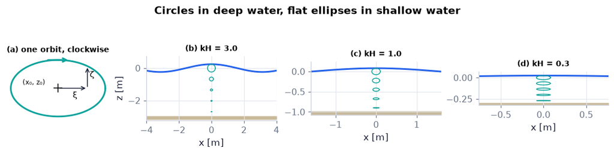

```python
fig, axs = plt.subplots(1, 4, figsize=(10, 3.4), gridspec_kw=dict(width_ratios=[0.8, 1, 1, 1]))
s = np.linspace(0, 2*np.pi, 200)                          # parameter round an ellipse
A0, B0 = 1.0, 0.6                                         # (a) a schematic orbit
axs[0].plot(A0*np.cos(s), B0*np.sin(s), color=COLORS["teal"], lw=2)
axs[0].plot(0, 0, "k+", ms=10); axs[0].text(-0.75, 0.08, "(x₀, z₀)", fontsize=8)
ph = 0.9                                                  # a phase along the orbit
px, pz = A0*np.cos(ph), B0*np.sin(ph)                     # the parcel's position relative to the mean
axs[0].annotate("", xy=(px, 0), xytext=(0, 0), arrowprops=dict(arrowstyle="->", color=COLORS["ink"]))   # ξ
axs[0].annotate("", xy=(px, pz), xytext=(px, 0), arrowprops=dict(arrowstyle="->", color=COLORS["ink"]))  # ζ
axs[0].text(px/2, -0.2, "ξ", fontsize=10); axs[0].text(px + 0.05, pz/2, "ζ", fontsize=10)
axs[0].annotate("", xy=(0.25, B0), xytext=(-0.25, B0), arrowprops=dict(arrowstyle="->", color=COLORS["teal"], lw=2))   # clockwise
axs[0].set_title("(a) one orbit, clockwise", fontsize=9); axs[0].set_aspect("equal"); axs[0].axis("off")
for axp, kH, tag in zip(axs[1:], (3.0, 1.0, 0.3), "bcd"):  # three depth ratios, k = 1 rad/m
    H = kH; a = 0.08*H                                     # depth [m] and an amplitude drawn at 8 % of the depth [m]
    xw = np.linspace(-1.2*H - 0.4, 1.2*H + 0.4, 200)        # window [m]
    axp.plot(xw, a*np.cos(xw), color=COLORS["blue"], lw=2)  # the surface at t = 0
    axp.fill_between(xw, -1.06*H, -H, color="#c8b99a")     # bottom
    z0s = np.linspace(-0.9*H, 0.0, 5)                      # five mean depths [m]
    ax_ = ch07.orbit_semi_axes(z0s, a, 1.0, H)             # (7.36) semi-axes at those depths
    orbit_ghosts(axp, 0.0, z0s, ax_["A"], ax_["B"])        # the orbits (teal)
    axp.set_aspect("equal"); axp.set_ylim(-1.08*H, 0.25*H); axp.set_xlim(xw[0], xw[-1])
    axp.set_title(f"({tag}) kH = {kH}", fontsize=9); axp.set_xlabel("x [m]")
axs[1].set_ylabel("z [m]")
fig.suptitle("Circles in deep water, flat ellipses in shallow water", fontweight="bold", y=0.9)
savefig(fig, "ch07", "c05_orbits"); plt.show()
```

**What you see.** (a) one orbit with the mean position $(x_0,z_0)$ and the excursion (ξ, ζ), travelled clockwise; (b)–(d) the orbits at five depths for kH = 3, 1, 0.3 (our remake of Figs. 7.3 and 7.4 `N169`, `N170`): circles that shrink fast with depth, ellipses, flat ellipses reaching the bottom.

**How to read it.** In (d) the horizontal axis is almost the same at every depth (a/kH) and the vertical axis falls linearly to zero at the bottom, as $\zeta\cong a\big(1+\frac{z_0}H\big)\cos(kx_0-\omega t)$ *(7.50)* says.

**What would change if…** …a doubled: every orbit doubles, the shapes do not change (linear theory) — until ka ~ 0.3, when the loops open (C12).

📝 **Note.** **The stream function of the wave** `N30` — Integrating $u=\partial\psi/\partial z$ in z (and checking $-\partial\psi/\partial x=w$) gives the stream function below (the convention of Ch. 4 §4.3 with y → z): ψ = 0 on the bottom and on the vertical lines below the zeros of η. Under a crest the water moves forward at every depth, under a trough backward. The code differentiates ψ numerically with Ch. 4's tool and gets the velocities (7.27), $u=a\omega\frac{\cosh k(z+H)}{\sinh kH}\cos(kx-\omega t),\ w=a\omega\frac{\sinh k(z+H)}{\sinh kH}\sin(kx-\omega t)$ back.

$$ \psi=\frac{a\omega}{k}\frac{\sinh k(z+H)}{\sinh kH}\cos(kx-\omega t) \qquad \text{(7.37)} $$

```python
psi = lambda x, z: ch07.wave_fields(x, z, 0.0, 0.05, 1.0, H=2.0)["psi"]   # (7.37) at t = 0 [m²/s]
u, w = streamfunction.velocity_from_streamfunction_2d(psi, 0.4, -0.7)     # Ch. 4: u = ∂ψ/∂z, w = −∂ψ/∂x (y ↦ z)
f = ch07.wave_fields(0.4, -0.7, 0.0, 0.05, 1.0, H=2.0)                    # (7.27) directly
print(u, w, "|", f["u"], f["w"])                                          # equal to ~1e-10 m/s
```

```
0.07696167530074627 0.028039501664273155 | 0.07696167529936658 0.028039501665098537
```

**What does this show?** Differentiating the stream function $\psi=\frac{a\omega}{k}\frac{\sinh k(z+H)}{\sinh kH}\cos(kx-\omega t)$ *(7.37)* numerically (u = ∂ψ/∂z, w = −∂ψ/∂x, Ch. 4) gives u ≈ 0.0770 m/s and w ≈ 0.0280 m/s at (x, z) = (0.4, −0.7) m — the same numbers as the velocity formulas $u=a\omega\frac{\cosh k(z+H)}{\sinh kH}\cos(kx-\omega t),\ w=a\omega\frac{\sinh k(z+H)}{\sinh kH}\sin(kx-\omega t)$ *(7.27)* to about $10^{-12}$ m/s. So ψ really is the stream function of this wave.

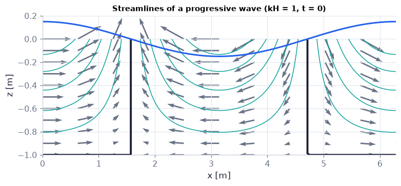

```python
k, H, a = 1.0, 1.0, 0.05                                  # kH = 1, amplitude 5 cm [rad/m, m, m]
xg, zg = np.linspace(0, 2*np.pi, 161 if not FAST else 81), np.linspace(-H, 0, 81 if not FAST else 41)
XX, ZZ = np.meshgrid(xg, zg)                              # grid over one wavelength and the depth
f = ch07.wave_fields(XX, ZZ, 0.0, a, k, H)                # ψ, u, w at t = 0
fig, ax = plt.subplots(figsize=(7, 3.2))                  # one panel
levels = np.linspace(-np.abs(f["psi"]).max(), np.abs(f["psi"]).max(), 13)   # ψ levels [m²/s]
ax.contour(XX, ZZ, f["psi"], levels=levels, colors=[COLORS["teal"]], linewidths=1)   # streamlines
ax.contour(XX, ZZ, f["psi"], levels=[0.0], colors=[COLORS["ink"]], linewidths=2.5)   # ψ = 0 (bold)
sl = (slice(None, None, 8), slice(None, None, 16))        # a sparse set of arrows
ax.quiver(XX[sl], ZZ[sl], f["u"][sl], f["w"][sl], color=COLORS["muted"], width=0.004)   # (u, w)
ax.plot(xg, 3*f["eta"][-1], color=COLORS["blue"], lw=2)   # the surface (height ×3 for visibility)
ax.set_xlabel("x [m]"); ax.set_ylabel("z [m]"); ax.set_ylim(-H, 0.2)
ax.set_title("Streamlines of a progressive wave (kH = 1, t = 0)", fontsize=10)
savefig(fig, "ch07", "c05_streamlines"); plt.show()
```

**What you see.** Loops of ψ that start and end on the surface, forward flow under the crest (x = 0, 2π) and backward flow under the trough (x = π); bold ψ = 0 lines along the bottom and below the zeros of η (our remake of Fig. 7.5 `N171`).

**How to read it.** Streamlines are a snapshot of the velocity field; the particles themselves go round the orbits of the previous figure.

**What would change if…** …t advanced by T/4: the whole pattern slides a quarter wavelength right (it moves with the wave).

> 🔁 **Tools from earlier chapters used here** (see `knowledge/primers.md`)
- **animate and show_animation** — `update(i)` moves the artists already drawn for frame i; `player="video"` plays smoothly (Ch. 1 P16).

```python
fig, axs = plt.subplots(1, 3, figsize=(10, 3.2))          # kH = 3, 1, 0.3 side by side
k = 1.0                                                   # wavenumber [rad/m]; λ = 2π m
arts = []                                                 # (surface, dots, column line, parameters) per panel
for axp, kH in zip(axs, (3.0, 1.0, 0.3)):
    H = kH; a = 0.06*H                                     # depth and amplitude [m]
    w = ch07.omega_gravity(k, H)                           # ω [rad/s]
    X0, Z0 = np.meshgrid(np.linspace(0.3, 2*np.pi - 0.3, 7), np.linspace(-0.85*H, -0.02*H, 5))   # 5 × 7 mean positions
    ax_ = ch07.orbit_semi_axes(Z0, a, k, H)                # semi-axes (7.36)
    orbit_ghosts(axp, X0.ravel(), Z0.ravel(), ax_["A"].ravel(), ax_["B"].ravel(), color=COLORS["teal"], lw=0.4, alpha=0.4)
    xs = np.linspace(0, 2*np.pi, 200)                      # surface points [m]
    (surf,) = axp.plot(xs, a*np.cos(k*xs), color=COLORS["blue"], lw=2)
    dots = axp.scatter(X0.ravel(), Z0.ravel(), s=10, color=COLORS["teal"], zorder=3)
    (col,) = axp.plot(X0[:, 3], Z0[:, 3], color=COLORS["ink"], lw=1)   # one vertical column joined by a line
    axp.fill_between(xs, -1.06*H, -H, color="#c8b99a")
    axp.set_xlim(0, 2*np.pi); axp.set_ylim(-1.08*H, 0.3*H); axp.set_title(f"kH = {kH}", fontsize=9); axp.set_xticks([])
    arts.append((surf, dots, col, X0, Z0, a, H, w, xs))
nf = 36 if not FAST else 18                                # frames over one period of each panel


def update(i):                                             # frame i: advance every panel by i/nf of its own period
    for surf, dots, col, X0, Z0, a, H, w, xs in arts:
        t = i/nf*2*np.pi/w                                 # time in this panel [s]
        surf.set_ydata(a*np.cos(k*xs - w*t))               # (7.2): the surface
        xi, ze = ch07.orbit_linear(X0, Z0, t, a, k, H)     # (7.35): every parcel's excursion
        dots.set_offsets(np.c_[(X0 + xi).ravel(), (Z0 + ze).ravel()])
        col.set_data(X0[:, 3] + xi[:, 3], Z0[:, 3] + ze[:, 3])   # the column moves as a whole
    return []   # nothing to blit


fig.suptitle("Parcels go round their orbits in phase down each column", fontsize=10)
show_animation(animate(update, frames=nf, fig=fig, interval=60))   # MP4 in the page (or a frame player)
```

[video not shown]

**What you see.** The surface (blue) moves right; every parcel (teal) goes round its faint orbit ghost; the black line joins one column of parcels — the `A1` animation.

**How to read it.** The column stays straight and swings as a whole: all its parcels are at the same point of their loops (in phase). In shallow water (right) the swing is almost purely horizontal.

**What would change if…** …the amplitude were not small? The loops would no longer close — the column would lean forward period by period (C12).

**What would change if…** …the amplitude were not small? The parcel is slightly further forward at the top of its loop, where the forward velocity is larger, than it is backward at the bottom: the loop does not close. That second-order creep is the Stokes drift of C12.

### 🧩 Wave energy, equipartition and the energy flux `C06`

*The question:* How much energy does a wave hold per square metre of sea — and how fast is it delivered to a beach?

*In one line:* $E=E_p+E_k=\rho g\overline{\eta^2}=\tfrac12\rho ga^2$ *(7.42)* · $F=\Big[\tfrac12\rho ga^2\Big]\Big[\frac c2\Big(1+\frac{2kH}{\sinh2kH}\Big)\Big]$ *(7.44)*

#### The problem in plain words

A storm thousands of kilometres away sends swell that breaks on a beach and keeps a surfer moving. The energy crossed the ocean without the water crossing it. We want how much energy a wave stores (moving water and lifted water) and the power it carries per metre of crest — the numbers wave-energy engineers and swell forecasters use.

#### The idea

Kinetic energy lives in the orbiting water under the surface; potential energy in the humps and hollows of the surface itself. Average both over a wavelength and a period:

```
E_k = ½ρg·mean(η²)   (moving water)        E_p = ½ρg·mean(η²)   (lifted water)
E   = ρg·mean(η²) = ½ρga²                  F = E × (a speed)  —  which speed?
```

Two kinds of average appear: the overbar $\overline{\eta^2}=\frac1\lambda\int_0^\lambda\eta^2dx$ over a wavelength and ⟨·⟩ over a period; for a sinusoid both give ⟨cos²⟩ = ½ (Ch. 6 P151).

📝 **Note.** **The kinetic energy per unit horizontal area** `N31` — Depth-integrated and wavelength-averaged, it is (7.38); with (7.27), $u=a\omega\frac{\cosh k(z+H)}{\sinh kH}\cos(kx-\omega t),\ w=a\omega\frac{\sinh k(z+H)}{\sinh kH}\sin(kx-\omega t)$ it splits into an x-part and a z-part (D12 step 3). The z-integral stops at 0, not at η: the slab in between changes E only at third order in a.

$$ E_k=\frac{\rho}{2\lambda}\int_0^\lambda\!\!\int_{-H}^0(u^2+w^2)\,dz\,dx \qquad \text{(7.38)} $$

> 🔁 **Tools from earlier chapters used here** (see `knowledge/primers.md`)
- **integrals of sin² and cos² over a period** — over a full period sin and cos average to 0, sin² and cos² to ½ (Ch. 6 P151).
- **definite integral** — $\int_a^b f\,dz$ adds pieces f dz between the limits (Ch. 1 P27); the integrals of cosh² and sinh² are done in D12 steps 5–6.

#### 🧮 Derivation — The kinetic energy: $E_k=\tfrac12\rho g\overline{\eta^2}$ `D12` (Eq. 7.39: $E_k=\tfrac12\rho g\overline{\eta^2}$)

**What we want to show.** Find the kinetic energy of the orbiting water per square metre of sea surface.

**Assumptions.** Linear wave; integrate to z = 0, not η (step 2).

**The plan.**

1. Insert (7.27), $u=a\omega\frac{\cosh k(z+H)}{\sinh kH}\cos(kx-\omega t),\ w=a\omega\frac{\sinh k(z+H)}{\sinh kH}\sin(kx-\omega t)$.
2. Do the x-averages.
3. Do the z-integrals with hyperbolic identities.
4. Use (7.28), $\omega=\sqrt{gk\tanh kH}$.

**Tools we use** (each explained before this point): mean of cos² and sin² (P151) · hyperbolic identities (P168) · definite integral (P27) · (7.28), $\omega=\sqrt{gk\tanh kH}$.

**We start from**

$$ E_k=\frac{\rho}{2\lambda}\int_0^\lambda\int_{-H}^0(u^2+w^2)\,dz\,dx $$

*In words:* ½ρ|u|² summed over the depth, averaged over a wavelength.

**Step 1 of 10 — Write the energy per unit area.**

$$ E_k=\frac{\rho}{2\lambda}\int_0^\lambda\int_{-H}^0(u^2+w^2)\,dz\,dx $$

- *Why we can do this:* ½ρ(u² + w²) is the kinetic energy per unit volume; integrate over the depth and average over one wavelength.
- *In words:* kinetic energy under one square metre.

**Step 2 of 10 — Stop the depth integral at z = 0.**

$$ \int_{-H}^{\eta}\approx\int_{-H}^{0} $$

- *Why we can do this:* The slab between 0 and η is O(a) thick with u² ∼ (aω)²: an O(a³) change, beyond the O(a²) accuracy of a linear energy.
- *In words:* consistent with linear theory.

**Step 3 of 10 — Insert the velocities.**

$$ E_k=\frac{\rho\omega^2}{2\sinh^2kH}\Big[\frac1\lambda\int_0^\lambda a^2\cos^2dx\int_{-H}^0 \cosh^2k(z+H)dz+\frac1\lambda\int_0^\lambda a^2\sin^2dx\int_{-H}^0\sinh^2k(z+H)dz\Big]\ \text{(7.38)} $$

- *Why we can do this:* u² and w² from (7.27), $u=a\omega\frac{\cosh k(z+H)}{\sinh kH}\cos(kx-\omega t),\ w=a\omega\frac{\sinh k(z+H)}{\sinh kH}\sin(kx-\omega t)$; each splits into an x-part and a z-part.
- *In words:* horizontal and vertical motions contribute separately.

**Step 4 of 10 — Do the x-averages.**

$$ \frac1\lambda\int_0^\lambda a^2\cos^2dx=\frac1\lambda\int_0^\lambda a^2\sin^2dx=\frac{a^2}2= \overline{\eta^2} $$

- *Why we can do this:* Over a whole wavelength the mean of cos² and of sin² is ½ (P151); η² = a² cos² has the same mean.
- *In words:* both averages are the mean-square surface height.

**Step 5 of 10 — Integrate cosh² over the depth.**

$$ \int_{-H}^0\cosh^2k(z+H)dz=\frac H2+\frac{\sinh2kH}{4k} $$

- *Why we can do this:* cosh²u = (1 + cosh 2u)/2 (P168); substitute s = z + H from 0 to H.
- *In words:* the depth weight of the horizontal motion.

**Step 6 of 10 — Integrate sinh² over the depth.**

$$ \int_{-H}^0\sinh^2k(z+H)dz=-\frac H2+\frac{\sinh2kH}{4k} $$

- *Why we can do this:* sinh²u = (cosh 2u − 1)/2, same substitution.
- *In words:* the depth weight of the vertical motion.

**Step 7 of 10 — Add with equal weights.**

$$ E_k=\frac{\rho\omega^2\overline{\eta^2}}{2\sinh^2kH}\cdot\frac{\sinh2kH}{2k} $$

- *Why we can do this:* Both x-averages equal the mean square, so the ±H/2 cancel and the two sinh 2kH/4k add.
- *In words:* the depth-integrated kinetic energy.

**Step 8 of 10 — Use the double-angle identity.**

$$ E_k=\frac{\rho\omega^2\overline{\eta^2}\cosh kH}{2k\sinh kH} $$

- *Why we can do this:* sinh 2kH = 2 sinh kH cosh kH (P168); one sinh cancels.
- *In words:* a simpler form.

**Step 9 of 10 — Insert the dispersion relation.**

$$ E_k=\frac{\rho\,gk\tanh kH\,\overline{\eta^2}}{2k\tanh kH} $$

- *Why we can do this:* (7.28) ω² = gk tanh kH; cosh/sinh = 1/tanh.
- *In words:* gravity enters.

**Step 10 of 10 — Cancel.**

$$ E_k=\tfrac12\rho g\overline{\eta^2}\ \text{(7.39)} $$

- *Why we can do this:* k and tanh kH cancel exactly.
- *In words:* kinetic energy depends only on the mean-square surface height.

**Result**

$$ E_k=\tfrac12\rho g\overline{\eta^2} $$

*In words:* independent of depth and wavelength.

**What it means.** Gravity waves carry exactly as much kinetic energy as D13 will find potential energy: equipartition.

**Check it.** Units: ρg·m² = J/m² ✓. `wave_energy(method="quad")` (dblquad of the first form) agrees to 1e-8 for kH = 0.5, 1, 3 ✓; midpoint sum from scratch to 1e-4 ✓.

> ⚠️ **Common confusion (traps in `D12`):** Forgetting the H/2 terms cancel only because both x-averages are equal; dropping the ½ of the double-angle; integrating to η.

📝 **Note.** **Kinetic energy** `N32` — Gravity appears through the dispersion relation $\omega^2=gk\tanh kH$ *(7.28)*, which trades the velocities for g:

$$ E_k=\tfrac12\rho g\overline{\eta^2} \qquad \text{(7.39)} $$

📝 **Note.** **The potential energy** `N33` — is the work to deform the flat surface: $E_p=\frac{\rho g}{\lambda}\int_0^\lambda\!\!\int_{-H}^\eta z\,dz\,dx-\frac{\rho g}{\lambda}\int_0^\lambda\!\!\int_{-H}^0 z\,dz\,dx=\frac{\rho g}{\lambda}\int_0^\lambda\!\!\int_0^\eta z\,dz\,dx$, which is (7.40). The sketch below (our version of Fig. 7.6 `N172`) shows the column swap behind it.

$$ E_p=\frac{\rho g}{2\lambda}\int_0^\lambda\eta^2\,dx \qquad \text{(7.40)} $$

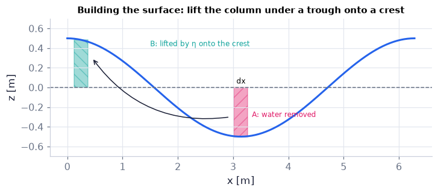

```python
x = np.linspace(0, 2*np.pi, 300)                          # one wavelength, k = 1 rad/m [m]
fig, ax = plt.subplots(figsize=(6.5, 2.8))                # one panel
ax.plot(x, 0.5*np.cos(x), color=COLORS["blue"], lw=2)     # the surface η = a cos kx, a = 0.5 m
ax.axhline(0, color=COLORS["muted"], ls="--", lw=1)       # still level
xa, xb, dx = np.pi, 0.0 + 0.25, 0.25                      # column A at the trough, column B on the crest side [m]
ax.fill_between([xa - dx/2, xa + dx/2], [0.5*np.cos(xa)]*2, [0, 0], color=COLORS["rose"], alpha=0.4, hatch="//")   # column A: the missing water under the trough
ax.fill_between([xb - dx/2, xb + dx/2], [0, 0], [0.5*np.cos(xb)]*2, color=COLORS["teal"], alpha=0.4, hatch="\\\\")   # column B: the lifted water on the crest
ax.annotate("", xy=(xb + 0.2, 0.3), xytext=(xa - 0.2, -0.3), arrowprops=dict(arrowstyle="->", color=COLORS["ink"], connectionstyle="arc3,rad=-0.3"))
ax.text(xa + 0.2, -0.3, "A: water removed", fontsize=8, color=COLORS["rose"])   # label A
ax.text(1.5, 0.42, "B: lifted by η onto the crest", fontsize=8, color=COLORS["teal"])   # label B
ax.text(xa - 0.08, 0.04, "dx", fontsize=8)   # the column width
ax.set_xlabel("x [m]"); ax.set_ylabel("z [m]"); ax.set_ylim(-0.7, 0.7)   # axes
ax.set_title("Building the surface: lift the column under a trough onto a crest", fontsize=10)   # the message
savefig(fig, "ch07", "c06_column_swap"); plt.show()   # save, then draw
```

**What you see.** The column A of height |η| under a trough (rose) is removed and put on the crest as column B (teal).

**How to read it.** Lifting a column of mass ρη dx (per unit width) through a height η costs $\rho g\eta^2dx$; over half a wavelength the swaps build a whole wavelength of surface — the $\frac{\rho g}{2\lambda}\int\eta^2dx$ of (7.40), $E_p=\frac{\rho g}{2\lambda}\int_0^\lambda\eta^2\,dx$.

**What would change if…** …the fluid above were not air but a lighter liquid ρ₁: each swap also moves ρ₁ down — the work uses ρ₂ − ρ₁ (note N105, C13).

#### 🧮 Derivation — Potential energy, equipartition and $E=\tfrac12\rho ga^2$ `D13` (Eq. 7.42: $E=E_p+E_k=\rho g\overline{\eta^2}=\tfrac12\rho ga^2$)

**What we want to show.** Find the energy stored in the lifted and lowered water, compare it with D12, and add them.

**Assumptions.** Linear wave; sinusoidal η for the last step.

**The plan.**

1. Define E_p as wavy minus flat.
2. Cancel the common part of the integrals.
3. Integrate.
4. Compare and add.

**Tools we use** (each explained before this point): splitting an integral · definite integral (P27) · mean of cos² (P151) · D12.

**We start from**

$$ \text{Potential energy per unit volume ρgz} $$

*In words:* water higher up stores more energy.

**Step 1 of 7 — Define E_p as a difference.**

$$ E_p=\frac{\rho g}{\lambda}\int_0^\lambda\!\int_{-H}^{\eta}z\,dz\,dx-\frac{\rho g} {\lambda}\int_0^\lambda\!\int_{-H}^{0}z\,dz\,dx $$

- *Why we can do this:* Potential energy is measured from the flat, undisturbed state: the work needed to deform the surface (ρgz per unit volume, per unit length along the crest).
- *In words:* wave PE = wavy water minus flat water.

**Step 2 of 7 — Split the first z-integral.**

$$ \int_{-H}^{\eta}z\,dz=\int_{-H}^{0}z\,dz+\int_0^{\eta}z\,dz $$

- *Why we can do this:* Integrals are additive over adjacent intervals; the first piece cancels the flat-state integral.
- *In words:* only the water between the still level and the surface counts.

**Step 3 of 7 — Integrate.**

$$ \int_0^{\eta}z\,dz=\tfrac12\eta^2 $$

- *Why we can do this:* Antiderivative z²/2 from 0 to η; the H² terms have cancelled; for η < 0 it is also +η²/2 (removing water below the level also stores energy).
- *In words:* each column stores ρgη²/2 per unit area.

**Step 4 of 7 — Write E_p.**

$$ E_p=\frac{\rho g}{2\lambda}\int_0^\lambda\eta^2dx\ \text{(7.40)} $$

- *Why we can do this:* Put step 3 into step 1. The column swap of Fig. 7.6 agrees: over half a wavelength, lifting a column of mass ρη dx by η costs ρgη² dx.
- *In words:* the potential energy per unit area.

**Step 5 of 7 — Use the mean square.**

$$ E_p=\tfrac12\rho g\overline{\eta^2}\ \text{(7.41)} $$

- *Why we can do this:* The mean square over a wavelength is by definition $\overline{\eta^2}=\frac1\lambda\int_0^\lambda\eta^2dx$; we use it to compare with (7.39), $E_k=\tfrac12\rho g\overline{\eta^2}$.
- *In words:* PE in terms of the mean-square height.

**Step 6 of 7 — Compare with D12.**

$$ E_p=E_k $$

- *Why we can do this:* (7.39), $E_k=\tfrac12\rho g\overline{\eta^2}$ and (7.41), $E_p=\tfrac12\rho g\overline{\eta^2}$ are the same expression: equipartition, as for any small oscillation of a conservative system without rotation.
- *In words:* motion and height share the energy equally.

**Step 7 of 7 — Add and use a sinusoid.**

$$ E=E_k+E_p=\rho g\overline{\eta^2}=\tfrac12\rho ga^2\ \text{(7.42)} $$

- *Why we can do this:* For η = a cos(kx − ωt), $\overline{\eta^2}$ = a²/2 (⟨cos²⟩ = ½, P151).
- *In words:* total wave energy per square metre.

**Result**

$$ E_p=\tfrac12\rho g\overline{\eta^2}=E_k\ \text{(7.41),}\ E=\tfrac12\rho ga^2 $$

**What it means.** Wave energy grows with the square of the height: a 2 m sea holds four times the energy of a 1 m sea. Equipartition fails once the Earth's rotation matters (Ch. 13).

**Check it.** a = 1 m → E = 4905 J/m², half each (the code cell after the tiny example of C06, also with `quad`) ✓. Units J/m² ✓.

> ⚠️ **Common confusion (traps in `D13`):** Forgetting that the flat-state energy must be subtracted; $\overline{\eta^2}=a^2/2$ only for a sinusoid.

📝 **Note.** **Equipartition** `N34` — $E_p=\tfrac12\rho g\overline{\eta^2}$ *(7.41)* equals $E_k=\tfrac12\rho g\overline{\eta^2}$ *(7.39)*: small oscillations of a conservative system share their energy equally between motion and height. It fails once Coriolis forces act (Ch. 13: geostrophic adjustment leaves potential energy locked in).

> 🔁 **Tools from earlier chapters used here** (see `knowledge/primers.md`)
- **power of a force** — a force does work at the rate F·u; per unit area of a surface, a pressure does p·u·n (Ch. 4 P127).

📝 **Note.** **The energy flux across a vertical line** `N35` — is the pressure work: $F=\big\langle\int_{-H}^0pu\,dz\big\rangle=\big\langle\int_{-H}^0p'u\,dz\big\rangle-\rho g\langle u\rangle\int_{-H}^0z\,dz$, which is (7.43) because ⟨u⟩ = 0 at every depth.

$$ F=\Big\langle\int_{-H}^0p'u\,dz\Big\rangle \qquad \text{(7.43)} $$

#### 🧮 Derivation — The energy flux `D14` (Eq. 7.44: $F=\Big[\tfrac12\rho ga^2\Big]\Big[\frac c2\Big(1+\frac{2kH}{\sinh2kH}\Big)\Big]$)

**What we want to show.** Find how much energy per second crosses a vertical line under the wave, and show it is energy × a speed that is not c.

**Assumptions.** Linear wave; integrate to z = 0 (as D12).

**The plan.**

1. Split the pressure.
2. Kill the background part.
3. Insert p′ and u.
4. Average and integrate.
5. Regroup as energy × speed.

**Tools we use** (each explained before this point): power of a force (P127) · mean of cos² (P151) · ∫cosh² from D12 · hyperbolic identities (P168) · (7.28), $\omega=\sqrt{gk\tanh kH}$.

**We start from**

$$ F=\big\langle\int_{-H}^0pu\,dz\big\rangle $$

*In words:* the water on one side pushes on the other with pressure p while moving with u.

**Step 1 of 10 — Write the pressure work across x = 0.**

$$ F=\big\langle\int_{-H}^0pu\,dz\big\rangle $$

- *Why we can do this:* Power of a force is force × velocity (P127): pressure p over the strip dz times u; ⟨⟩ averages over a period.
- *In words:* energy per second through a vertical line, per metre of crest.

**Step 2 of 10 — Split the pressure.**

$$ p=p'-\rho gz $$

- *Why we can do this:* (7.30), $p'\equiv p+\rho gz$ p′ ≡ p + ρgz: wave part plus still-water part.
- *In words:* two pieces.

**Step 3 of 10 — Separate the two parts.**

$$ F=\big\langle\int p'u\,dz\big\rangle-\rho g\int_{-H}^0z\langle u\rangle dz $$

- *Why we can do this:* Linearity of the integral; z does not depend on t, so the time average moves inside onto u.
- *In words:* the background pushes on a velocity that averages to zero.

**Step 4 of 10 — Use ⟨u⟩ = 0.**

$$ F=\big\langle\int_{-H}^0p'u\,dz\big\rangle\ \text{(7.43)} $$

- *Why we can do this:* u ∝ cos(kx − ωt) averages to zero over a period at every depth — which is why the book may pull ⟨u⟩ out of the integral.
- *In words:* only the wave pressure does net work.

**Step 5 of 10 — Insert p′ and u.**

$$ p'u=\frac{\rho a^2\omega^3}{k}\frac{\cosh^2k(z+H)}{\sinh^2kH}\cos^2(kx-\omega t) $$

- *Why we can do this:* The first form of the pressure, $p'=-\rho\frac{\partial\phi}{\partial t}=\rho\frac{a\omega^2}{k}\frac{\cosh k(z+H)}{\sinh kH}\cos(kx-\omega t)$ (the linearised Bernoulli equation applied to the potential of D05), and u from (7.27), $u=a\omega\frac{\cosh k(z+H)}{\sinh kH}\cos(kx-\omega t),\ w=a\omega\frac{\sinh k(z+H)}{\sinh kH}\sin(kx-\omega t)$ (the book's 'u from (7.28), $\omega=\sqrt{gk\tanh kH}$' means (7.27)).
- *In words:* pressure and velocity are in step, so the product is never negative.

**Step 6 of 10 — Average in time.**

$$ F=\frac{\rho a^2\omega^3}{2k\sinh^2kH}\int_{-H}^0\cosh^2k(z+H)dz $$

- *Why we can do this:* The time average of cos² over a period is ½ (P151); nothing else in the product depends on time.
- *In words:* half the peak product.

**Step 7 of 10 — Integrate over the depth.**

$$ F=\frac{\rho a^2\omega^3}{2k\sinh^2kH}\Big(\frac H2+\frac{\sinh2kH}{4k}\Big) $$

- *Why we can do this:* The cosh² integral of D12 step 5.
- *In words:* the depth integral done.

**Step 8 of 10 — Factor out sinh 2kH/4k.**

$$ F=\frac{\rho a^2\omega^3\sinh2kH}{8k^2\sinh^2kH}\Big(1+\frac{2kH}{\sinh2kH}\Big) $$

- *Why we can do this:* Write H/2 = (sinh 2kH/4k)(2kH/sinh 2kH), an identity, so that the depth term becomes a correction to 1.
- *In words:* a depth factor appears.

**Step 9 of 10 — Simplify with (7.28).**

$$ \frac{\sinh2kH}{\sinh^2kH}=\frac{2}{\tanh kH},\ \omega^3=\omega\,gk\tanh kH\ \Rightarrow\ F=\frac{\rho a^2g\omega}{4k}\Big(1+\frac{2kH}{\sinh2kH}\Big) $$

- *Why we can do this:* Double angle (P168); one ω² replaced by (7.28), $\omega=\sqrt{gk\tanh kH}$; tanh kH cancels.
- *In words:* the flux in terms of g.

**Step 10 of 10 — Regroup as energy × speed.**

$$ F=\big[\tfrac12\rho ga^2\big]\Big[\frac c2\Big(1+\frac{2kH}{\sinh2kH}\Big)\Big]\ \text{(7.44)} $$

- *Why we can do this:* ρa²gω/(4k) = ½ρga² · ω/(2k) and ω/k = c.
- *In words:* flux = energy density × a speed that is not c.

**Result**

$$ F=\big[\tfrac12\rho ga^2\big]\big[\frac c2\big(1+\frac{2kH}{\sinh2kH}\big)\big] $$

**What it means.** Energy moves at (c/2)(1 + 2kH/sinh 2kH), not at c: the group velocity of C09, (7.69), $c_g=\frac c2\Big[1+\frac{2kH}{\sinh(2kH)}\Big]$. Only in shallow water do crests and energy travel together.

**Check it.** Units: J/m² × m/s = W/m ✓. Deep water: F = E c/2; shallow: F = E c. T = 10 s, a = 1 m deep: 38.3 kW/m, equal to `energy_flux(method="quad")` ✓.

> ⚠️ **Common confusion (traps in `D14`):** Using the second form of (7.31), $p'=\rho ga\frac{\cosh k(z+H)}{\cosh kH}\cos(kx-\omega t)$ (it works but hides the ω³); forgetting ⟨u⟩ = 0 holds at every depth (so pulling it out is legal); losing the factor ½ of ⟨cos²⟩.

📝 **Note.** **Energy times a speed that is not c** `N36` — $F=\big[\tfrac12\rho ga^2\big]\big[\frac c2\big(1+\frac{2kH}{\sinh2kH}\big)\big]$ *(7.44)*. The book calls the second factor the group speed and returns to it in §7.5 (C09: $c_g=\frac c2\big[1+\frac{2kH}{\sinh(2kH)}\big]$ *(7.69)*). Where the book says "u from (7.28), $\omega=\sqrt{gk\tanh kH}$" before (7.44) it means (7.27), $u=a\omega\frac{\cosh k(z+H)}{\sinh kH}\cos(kx-\omega t),\ w=a\omega\frac{\sinh k(z+H)}{\sinh kH}\sin(kx-\omega t)$: (7.28) is the dispersion relation.

#### ✏️ Tiny example: energy and power of a metre of swell

1. a = 1 m: $E=\tfrac12\rho ga^2=\tfrac12\times1000\times9.81\times1=4905$ J/m², half of it kinetic.
2. T = 10 s deep water: c = 15.6 m/s, and the second factor of (7.44), $F=\Big[\tfrac12\rho ga^2\Big]\Big[\frac c2\Big(1+\frac{2kH}{\sinh2kH}\Big)\Big]$ is c/2 = 7.81 m/s.
3. $F=4905\times7.81=38\,300$ W per metre of crest ≈ 38 kW/m.
4. If the energy moved at c we would have claimed 76.6 kW/m — twice too much.

> 🔁 **Tools from earlier chapters used here** (see `knowledge/primers.md`)
- **scipy.integrate.quad and dblquad** — adaptive integration of a function over an interval or an area (inner limits may be functions) (Ch. 3 P87).
- **midpoint double sums** — an area integral as Σ f × cell area at cell centres, error ∝ h² (Ch. 2 P83).

```python
for kH in (0.5, 1.0, 3.0):                                # k = 1 rad/m, so H = kH [m]; a = 1 m
    c_ = ch07.wave_energy(1.0, 1.0, kH, method="closed")  # (7.39), (7.41), (7.42)
    q_ = ch07.wave_energy(1.0, 1.0, kH, method="quad")    # dblquad of the integrals (7.38) and (7.40)
    print(f"kH = {kH}: closed {c_}, quad Ek = {q_['Ek']:.6f}, Ep = {q_['Ep']:.6f} J/m²")
k = (2*np.pi/10)**2/G                                     # a 10 s deep-water swell [rad/m]
print(f"F = {ch07.energy_flux(1.0, k):.1f} W/m (7.44); by averaging p′u over depth and period: "
      f"{ch07.energy_flux(1.0, k, method='quad'):.1f} W/m")
```

```
kH = 0.5: closed {'Ek': 2452.5, 'Ep': 2452.5, 'E': 4905.0}, quad Ek = 2452.500000, Ep = 2452.500000 J/m²
kH = 1.0: closed {'Ek': 2452.5, 'Ep': 2452.5, 'E': 4905.0}, quad Ek = 2452.500000, Ep = 2452.500000 J/m²
```

```
kH = 3.0: closed {'Ek': 2452.5, 'Ep': 2452.5, 'E': 4905.0}, quad Ek = 2452.500000, Ep = 2452.500000 J/m²
```

```
F = 38291.1 W/m (7.44); by averaging p′u over depth and period: 38291.1 W/m
```

**What does the code above do?**

1. `wave_energy(method="closed")` returns $E_k=E_p=2452.5$ J/m² and E = 4905 J/m² for a = 1 m, whatever kH is; `method="quad"` integrates (7.38), $E_k=\frac{\rho}{2\lambda}\int_0^\lambda\!\!\int_{-H}^0(u^2+w^2)\,dz\,dx$ and (7.40), $E_p=\frac{\rho g}{2\lambda}\int_0^\lambda\eta^2\,dx$ with `dblquad` over one wavelength and the depth — the same numbers to about $10^{-12}$.
2. `energy_flux` gives (7.44), $F=\Big[\tfrac12\rho ga^2\Big]\Big[\frac c2\Big(1+\frac{2kH}{\sinh2kH}\Big)\Big]$ = 38 291 W/m for the 10 s swell; the `quad` version averages p′u (from `wave_fields`) over the depth and one period: the same number.

```python
k, H, a, rho = 1.0, 1.0, 1.0, 1000.0                     # kH = 1 wave [rad/m, m, m, kg/m³]
nx, nz = 400, 200                                        # midpoint grid over one wavelength and the depth
xm = (np.arange(nx) + 0.5)*(2*np.pi/k)/nx                # cell centres in x [m]
zm = -H + (np.arange(nz) + 0.5)*H/nz                     # cell centres in z [m]
XX, ZZ = np.meshgrid(xm, zm)                             # every cell centre
f = ch07.wave_fields(XX, ZZ, 0.0, a, k, H)               # u, w at t = 0 [m/s]
Ek_mine = np.sum(0.5*rho*(f["u"]**2 + f["w"]**2))*(2*np.pi/k/nx)*(H/nz)/(2*np.pi/k)   # Σ ½ρ|u|² dx dz / λ [J/m²]
print(f"midpoint sum: E_k = {Ek_mine:.3f} J/m²")
assert np.allclose(Ek_mine, ch07.wave_energy(a, k, H)["Ek"], rtol=1e-4)   # same number as ¼ρga² = 2452.5 J/m²
```

```
midpoint sum: E_k = 2452.490 J/m²
```

**What does this show?** The midpoint sum of ½ρ(u² + w²) over one wavelength and the whole depth, the integral $E_k=\frac{\rho}{2\lambda}\int_0^\lambda\!\!\int_{-H}^0(u^2+w^2)\,dz\,dx$ *(7.38)*, gives 2452.49 J/m²; the closed form $E_k=\tfrac12\rho g\overline{\eta^2}$ *(7.39)* = ¼ρga² = ¼ × 1000 × 9.81 × 1² = 2452.5 J/m². They agree to about 4 parts in a million, so the integral really does collapse to a quarter of ρga².

```
swell, H = 100 m: kH = 4.03, F/(Ec) = 0.50
30 m shelf: kH = 1.37, F/(Ec) = 0.68
```

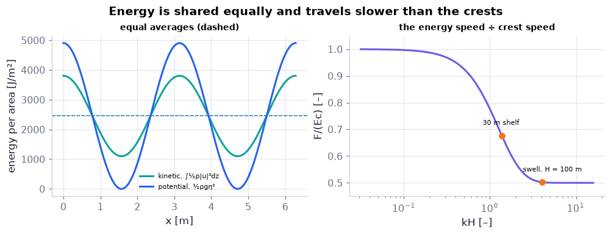

```python
k, H, a, rho = 1.0, 1.0, 1.0, 1000.0                      # kH = 1 [rad/m, m, m, kg/m³]
xs = np.linspace(0, 2*np.pi, 200)                         # one wavelength [m]
zs = np.linspace(-H, 0, 201)                              # depth grid for the column integral [m]
XX, ZZ = np.meshgrid(xs, zs)                              # (z, x) grid
f = ch07.wave_fields(XX, ZZ, 0.0, a, k, H)                # u, w at t = 0
ke_col = np.trapezoid(0.5*rho*(f["u"]**2 + f["w"]**2), zs, axis=0)   # ∫½ρ|u|² dz at each x [J/m²]
pe_col = 0.5*rho*G*(a*np.cos(k*xs))**2                    # ½ρgη² at each x [J/m²]
fig, (a1, a2) = plt.subplots(1, 2, figsize=(9, 3.4))      # energy along a wavelength | c_g/c
a1.plot(xs, ke_col, color=COLORS["teal"], lw=2, label="kinetic, ∫½ρ|u|²dz")
a1.plot(xs, pe_col, color=COLORS["blue"], lw=2, label="potential, ½ρgη²")
a1.axhline(ke_col.mean(), color=COLORS["teal"], ls="--", lw=1); a1.axhline(pe_col.mean(), color=COLORS["blue"], ls=":", lw=1)
a1.set_xlabel("x [m]"); a1.set_ylabel("energy per area [J/m²]"); a1.legend(fontsize=7); a1.set_title("equal averages (dashed)", fontsize=9)
kHs = np.logspace(-1.5, 1.2, 200)                         # depth ratios [–]
a2.semilogx(kHs, 0.5*(1 + 2*kHs/np.sinh(2*kHs)), color=COLORS["accent"], lw=2)   # F/(Ec) = c_g/c from (7.44)
for Hc, lab in ((100.0, "swell, H = 100 m"), (30.0, "30 m shelf")):   # the 10 s swell of the tiny examples on two depths [m]
    kv = ch07.wavenumber_from_omega(2*np.pi/10, Hc)*Hc     # its kH on that depth (solves ω² = gk tanh kH) [–]
    ratio = 0.5*(1 + 2*kv/np.sinh(2*kv))                  # F/(Ec) from (7.44) [–]
    print(f"{lab}: kH = {kv:.2f}, F/(Ec) = {ratio:.2f}")  # the numbers the dots mark
    a2.plot(kv, ratio, "o", color=COLORS["orange"]); a2.text(kv*0.6, ratio + 0.04, lab, fontsize=7)
a2.set_ylim(0.45, 1.05); a2.set_xlabel("kH [–]"); a2.set_ylabel("F/(Ec) [–]"); a2.set_title("the energy speed ÷ crest speed", fontsize=9)
fig.suptitle("Energy is shared equally and travels slower than the crests", fontweight="bold")
savefig(fig, "ch07", "c06_energy"); plt.show()
```

**What you see.** Left: the depth-integrated kinetic energy (teal) and ½ρgη² (blue) along one wavelength — different shapes, the same average. Right: the ratio F/(Ec) falls from 1 (shallow) to ½ (deep).

**How to read it.** In deep water energy arrives at half the crest speed (C09 explains why); the 10 s swell on the 30 m shelf (kH = 1.37, printed above the figure) carries it at 0.68 of the crest speed.

> ⚠️ **Common confusion:** surface-wave E is energy per square metre of sea surface (the whole water column below it), and F is power per metre of crest. For internal waves in C16 the same letters mean per cubic metre and per square metre.

**What would change if…** …the Earth's rotation joined in (long waves, Ch. 13)? Kinetic and potential energy stop being equal: geostrophic adjustment keeps some potential energy in a balanced current.

*↪ **Refraction** (the book's Figs. 7.8–7.9: waves turning toward a beach and wrapping round an island) belongs to this section of the book; we teach it in C10 (§7.5), where the rays that explain it are derived (notes N47, N48, N174, N175).*

## 7.3 Influence of Surface Tension

**What is this section about?** A curved surface pulls itself flat, like a stretched membrane — a second restoring force besides gravity. It only matters for short waves, but there it wins, and together the two forces leave a slowest possible wave on water.

> 🔁 **Recap — The Laplace pressure jump** (Ch. 1 §1.6, Ch. 4 §4.10). Across a curved interface the pressure jumps by $\Delta p=\sigma\Big(\frac1{R_1}+\frac1{R_2}\Big)$ *(1.5)*, higher on the side of the centres of curvature; Ch. 4 re-derived it as a force balance on a small patch (`interfaces.laplace_jump_from_balance`). Below: a surface curved with a 1 cm radius in one direction and straight in the other (a 10⁹ m radius), as under a straight crest.

```python
print(interfaces.laplace_jump_from_balance(0.0727, 0.01, 1e9), "Pa")   # σ = 0.0727 N/m, R₁ = 1 cm, R₂ ≈ ∞ → σ/R₁ = 7.27 Pa
```

```
7.2700000000727005 Pa
```

### 🧩 Capillary–gravity waves and the minimum speed `C07`

*The question:* Why do the smallest waves on a pond run faster than slightly longer ones — and is there a slowest wave?

*In one line:* $c=\sqrt{\Big(\frac gk+\frac{\sigma k}{\rho}\Big)\tanh kH}$ *(7.57)* · $c_{min}=\Big[\frac{4g\sigma}{\rho}\Big]^{1/4}\ \text{at}\ \lambda_m=2\pi\sqrt{\frac{\sigma}{\rho g}}$ *(7.58)*

📝 **Note.** **A second restoring force** `N49` — Surface tension acts like a stretched membrane. Pure capillary waves (no gravity) are rare on Earth, so we extend §7.2 rather than replace it.

#### The problem in plain words

Rain on a lake makes tiny ripples that race ahead of the wind waves; a stone makes a ring of ripples with a calm patch in the middle. Short waves feel the surface's tension, long ones gravity. We want the speed with both forces and the wavelength where the speed is smallest.

#### The idea

| restoring force | stronger for | term in c² (deep water) | branch |
| --- | --- | --- | --- |
| gravity (weight of the hump) | long waves | g/k | $c=\sqrt{g\lambda/2\pi}$ grows with λ |
| surface tension (curvature) | short waves | σk/ρ | $c=\sqrt{2\pi\sigma/\rho\lambda}$ grows as λ shrinks |

**One force favours long waves, the other short ones — so the speed has a minimum in between.**

> 📎 **Primer — curvature of a plane curve.** `P169` · For a curve z = η(x) the curvature (1/radius of the circle that fits the curve best there) is $1/R=\eta_{xx}/(1+\eta_x^2)^{3/2}$; for gentle slopes $1/R\approx\eta_{xx}$. Sign: under a crest $\eta_{xx}<0$ and the centre of curvature lies below, inside the water.

```python
import numpy as np                                # numbers
a, k = 0.001, 2*np.pi/0.01                        # a 1 mm ripple with λ = 1 cm [m, rad/m]
etaxx_crest = -a*k**2                             # η = a cos kx at x = 0: η'' = −ak² [1/m]
print(etaxx_crest, 1/abs(etaxx_crest))            # −394.8 1/m: radius 2.5 mm at the crest
```

```
-394.78417604357435 0.0025330295910584444
```

#### 🧮 Derivation — The surface-tension condition and capillary–gravity dispersion `D15` (Eq. 7.56: $\omega=\sqrt{k\Big(g+\frac{\sigma k^2}{\rho}\Big)\tanh kH}$)

**What we want to show.** Add surface tension to the dynamic condition and find the new dispersion relation.

**Assumptions.** Straight crests (∂/∂y = 0); small slope; air pressure uniform.

**The plan.**

1. Keep one radius (straight crests).
2. Use the curvature of a graph.
3. Put the surface pressure into linear Bernoulli.
4. Redo D06 with the extra term.

**Tools we use** (each explained before this point): Laplace jump (R09) · curvature of a plane curve (P169) · gauge pressure (R05) · D04, D05, D06.

**We start from**

$$ \Delta p=\sigma(1/R_1+1/R_2)\ \text{(1.5)} $$

*In words:* a curved surface pushes harder on the side of its centre of curvature.

**Step 1 of 10 — Keep one radius of curvature.**

$$ \frac1{R_2}=0,\quad\frac1{R_1}=\frac1R $$

- *Why we can do this:* Nothing varies along the crest (y), so the surface is straight in that direction: that radius is infinite.
- *In words:* only the curvature in the x–z plane counts.

**Step 2 of 10 — Write the pressure jump.**

$$ p_a-(p)_{z=\eta}=\sigma\frac1R $$

- *Why we can do this:* (1.5), $\Delta p=\sigma\Big(\frac1{R_1}+\frac1{R_2}\Big)$ between the air (p_a) and the water just below; 1/R > 0 when the surface bends up (η_xx > 0, centre in the air, higher pressure in the air).
- *In words:* the air–water pressure difference is σ × curvature.

**Step 3 of 10 — Check the sign under a crest.**

$$ \eta_{xx}<0\ \Rightarrow\ (p)_{z=\eta}>p_a $$

- *Why we can do this:* At a crest the centre of curvature is below, in the water, and (1.5), $\Delta p=\sigma\Big(\frac1{R_1}+\frac1{R_2}\Big)$ puts the higher pressure on that side.
- *In words:* tension squeezes the crest downward.

**Step 4 of 10 — Insert the curvature of a graph.**

$$ \frac1R=\frac{\partial^2\eta/\partial x^2}{[1+(\partial\eta/\partial x)^2]^{3/2}} \cong\frac{\partial^2\eta}{\partial x^2}\ \text{(7.53)} $$

- *Why we can do this:* Curvature of z = η(x) (P169); for small slopes the denominator is 1 + O((ka)²).
- *In words:* for gentle waves curvature is η_xx.

**Step 5 of 10 — Use gauge pressure.**

$$ (p)_{z=\eta}=-\sigma\frac{\partial^2\eta}{\partial x^2}\ \text{(7.54)} $$

- *Why we can do this:* Set p_a = 0 in step 2 with step 4.
- *In words:* the water pressure just below the surface.

**Step 6 of 10 — Put it into linear Bernoulli.**

$$ \big(\frac{\partial\phi}{\partial t}\big)_{z=0}=\frac\sigma\rho\frac{\partial^2\eta} {\partial x^2}-g\eta\ \text{(7.55)} $$

- *Why we can do this:* In D04 step 5 the pressure term is now −(σ/ρ)η_xx instead of zero; move it right and transfer to z = 0 as before.
- *In words:* tension adds a curvature term to the dynamic condition.

**Step 7 of 10 — Keep the same potential.**

$$ \phi=\frac{a\omega}{k}\frac{\cosh k(z+H)}{\sinh kH}\sin(kx-\omega t)\ \text{(7.26)} $$

- *Why we can do this:* Laplace, the bottom and the kinematic condition are unchanged, so D05 still holds; only D06 changes.
- *In words:* the flow pattern is the same.

**Step 8 of 10 — Differentiate the sinusoid twice.**

$$ \frac{\partial^2\eta}{\partial x^2}=-k^2a\cos(kx-\omega t)=-k^2\eta $$

- *Why we can do this:* η = a cos(kx − ωt) (7.2), $\eta(x,t)=a\cos[kx-\omega t]$.
- *In words:* for a sinusoid, curvature is −k² × height.

**Step 9 of 10 — Insert into (7.55).**

$$ \big(\frac{\partial\phi}{\partial t}\big)_{z=0}=-\Big(g+\frac{\sigma k^2}\rho\Big)\eta $$

- *Why we can do this:* Substitute η_xx = −k²η from step 8: (σ/ρ)(−k²η) − gη = −(g + σk²/ρ)η; both terms are now proportional to η.
- *In words:* tension acts like extra gravity σk²/ρ.

**Step 10 of 10 — Redo D06 with g → g + σk²/ρ.**

$$ \omega=\sqrt{k\Big(g+\frac{\sigma k^2}\rho\Big)\tanh kH}\ \text{(7.56),}\ c=\sqrt{\Big( \frac gk+\frac{\sigma k}\rho\Big)\tanh kH}\ \text{(7.57)} $$

- *Why we can do this:* D06 used g only through (7.21), $\Big(\frac{\partial\phi}{\partial t}\Big)_{z=\eta}\cong\Big(\frac{\partial\phi}{\partial t}\Big)_{z=0}\cong-g\eta$; replacing it gives (7.56), $\omega=\sqrt{k\Big(g+\frac{\sigma k^2}{\rho}\Big)\tanh kH}$; dividing by k gives (7.57), $c=\sqrt{\Big(\frac gk+\frac{\sigma k}{\rho}\Big)\tanh kH}$ (λ form with k = 2π/λ).
- *In words:* capillary–gravity dispersion and speed.

**Result**

$$ \begin{array}{l}p_a-(p)_{z=\eta}=\sigma\frac1R=\sigma\frac{\partial^2\eta/\partial x^2}{[1+(\partial\eta/\partial x)^2]^{3/2}}\cong\sigma\frac{\partial^2\eta}{\partial x^2}\ \text{(7.53)} \\ (p)_{z=\eta}=-\sigma\frac{\partial^2\eta}{\partial x^2}\ \text{(7.54)} \\ \Big(\frac{\partial\phi}{\partial t}\Big)_{z=0}=\frac\sigma\rho\frac{\partial^2\eta}{\partial x^2}-g\eta\ \text{(7.55)} \\ \omega=\sqrt{k\Big(g+\frac{\sigma k^2}{\rho}\Big)\tanh kH}\ \text{(7.56)} \\ c=\sqrt{\Big(\frac gk+\frac{\sigma k}{\rho}\Big)\tanh kH}\ \text{(7.57)}\end{array} $$

*In words:* tension adds σk²/ρ to g

**What it means.** Short waves are restored mainly by tension, long ones by gravity; the crossover is near √(σ/ρg) ≈ 2.7 mm × 2π.

**Check it.** Units: σk²/ρ [N/m × 1/m² × m³/kg = m/s²] ✓ — an acceleration, like g. σ = 0 returns (7.28), $\omega=\sqrt{gk\tanh kH}$ ✓. Number: a = 1 mm, λ = 1 cm: p under the crest = σak² = +28.7 Pa ✓.

> ⚠️ **Common confusion (traps in `D15`):** The sign of the pressure under a crest (higher, not lower); using both radii for straight crests; forgetting that η_xx = −k²η only for a sinusoid.

📝 **Note.** **Where D15 passes** `N50–N53` — D15 passes through the curvature condition $p_a-(p)_{z=\eta}=\sigma\frac1R=\sigma\frac{\partial^2\eta/\partial x^2}{[1+(\partial\eta/\partial x)^2]^{3/2}}\cong\sigma \frac{\partial^2\eta}{\partial x^2}$ *(7.53)*, its gauge form $(p)_{z=\eta}=-\sigma\frac{\partial^2\eta}{\partial x^2}$ *(7.54)*, the new dynamic condition $\big(\frac{\partial\phi}{\partial t}\big)_{z=0}=\frac\sigma\rho\frac{\partial^2\eta} {\partial x^2}-g\eta$ *(7.55)* and ends at $\omega=\sqrt{k\big(g+\frac{\sigma k^2}{\rho}\big)\tanh kH}$ *(7.56)*: only the dispersion relation changes, φ keeps its form (7.26), $\phi=\frac{a\omega}{k}\frac{\cosh k(z+H)}{\sinh kH}\sin(kx-\omega t)$.

> 🔁 **Tools from earlier chapters used here** (see `knowledge/primers.md`)
- **slope zero at a minimum** — a smooth function has zero slope at its minimum and a positive second derivative there (Ch. 1 P19).

#### 🧮 Derivation — The minimum phase speed `D16` (Eq. 7.58: $c_{min}=\Big[\frac{4g\sigma}{\rho}\Big]^{1/4}\ \text{at}\ \lambda_m=2\pi\sqrt{\frac{\sigma}{\rho g}}$)

**What we want to show.** Find the slowest capillary–gravity wave and its wavelength.

**Assumptions.** Deep water, tanh kH ≈ 1 (ponds are deep for centimetre ripples).

**The plan.**

1. Deep water.
2. Minimise c² instead of c.
3. Slope zero, solve, check it is a minimum.

**Tools we use** (each explained before this point): slope zero at a minimum (gloss; P19) · deep limit (D08).

**We start from**

$$ c=\sqrt{\big(\frac gk+\frac{\sigma k}\rho\big)\tanh kH}\ \text{(7.57).} $$

**Step 1 of 7 — Take deep water.**

$$ c^2=\frac gk+\frac{\sigma k}\rho $$

- *Why we can do this:* tanh kH ≈ 1 when H > 0.32λ (D08); here λ is centimetres.
- *In words:* one term falls with k, the other grows.

**Step 2 of 7 — Minimise c² instead of c.**

$$ \min c\iff\min c^2 $$

- *Why we can do this:* c > 0 and squaring is increasing for positive numbers, so both have their minimum at the same k.
- *In words:* easier algebra, same answer.

**Step 3 of 7 — Set the slope to zero.**

$$ \frac{d(c^2)}{dk}=-\frac g{k^2}+\frac\sigma\rho=0 $$

- *Why we can do this:* At a smooth minimum the derivative vanishes (P19).
- *In words:* where gravity's decrease matches tension's increase.

**Step 4 of 7 — Solve for k.**

$$ k_m=\sqrt{\frac{\rho g}\sigma},\qquad\frac g{k_m}=\frac{\sigma k_m}\rho $$

- *Why we can do this:* Multiply by k²: k² = ρg/σ; at this k the two terms of c² are equal.
- *In words:* at the minimum both restoring effects are equal.

**Step 5 of 7 — Convert to wavelength.**

$$ \lambda_m=\frac{2\pi}{k_m}=2\pi\sqrt{\frac\sigma{\rho g}}\ \text{(7.58)} $$

- *Why we can do this:* Wavelength and wavenumber are related by λ = 2π/k (7.1), $\eta(x,t)=a\cos\Big[\frac{2\pi}{\lambda}(x-ct)\Big]$, so the slowest wavenumber gives the slowest wavelength.
- *In words:* the wavelength of the slowest wave.

**Step 6 of 7 — Evaluate c² there.**

$$ c_{min}^2=\frac{2g}{k_m}=2\sqrt{\frac{g\sigma}\rho} $$

- *Why we can do this:* Both terms equal g/k_m, and g/k_m = g√(σ/ρg) = √(gσ/ρ).
- *In words:* the minimum speed squared.

**Step 7 of 7 — Take the root, check the minimum.**

$$ c_{min}=\Big[\frac{4g\sigma}\rho\Big]^{1/4}\ \text{(7.58),}\ \frac{d^2(c^2)}{dk^2}= \frac{2g}{k^3}>0 $$

- *Why we can do this:* √(2√(gσ/ρ)) = (4gσ/ρ)^(1/4); a positive second derivative means a minimum.
- *In words:* no water wave travels slower than c_min.

**Result**

$$ c_{min}=[4g\sigma/\rho]^{1/4}\ \text{at}\ \lambda_m=2\pi\sqrt{\sigma/\rho g} $$

**What it means.** At λ_m the tangent to ω(k) passes through the origin, so c_g = c there; the group velocity has its own, lower minimum (0.1776 m/s at λ ≈ 4.35 cm for clean water, computed with `min_group_velocity` in C09) — the calm ring of C09.

**Check it.** Clean water at 20 °C (σ = 72.74 mN/m, ρ = 998.2): 23.1 cm/s at 1.71 cm (7.59), $c_{min}\approx23.1\ \text{cm/s at}\ \lambda_m\approx1.71\ \text{cm (air–water, our IAPWS numbers)}$ ✓; the log-grid scan + `minimize_scalar` agree to 1e-6 ✓. Units: (m/s² × N/m ÷ kg/m³)^(1/4) = m/s ✓.

> ⚠️ **Common confusion (traps in `D16`):** Minimising in λ instead of k gives the same point (both are monotone maps), but not the same derivative; forgetting deep water was assumed.

📝 **Note.** **The minimum** `N54` — For λ < λ_m surface tension dominates.

$$ c_{min}=\Big[\frac{4g\sigma}{\rho}\Big]^{1/4}\ \text{at}\ \lambda_m=2\pi\sqrt{\frac{\sigma}{\rho g}} \qquad \text{(7.58)} $$

#### ✏️ Tiny example: clean water at 20 °C

1. σ = 72.74 mN/m (IAPWS, Ch. 1), ρ = 998.2 kg/m³, g = 9.81 m/s².
2. $\lambda_m=2\pi\sqrt{0.07274/(998.2\times9.81)}=2\pi\times2.73\times10^{-3}=0.0171$ m = 1.71 cm.
3. $c_{min}=(4\times9.81\times0.07274/998.2)^{1/4}=(2.86\times10^{-3})^{1/4}=0.231$ m/s = 23.1 cm/s.
4. Under the crest of a 1 mm ripple with λ = 1 cm: $k=2\pi/0.01=628.3$ rad/m, $k^2=3.95\times10^5$ m⁻², so $p=-\sigma\eta_{xx}=\sigma ak^2=0.07274\times0.001\times3.95\times10^5=+28.7$ Pa, pushing the crest down.

📝 **Note.** **Air–water numbers and pure capillary waves** `N55–N57` — With our numbers above, (7.59), $c_{min}\approx23.1\ \text{cm/s at}\ \lambda_m\approx1.71\ \text{cm (air–water, our IAPWS numbers)}$ reads $c_{min}\approx23.1$ cm/s at $\lambda_m\approx1.71$ cm (the book's printed values are kept in the private test file). `N56` Only ripples shorter than about 7 cm feel σ noticeably, and below about 4 mm gravity hardly matters; soap and oil films lower σ and change the ripples. `N57` Dropping g in deep water gives pure capillary waves — shorter is faster:

$$ c=\sqrt{\frac{2\pi\sigma}{\rho\lambda}} \qquad \text{(7.60)} $$

> 📎 **Primer — scipy.optimize.minimize_scalar.** `P170` · Finds the minimum of a function of one variable inside a bracket (`method="bounded"`); we use it to check a formula for a minimum by brute force.

```python
from scipy.optimize import minimize_scalar        # 1-D minimiser
r = minimize_scalar(lambda x: (x - 2)**2 + 1, bounds=(0, 5), method="bounded")   # a parabola with its minimum at x = 2
print(r.x, r.fun)                                 # 2.0 1.0
```

```
2.0 1.0
```

```python
sig, rho = ch01.surface_tension_water(293.15), 998.2     # Ch. 1: σ of clean water at 20 °C [N/m]; density [kg/m³]
print(f"σ = {sig:.5f} N/m;", ch07.capillary_minimum(sig, rho))   # (7.58): c_min [m/s], λ_m [m], k_m [rad/m]
for lam in (0.004, 0.0171, 0.07, 1.0):                   # four wavelengths [m]
    k = 2*np.pi/lam                                      # wavenumber [rad/m]
    print(f"λ = {lam*100:5.2f} cm: c = {ch07.phase_speed(k, np.inf, sigma=sig, rho=rho):.3f} m/s with σ, "
          f"{ch07.phase_speed(k, np.inf):.3f} m/s without")   # (7.57) vs (7.45)
print(f"crest pressure of a 1 mm, 1 cm ripple: {ch07.capillary_surface_pressure(-0.001*(2*np.pi/0.01)**2, sig):.1f} Pa;",
      "curvature (linear form):", ch07.curvature(0.0, -394.8, linear=True), "1/m")   # (7.54), (7.53)
```

```
σ = 0.07274 N/m; {'c_min': 0.2312413102086655, 'lam_m': 0.01712425585892754, 'k_m': 366.9172756434795}
λ =  0.40 cm: c = 0.347 m/s with σ, 0.079 m/s without
λ =  1.71 cm: c = 0.231 m/s with σ, 0.163 m/s without
λ =  7.00 cm: c = 0.340 m/s with σ, 0.331 m/s without
λ = 100.00 cm: c = 1.250 m/s with σ, 1.250 m/s without
crest pressure of a 1 mm, 1 cm ripple: 28.7 Pa; curvature (linear form): -394.8 1/m
```

**What does the code above do?**

1. `surface_tension_water` (the IAPWS fit of Ch. 1) gives σ = 0.07274 N/m; `capillary_minimum` returns $c_{min}=0.2312$ m/s at $\lambda_m=1.712$ cm.
2. At λ = 4 mm tension wins (0.347 m/s with σ, only 0.079 without); at 1.71 cm the speed is the minimum; at 7 cm the two differ by 3 %; at 1 m surface tension is invisible (1.250 m/s both ways).
3. The liquid pressure under the crest of a 1 mm ripple, $(p)_{z=\eta}=-\sigma\frac{\partial^2\eta}{\partial x^2}$ *(7.54)*, is +28.7 Pa — the crest is pushed down, like gravity.

```python
from scipy.optimize import minimize_scalar                 # the 1-D minimiser of primer P170
lam = np.logspace(-3.5, 0, 4001)                           # a log grid of wavelengths [m]
c = ch07.phase_speed(2*np.pi/lam, np.inf, sigma=sig, rho=rho)   # (7.57) in deep water [m/s]
i = np.argmin(c)                                           # the smallest sampled speed
r = minimize_scalar(lambda kk: G/kk + sig*kk/rho, bounds=(2*np.pi/lam[i + 1], 2*np.pi/lam[i - 1]), method="bounded",
                    options=dict(xatol=1e-10))             # refine: minimise c² = g/k + σk/ρ in k
cmin_mine, lam_mine = np.sqrt(r.fun), 2*np.pi/r.x          # [m/s], [m]
d = ch07.capillary_minimum(sig, rho)                       # the closed form (7.58)
print(f"brute force: c_min = {cmin_mine:.6f} m/s at λ = {lam_mine*100:.5f} cm")
assert np.allclose([cmin_mine, lam_mine], [d["c_min"], d["lam_m"]], rtol=1e-6)   # same numbers as (7.58)
```

```
brute force: c_min = 0.231241 m/s at λ = 1.71243 cm
```

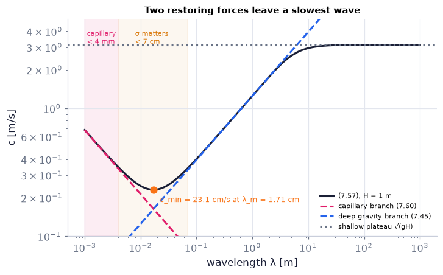

```python
lam = np.logspace(-3, 3, 400)                              # wavelengths 1 mm … 1 km [m]
k = 2*np.pi/lam                                            # wavenumbers [rad/m]
sg, rh, H = 0.0727, 1000.0, 1.0                            # σ [N/m], ρ [kg/m³], a 1 m deep tank [m]
fig, ax = plt.subplots(figsize=(6.5, 4))                   # one log–log panel
ax.loglog(lam, ch07.phase_speed(k, H, sigma=sg, rho=rh), color=COLORS["ink"], lw=2, label="(7.57), H = 1 m")   # c with both forces, (7.57)
ax.loglog(lam, np.sqrt(2*np.pi*sg/(rh*lam)), "--", color=COLORS["rose"], label="capillary branch (7.60)")   # tension only
ax.loglog(lam, np.sqrt(G*lam/(2*np.pi)), "--", color=COLORS["blue"], label="deep gravity branch (7.45)")   # gravity only, deep
ax.axhline(np.sqrt(G*H), ls=":", color=COLORS["muted"], label="shallow plateau √(gH)")   # very long waves on 1 m
m = ch07.capillary_minimum(sg, rh, G)                      # (7.58)
ax.plot(m["lam_m"], m["c_min"], "o", color=COLORS["orange"], ms=7)   # the minimum (7.58)
ax.text(m["lam_m"]*1.3, m["c_min"]*0.8, f"c_min = {m['c_min']*100:.1f} cm/s at λ_m = {m['lam_m']*100:.2f} cm", fontsize=8, color=COLORS["orange"])
ax.axvspan(1e-3, 0.004, color=COLORS["rose"], alpha=0.08); ax.text(1.1e-3, 3.2, "capillary\n< 4 mm", fontsize=7, color=COLORS["rose"])
ax.axvspan(0.004, 0.07, color=COLORS["amber"], alpha=0.06); ax.text(8e-3, 3.2, "σ matters\n< 7 cm", fontsize=7, color=COLORS["amber"])
ax.set_ylim(0.1, 5); ax.set_xlabel("wavelength λ [m]"); ax.set_ylabel("c [m/s]")   # axes with units
ax.set_title("Two restoring forces leave a slowest wave", fontsize=10); ax.legend(fontsize=7, loc="lower right")   # message and legend
savefig(fig, "ch07", "c07_capillary"); plt.show()   # save, then draw
```

**What you see.** A valley at 1.7 cm between the rising capillary branch (rose) and the gravity branch (blue), then the $\sqrt{gH}$ plateau for very long waves (our remake of Fig. 7.10 `N176`).

**How to read it.** At any λ the square of the black curve is the sum of the squares of the two dashed branches, times tanh kH.

**What would change if…** …soap halved σ: the valley moves to 1.2 cm and 19 cm/s ($\lambda_m\propto\sigma^{1/2}$, $c_{min}\propto\sigma^{1/4}$).

```python
lam = np.logspace(-3.5, 0.5, 300)                          # wavelengths [m]
def curves(sg):                                            # c(λ) and the minimum for one surface tension σ [N/m]
    c = ch07.phase_speed(2*np.pi/lam, np.inf, sigma=sg, rho=1000.0)          # (7.57), deep water
    m = ch07.capillary_minimum(sg, 1000.0, G) if sg > 0 else {"lam_m": np.nan, "c_min": np.nan}   # (7.58)
    return {"c(λ) (7.57)": (lam, c), "minimum (7.58)": ([m["lam_m"]], [m["c_min"]])}
fig = slider_figure(curves, "σ", np.linspace(0.0, 0.5, 26 if not FAST else 11), unit="N/m", xlabel="λ [m]",
                    ylabel="c [m/s]", title="The minimum slides with σ", modes={"minimum (7.58)": "markers"})
logaxes(fig, x=(10**-3.5, 10**0.5), y=(0.05, 3))           # log axes, fixed
recolor(fig, {"c(λ) (7.57)": COLORS["ink"], "minimum (7.58)": COLORS["orange"]})
fig.show()   # draw (works on the page: no kernel needed)
```

[interactive chart not shown]

**What you see.** At σ = 0 there is no minimum (pure gravity waves get ever slower as λ shrinks); raising σ lifts the short-wave branch and pushes the minimum to longer, faster waves.

**What would change if…** the liquid were denser at the same σ (mercury-like): σ/ρ is what matters, so the minimum would move back toward shorter, slower waves.

#### 🎮 Interactive: Why is there a slowest ripple?

**Why interactive rather than a static figure:** Sweep λ over four decades and change the liquid: the gravity and surface-tension term bars trade places, the minimum moves, and the status names the branch. Only interaction shows the two forces competing.

**What to try:**

- Press *λ = λ_m*: the two bars are equal.
- Switch the liquid to mercury: the minimum moves to about 1.2 cm and 19 cm/s.
- Drag λ to 5 mm and read the crest pressure in the Explain tab.
- Step the Derivation (D16) to 'set the slope to zero'.

```python
show_viz("ch07", "capillary_gravity_waves")   # full-width explainer; ⤢ Full screen for more room
```

🎮 Interactive 2/9 Why is there a slowest ripple? Open alone ↗

[interactive chart not shown]

**What would change if…** …the group speed were asked for instead of the phase speed? It also has a minimum — lower than $c_{min}$ and at a longer wavelength; C09 computes it with `min_group_velocity` (0.1776 m/s at λ ≈ 4.35 cm for clean water) — which is why the ring of ripples from a stone leaves a calm centre (C09, note N72).

## 7.4 Standing Waves

**What is this section about?** Two equal waves travelling in opposite directions add into a pattern that does not travel: fixed nodes, sloshing in between. Walls allow only the patterns whose nodes fit — so a lake, a harbour or a bathtub rings at its own set of periods (seiches).

### 🧩 Standing waves and seiches `C08`

*The question:* Which waves can live in a closed basin, and with which periods?

*In one line:* $kL=(n+1)\pi,\ \lambda=\frac{2L}{n+1}$ *(7.64)* · $\omega=\sqrt{\frac{\pi g(n+1)}{L}\tanh\Big[\frac{(n+1)\pi H}{L}\Big]}$ *(7.65)*

#### The problem in plain words

Push the water in a bathtub once and it sloshes back and forth at a fixed rhythm. Lake Geneva does the same after a storm, with a period of about an hour; harbours do it and ships break their moorings. We want to know which sloshing patterns a basin allows and their periods.

#### The idea

```
right-going  a cos(kx − ωt)  +  left-going  a cos(kx + ωt)  =  2a cos kx · cos ωt
the shape cos kx never moves; it only breathes in time (cos ωt)
nodes of η at kx = π/2, 3π/2, …   — walls must sit where u = 0 (antinodes of η)
```

> 📎 **Primer — sum-to-product identities.** `P171` · cos A + cos B = 2 cos((A − B)/2) cos((A + B)/2) and cos A − cos B = −2 sin((A + B)/2) sin((A − B)/2): a sum of two waves becomes a product of a slow and a fast factor. They turn two travelling waves into a standing wave here and into beats in C09.

```python
import numpy as np                                # numbers
A, B = 1.1, 0.3                                   # any two angles [rad]
print(np.cos(A) + np.cos(B), 2*np.cos((A - B)/2)*np.cos((A + B)/2))   # both 1.4089
```

```
1.4089326105511832 1.4089326105511835
```

📝 **Note.** **The left-going wave** `N58` — It is $\eta(x,t)=a\cos[kx-\omega t]$ *(7.2)* with ω → −ω: its crests move to −x.

$$ \eta(x,t)=a\cos[kx+\omega t] \qquad \text{(7.61)} $$

```python
print(ch07.sinusoid(0.0, np.array([0.0, 1.0]), 1.0, 1.0, 1.0, direction=-1))   # (7.61) at x = 0, t = 0 and 1 s
print(ch07.sinusoid(np.array([0.0, -1.0]), 1.0, 1.0, 1.0, 1.0, direction=-1))  # at t = 1 s the crest is at x = −1 m
```

```
[1.     0.5403]
[0.5403 1.    ]
```

**What does the code above do?**

With `direction=-1` the sinusoid is $a\cos(kx+\omega t)$: at x = 0 the surface falls from 1 to cos 1 = 0.540 m in 1 s, and at t = 1 s the value 1 (the crest) sits at x = −1 m — the wave has moved one metre to the left.

#### 🧮 Derivation — The standing wave, its ψ and u `D17` (Eq. 7.63: $u=2a\omega\frac{\cosh k(z+H)}{\sinh kH}\sin kx\sin\omega t$)

**What we want to show.** Add a right-going and a left-going wave and find the surface, the streamlines and the velocity of the result.

**Assumptions.** Linear problem; equal amplitudes and wavenumbers.

**The plan.**

1. Add the surfaces with sum-to-product.
2. Find the nodes.
3. Add the stream functions (with the right sign).
4. Differentiate for u.

**Tools we use** (each explained before this point): sum-to-product identities (P171) · superposition (N02) · ψ convention u = ∂ψ/∂z (N30).

**We start from**

$$ \eta=a\cos(kx-\omega t)\ \text{(7.2),}\ \eta=a\cos[kx+\omega t]\ \text{(7.61),}\ \psi=\frac{a\omega}k\frac{\sinh k(z+H)}{\sinh kH} \cos(kx-\omega t)\ \text{(7.37).} $$

**Step 1 of 8 — Take the left-going wave.**

$$ \eta_2=a\cos[kx+\omega t]\ \text{(7.61)} $$

- *Why we can do this:* Replacing ω by −ω in (7.2), $\eta(x,t)=a\cos[kx-\omega t]$ reverses the direction; the dispersion relation contains only ω², so it is also a solution.
- *In words:* an identical wave moving to −x.

**Step 2 of 8 — Add the two surfaces.**

$$ \eta=a\cos(kx-\omega t)+a\cos(kx+\omega t) $$

- *Why we can do this:* The problem is linear, so a sum of solutions is a solution (superposition).
- *In words:* both waves at once.

**Step 3 of 8 — Use sum-to-product.**

$$ \eta=2a\cos kx\cos\omega t $$

- *Why we can do this:* cos A + cos B = 2 cos((A + B)/2) cos((A − B)/2) with A = kx − ωt, B = kx + ωt; (A − B)/2 = −ωt and cos is even (P171).
- *In words:* a fixed shape breathing in time.

**Step 4 of 8 — Find the nodes.**

$$ \eta=0\ \text{for all }t\ \text{at}\ kx=\pm\tfrac\pi2,\pm\tfrac{3\pi}2,\ldots $$

- *Why we can do this:* cos kx = 0 there whatever cos ωt is.
- *In words:* some points never move.

**Step 5 of 8 — Write the left-going stream function.**

$$ \psi_2=-\frac{a\omega}k\frac{\sinh k(z+H)}{\sinh kH}\cos(kx+\omega t) $$

- *Why we can do this:* (7.37), $\psi=\frac{a\omega}{k}\frac{\sinh k(z+H)}{\sinh kH}\cos(kx-\omega t)$ with ω → −ω: the prefactor aω/k flips sign — the reversed wave's water moves the other way.
- *In words:* the reversed wave's ψ carries a minus sign.

**Step 6 of 8 — Add the stream functions.**

$$ \psi=\frac{a\omega}k\frac{\sinh k(z+H)}{\sinh kH}[\cos(kx-\omega t)-\cos(kx+\omega t)] $$

- *Why we can do this:* ψ is linear in the velocity, so it superposes too.
- *In words:* the total ψ.

**Step 7 of 8 — Use the difference identity.**

$$ \psi=\frac{2a\omega}k\frac{\sinh k(z+H)}{\sinh kH}\sin kx\sin\omega t\ \text{(7.62)} $$

- *Why we can do this:* cos A − cos B = −2 sin((A + B)/2) sin((A − B)/2) = −2 sin kx sin(−ωt) = 2 sin kx sin ωt (P171).
- *In words:* the streamlines of a standing wave.

**Step 8 of 8 — Differentiate for u.**

$$ u=\frac{\partial\psi}{\partial z}=2a\omega\frac{\cosh k(z+H)}{\sinh kH}\sin kx\sin\omega t\ \text{(7.63)} $$

- *Why we can do this:* u = ∂ψ/∂z (our convention); d/dz sinh k(z + H) = k cosh k(z + H).
- *In words:* horizontal velocity: largest at the nodes of η, zero at its crests and troughs.

**Result**

$$ \psi=\frac{2a\omega}{k}\frac{\sinh k(z+H)}{\sinh kH}\sin kx\sin\omega t\ \text{(7.62)},\qquad u=2a\omega\frac{\cosh k(z+H)}{\sinh kH}\sin kx\sin\omega t\ \text{(7.63)}\ \ \text{and the surface 2a cos kx cos ωt} $$

*In words:* a standing wave, its streamlines and its horizontal velocity

**What it means.** Energy sloshes between potential (ωt = 0, η largest, u = 0) and kinetic (ωt = π/2, η = 0, u largest); vertical lines under crests and troughs are streamlines — walls can stand there (D18).

**Check it.** `standing_wave_fields` equals the sum of two `wave_fields` (the code cell after the tiny example of C08) ✓. Units: ψ [m²/s], u [m/s] ✓.

> ⚠️ **Common confusion (traps in `D17`):** Forgetting the minus sign of ψ₂ (it would give cos kx instead of sin kx); nodes of η are antinodes of u.

📝 **Note.** **The standing wave's stream function and velocity** `N59, N61` — $\psi=\frac{a\omega}{k}\frac{\sinh k(z+H)}{\sinh kH}[\cos(kx-\omega t)-\cos(kx+\omega t)]=\frac{2a\omega}{k}\frac{\sinh k(z+H)}{\sinh kH}\sin kx\sin\omega t$ *(7.62)* and $u=2a\omega\frac{\cosh k(z+H)}{\sinh kH}\sin kx\sin\omega t$ *(7.63)*: where η has a node, u is largest.

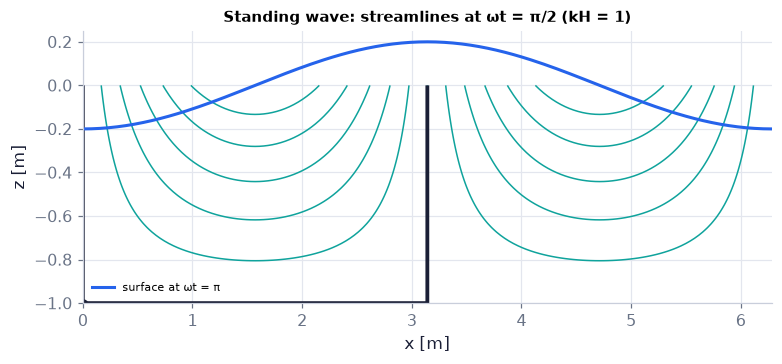

```python
k, H, a = 1.0, 1.0, 0.1                                    # kH = 1; amplitude 10 cm [rad/m, m, m]
w = ch07.omega_gravity(k, H)                               # ω [rad/s]
xg, zg = np.linspace(0, 2*np.pi, 161 if not FAST else 81), np.linspace(-H, 0, 81 if not FAST else 41)
XX, ZZ = np.meshgrid(xg, zg)                               # grid over one wavelength and the depth
f = ch07.standing_wave_fields(XX, ZZ, (np.pi/2)/w, a, k, H)   # ωt = π/2: largest flow, η = 0
fig, ax = plt.subplots(figsize=(7, 3.2))                   # one panel
lv = np.linspace(-np.abs(f["psi"]).max(), np.abs(f["psi"]).max(), 13)
ax.contour(XX, ZZ, f["psi"], levels=lv, colors=[COLORS["teal"]], linewidths=1)   # streamlines of (7.62)
ax.contour(XX, ZZ, f["psi"], levels=[0.0], colors=[COLORS["ink"]], linewidths=2.5)   # ψ = 0
eta_pi = ch07.standing_wave_fields(xg, 0.0, np.pi/w, a, k, H)["eta"]   # the surface at ωt = π (drawn ×1)
ax.plot(xg, eta_pi, color=COLORS["blue"], lw=2, label="surface at ωt = π")
ax.set_ylim(-H, 0.25); ax.set_xlabel("x [m]"); ax.set_ylabel("z [m]"); ax.legend(fontsize=7, loc="lower left")
ax.set_title("Standing wave: streamlines at ωt = π/2 (kH = 1)", fontsize=10)
savefig(fig, "ch07", "c08_standing_psi"); plt.show()
```

**What you see.** Streamlines leaving the region under one crest and entering the region under the next trough, with vertical ψ = 0 lines at the crests and troughs (our remake of Fig. 7.11 `N177`).

**How to read it.** The vertical ψ = 0 lines at kx = 0, π, 2π are where a wall can stand: u = 0 there at all times.

**What would change if…** …the snapshot were at ωt = 0: η is largest and the flow is zero everywhere — the energy is all potential at that instant.

> 🔁 **Tools from earlier chapters used here** (see `knowledge/primers.md`)
- **seiche and the eigenvalue idea** — in A·b = λb only special λ allow a non-zero b (Ch. 2 P80); here the walls allow only special wavelengths — the basin's own modes.

📝 **Note.** **A seiche** `N60` — is a standing oscillation of a closed basin (length L, depth H, vertical walls): only patterns with u = 0 at both walls survive — an eigenvalue problem (the idea of Ch. 2 P80: the boundary picks discrete solutions).

#### 🧮 Derivation — Seiche wavelengths and frequencies `D18` (Eq. 7.65: $\omega=\sqrt{\frac{\pi g(n+1)}{L}\tanh\Big[\frac{(n+1)\pi H}{L}\Big]}$)

**What we want to show.** Find which standing waves fit a basin with vertical walls at x = 0 and x = L, and their frequencies.

**Assumptions.** Vertical walls, uniform depth, no variation across the basin.

**The plan.**

1. Satisfy the wall at x = 0.
2. Impose the wall at x = L.
3. Put the allowed k into (7.28), $\omega=\sqrt{gk\tanh kH}$.

**Tools we use** (each explained before this point): zeros of sine · dispersion relation (7.28), $\omega=\sqrt{gk\tanh kH}$.

**We start from**

$$ u=2a\omega\frac{\cosh k(z+H)}{\sinh kH}\sin kx\sin\omega t\ \text{(7.63).} $$

**Step 1 of 5 — Put a wall at x = 0.**

$$ u(0,z,t)\propto\sin0=0 $$

- *Why we can do this:* A wall needs u = 0 at all depths and times; sin kx vanishes at x = 0 automatically — the book's choice of origin (an antinode of η at the wall).
- *In words:* the first wall costs nothing.

**Step 2 of 5 — Put the second wall at x = L.**

$$ \sin kL=0 $$

- *Why we can do this:* u = 0 at x = L for all z and t requires the only x-factor, sin kx, to vanish there.
- *In words:* the second wall selects k.

**Step 3 of 5 — Solve for the allowed k.**

$$ kL=(n+1)\pi,\ n=0,1,2,\ldots\ \Rightarrow\ \lambda=\frac{2L}{n+1}\ \text{(7.64)} $$

- *Why we can do this:* The zeros of sine are multiples of π; k = 0 is no wave, so the count starts at π (n = 0).
- *In words:* only 2L, L, 2L/3, … fit.

**Step 4 of 5 — Insert into the dispersion relation.**

$$ \omega^2=\frac{g(n+1)\pi}L\tanh\frac{(n+1)\pi H}L $$

- *Why we can do this:* Each travelling component obeys (7.28) ω² = gk tanh kH; put k = (n + 1)π/L.
- *In words:* each allowed wavelength has its frequency.

**Step 5 of 5 — Take the root and the shallow form.**

$$ \omega=\sqrt{\frac{\pi g(n+1)}L\tanh\frac{(n+1)\pi H}L}\ \text{(7.65);}\ T\approx\frac{2L}{(n+1)\sqrt{gH}} $$

- *Why we can do this:* Positive root; for kH ≪ 1, tanh x ≈ x gives ω = (n + 1)π√(gH)/L.
- *In words:* the natural frequencies of the basin.

**Result**

$$ \lambda=\frac{2L}{n+1}\ \text{(7.64),}\ \omega=\sqrt{\frac{\pi g(n+1)}L\tanh\big[\frac{(n+1)\pi H}L\big]} $$

**What it means.** Boundaries pick discrete modes — an eigenvalue problem; seiches, harbour resonance and tidal basins (Ch. 13) are this.

**Check it.** Bathtub L = 1.5 m, H = 0.2 m: T₀ = 2.20 s; lake L = 50 km, H = 100 m: 53.2 min = 2L/√(gH) ✓.

> ⚠️ **Common confusion (traps in `D18`):** Starting n at 1 (the book counts from 0); using λ = L for the gravest mode (it is 2L); forgetting tanh for deep, short basins.

📝 **Note.** **Allowed wavelengths and the lake's frequencies** `N62, N63` — Walls at x = 0 and L allow $kL=(n+1)\pi,\ \lambda=\frac{2L}{n+1}$ *(7.64)* — the longest is 2L, then L, 2L/3 … — and the natural frequencies (7.65). A rectangular basin L × b rings with $k^2=(m\pi/L)^2+(n\pi/b)^2$ ( `ch07.basin_modes`).

$$ \omega=\sqrt{\frac{\pi g(n+1)}{L}\tanh\Big[\frac{(n+1)\pi H}{L}\Big]} \qquad \text{(7.65)} $$

#### ✏️ Tiny example: a bathtub and a lake

1. Bathtub L = 1.5 m, H = 0.2 m, n = 0: $k=\pi/L=2.094$ rad/m, kH = 0.419, tanh = 0.396.
2. $\omega^2=9.81\times2.094\times0.396=8.14$ s⁻² → ω = 2.85 rad/s, T = 2.20 s.
3. Shallow estimate $T=2L/\sqrt{gH}=3/1.40=2.14$ s (3 % short).
4. A lake L = 50 km, H = 100 m: kH = 0.0063 — shallow; $T_0=2L/\sqrt{gH}=100\,000/31.3=3193$ s ≈ 53 min.

```python
print(ch07.seiche_modes(1.5, 0.2, 0))                      # bathtub, gravest mode: k, λ, ω, T
print(ch07.seiche_modes(50e3, 100.0, 0))                   # a 50 km lake, 100 m deep
print("lake periods [min]:", [round(ch07.seiche_modes(50e3, 100.0, n)["T"]/60, 1) for n in range(4)])   # n = 0…3
print(ch07.basin_modes(1.5, 0.7, 0.2, 1, 1))               # rectangular 1.5 m × 0.7 m tub, mode (1, 1)
x = np.linspace(0, 2, 5)                                   # five points [m]
s = ch07.standing_wave_fields(x, -0.1, 0.4, 0.01, np.pi, 0.2)                   # the standing wave (D17)
r = ch07.wave_fields(x, -0.1, 0.4, 0.01, np.pi, 0.2)                            # right-going wave (7.2)
l = ch07.wave_fields(x, -0.1, 0.4, 0.01, np.pi, 0.2, direction=-1)              # left-going wave (7.61)
assert np.allclose(s["eta"], r["eta"] + l["eta"]) and np.allclose(s["u"], r["u"] + l["u"])   # sum of the two
print("standing wave = sum of the two travelling waves ✓")
```

```
{'k': 2.0943951023931953, 'lam': 3.0, 'omega': 2.8523547153021482, 'T': 2.202806429884725}
{'k': 6.283185307179586e-05, 'lam': 100000.0, 'omega': 0.00196793846533773, 'T': 3192.7752914272605}
lake periods [min]: [53.2, 26.6, 17.7, 13.3]
{'k': 4.952629669485711, 'lam': 1.2686563959933717, 'omega': 6.066923839476497, 'T': 1.0356459836030758}
standing wave = sum of the two travelling waves ✓
```

**What does the code above do?**

1. The bathtub rings at T = 2.203 s; the lake at 3193 s = 53.2 min, then 26.6, 17.7 and 13.3 min — in a shallow basin the period falls like 1/(n + 1).
2. `basin_modes` adds a cross-basin wavenumber: $k^2=(m\pi/L)^2+(n\pi/b)^2$.
3. The assertion: the standing wave is exactly the sum of the two travelling waves of C03, both in η and in u.

```python
L, H = 1.5, 0.2                                            # the bathtub [m]
Ts = [2*np.pi/np.sqrt(G*(n + 1)*np.pi/L*np.tanh((n + 1)*np.pi*H/L)) for n in range(5)]   # (7.65) by hand [s]
print(np.round(Ts, 4))
assert np.allclose(Ts, [ch07.seiche_modes(L, H, n)["T"] for n in range(5)], rtol=1e-12)   # same periods
```

```
[2.2028 1.1846 0.868  0.7178 0.6294]
```

**What does this show?** The first five periods of a 1.5 m tub holding 0.2 m of water: 2.20 s for the gravest mode (n = 0), then 1.18, 0.87, 0.72 and 0.63 s. Our line of $\omega=\sqrt{\frac{\pi g(n+1)}{L}\tanh\Big[\frac{(n+1)\pi H}{L}\Big]}$ *(7.65)* (with T = 2π/ω) and `seiche_modes` agree to $10^{-12}$. The periods fall more slowly than 1/(n + 1): the shorter modes feel the bottom less and run slower than $\sqrt{gH}$.

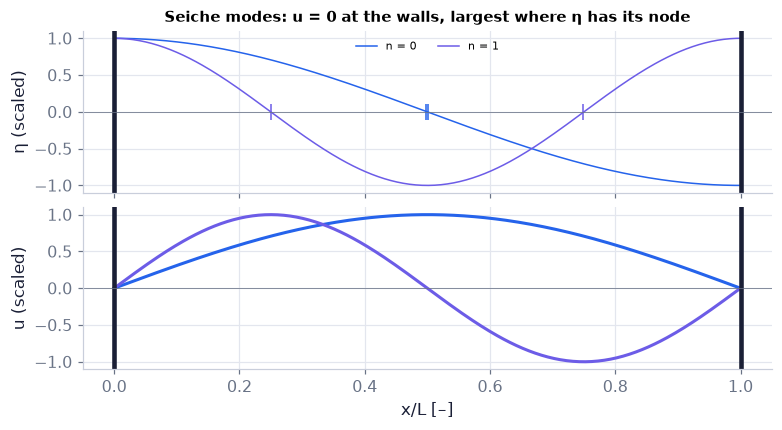

```python
L, H = 1.0, 0.1                                            # a unit basin [m]
x = np.linspace(0, L, 300)                                 # positions [m]
fig, axs = plt.subplots(2, 1, figsize=(7, 3.8), sharex=True)   # η above, u below
for n, cl in ((0, COLORS["blue"]), (1, COLORS["accent"])):  # the two gravest modes
    k = (n + 1)*np.pi/L                                    # (7.64)
    axs[0].plot(x, np.cos(k*x), color=cl, lw=1, label=f"n = {n}")          # η ∝ cos kx (at ωt = 0)
    axs[1].plot(x, np.sin(k*x), color=cl, lw=2, label=f"n = {n}")          # u ∝ sin kx (at ωt = π/2), (7.63)
    for xn in x[np.abs(np.cos(k*x)) < 0.012]:              # nodes of η
        axs[0].plot(xn, 0, "|", color=cl, ms=10)
for axp in axs:
    axp.axvline(0, color=COLORS["ink"], lw=3); axp.axvline(L, color=COLORS["ink"], lw=3); axp.axhline(0, color=COLORS["muted"], lw=0.5)
axs[0].set_ylabel("η (scaled)"); axs[1].set_ylabel("u (scaled)"); axs[1].set_xlabel("x/L [–]"); axs[0].legend(fontsize=7, ncol=2)
axs[0].set_title("Seiche modes: u = 0 at the walls, largest where η has its node", fontsize=10)
savefig(fig, "ch07", "c08_seiche_modes"); plt.show()
```

**What you see.** Top, the surface shapes of modes n = 0 and 1 with their nodes marked; bottom, the horizontal velocity: zero at both walls, one bulge for n = 0, two opposite bulges for n = 1 (our remake of Fig. 7.12 `N178`).

**How to read it.** Where u is largest η has its node: water rushes through the node from one side of the basin to the other.

**What would change if…** …n = 2: three bulges of u and λ = 2L/3; in a shallow lake the period shortens to a third of the gravest.

```python
xb = np.linspace(0, 1, 200)                                # a unit basin, x/L [–]
fig = slider_figure(lambda n: {"η (7.64)": (xb, np.cos((n + 1)*np.pi*xb)),        # surface shape of mode n
                               "u (7.63)": (xb, np.sin((n + 1)*np.pi*xb))},       # velocity shape of mode n
                    "n", range(6), xlabel="x/L [–]", ylabel="shape [–]", title="Seiche mode n: kL = (n + 1)π",   # slider over the mode number n = 0…5
                    yrange=(-1.1, 1.1))   # fixed vertical range
recolor(fig, {"η (7.64)": COLORS["blue"], "u (7.63)": COLORS["accent"]})   # surface blue, velocity purple
fig.show()   # draw (works on the page: no kernel needed)
```

[interactive chart not shown]

**What you see.** Step n from 0 to 5: the surface always has antinodes at the walls, the velocity always vanishes there, and one more half wavelength fits each time.

**What would change if…** one end of the basin were open to the sea (a bay): the open end would be a node of η instead of an antinode, and a quarter wavelength (not a half) would fit in the longest mode.

```python
k, H, a = 1.0, 1.0, 0.12                                    # kH = 1, amplitude 12 cm (exaggerated) [rad/m, m, m]
L = 2*np.pi                                                 # basin length for mode n = 1: λ = L [m]
w = ch07.omega_gravity(k, H)                                # ω [rad/s]
ng = 121 if not FAST else 81                                # contour grid size
xg, zg = np.linspace(0, L, ng), np.linspace(-H, 0, ng//2)   # grid [m]
XX, ZZ = np.meshgrid(xg, zg)
fig, ax = plt.subplots(figsize=(7, 3.2))
ax.axvline(0, color=COLORS["ink"], lw=3); ax.axvline(L, color=COLORS["ink"], lw=3)   # the walls
(ghost_r,) = ax.plot(xg, 0*xg, color=COLORS["orange"], lw=1, alpha=0.5)   # right-going component (ghost)
(ghost_l,) = ax.plot(xg, 0*xg, color=COLORS["orange"], lw=1, alpha=0.5, ls="--")   # left-going component
(surf,) = ax.plot(xg, 0*xg, color=COLORS["blue"], lw=2)    # their sum: the standing wave
ax.set_xlim(0, L); ax.set_ylim(-H, 0.3); ax.set_xlabel("x [m]"); ax.set_ylabel("z [m]")
held = []                                                   # the current streamline set (redrawn every frame)
nf = 40 if not FAST else 20                                 # frames over one period


def update(i):   # draw frame i
    t = i/nf*2*np.pi/w                                      # time [s]
    ghost_r.set_ydata(a*np.cos(k*xg - w*t)); ghost_l.set_ydata(a*np.cos(k*xg + w*t))   # (7.2) and (7.61)
    surf.set_ydata(ch07.standing_wave_fields(xg, 0.0, t, a, k, H)["eta"])             # 2a cos kx cos ωt
    for c_ in held:                                          # remove last frame's streamlines
        c_.remove()
    held.clear()
    psi = ch07.standing_wave_fields(XX, ZZ, t, a, k, H)["psi"]   # (7.62)
    if np.abs(psi).max() > 1e-6:                              # skip the instants with no flow
        held.append(ax.contour(XX, ZZ, psi, levels=np.linspace(-0.6, 0.6, 13), colors=[COLORS["teal"]], linewidths=0.8))
    ax.set_title(f"standing wave in a basin, ωt = {w*t:.2f} rad", fontsize=10)
    return []   # nothing to blit


show_animation(animate(update, frames=nf, fig=fig, interval=70))
```

[video not shown]

**What you see.** The two travelling components (orange ghosts) slide through each other; their sum (blue) never moves sideways; the streamlines (teal) reverse every half period — the `A3` animation.

**How to read it.** The walls stand where u = 0 at every instant; the water sloshes from under one crest to the other side, passing through the node in the middle.

**What would change if…** …one ghost were removed: the blue curve would travel — a single progressive wave cannot live in a closed basin.

#### 🎮 Interactive: Which waves can live in a lake?

**Why interactive rather than a static figure:** Toggle the two travelling waves and watch their sum pin its nodes; then change the basin and the mode and compare the period with real basins in the table.

**What to try:**

- Switch off the left-going wave: the pattern starts to travel.
- Choose the 50 km lake and step n from 0 to 3: the period drops as 1/(n + 1).
- Drag H up in the bathtub until the shallow estimate fails by 10 %.

```python
show_viz("ch07", "seiche_standing_waves")   # full-width explainer; ⤢ Full screen for more room
```

🎮 Interactive 3/9 Which waves can live in a lake? Open alone ↗

[interactive chart not shown]

**What would change if…** …the basin were a bay open to the sea? Its open end becomes a node of η, so the longest wave is 4L (a quarter wave) — the harbour-resonance rule; tides in long gulfs resonate this way (Ch. 13).